# An Introduction to Generalised Linear Models (4th edition)

2023-10-13

## Chapter2 Model Fitting

```r
library(dobson)
library(ggprism)
library(tidyverse)
birthweight
```

```
## # A tibble: 12 × 4
##    `boys gestational age` `boys weight` `girls gestational age` `girls weight`
##                     <dbl>         <dbl>                   <dbl>          <dbl>
##  1                     40          2968                      40           3317
##  2                     38          2795                      36           2729
##  3                     40          3163                      40           2935
##  4                     35          2925                      38           2754
##  5                     36          2625                      42           3210
##  6                     37          2847                      39           2817
##  7                     41          3292                      40           3126
##  8                     40          3473                      37           2539
##  9                     37          2628                      36           2412
## 10                     38          3176                      38           2991
## 11                     40          3421                      39           2875
## 12                     38          2975                      40           3231
```

```r
dim(birthweight)
```

```
## [1] 12  4
```

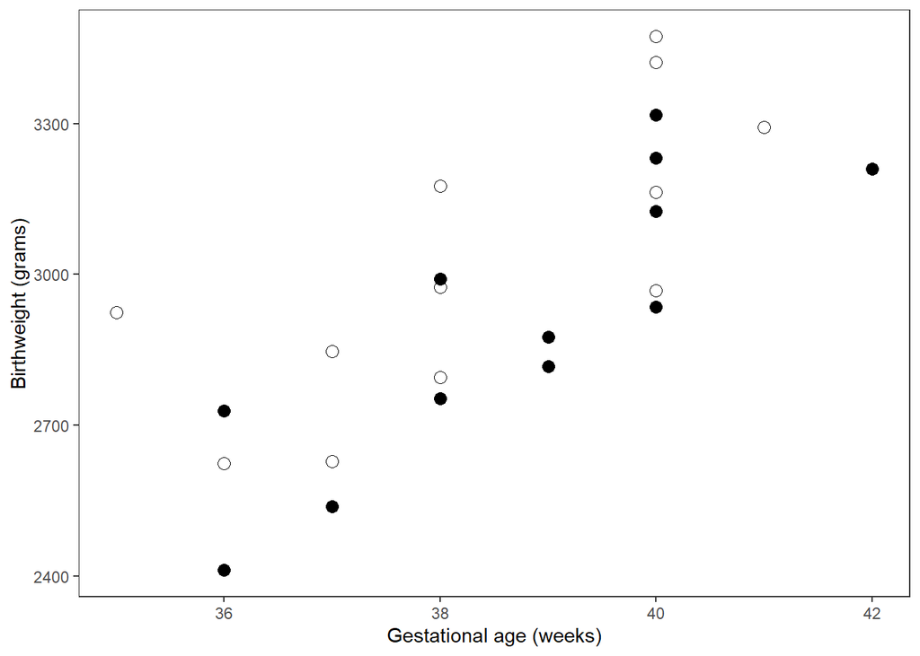

```r
library(tidyverse)
birthweight |> ggplot(aes(x=`boys gestational age`,
                          y=`boys weight`)) + geom_point(shape=1, size=3) +
  geom_point(aes(x=`girls gestational age`, y=`girls weight`), shape=19, size=3) +
  theme_bw() + theme(
  # Hide panel borders and remove grid lines
  #panel.border = element_line(colour = "black"),
  panel.grid.major = element_blank(),
  panel.grid.minor = element_blank(),
  # Change axis line
  #axis.line = element_line(colour = "black")
) + xlab("Gestational age (weeks)") +
  ylab("Birthweight (grams)")
```

```r
birthweight |> summarise(boys_sum_x=sum(`boys gestational age`),
                         boys_sum_y=sum(`boys weight`),
                         boys_sum_x2=sum((`boys gestational age`)^2),
                         boys_sum_y2=sum((`boys weight`)^2),
                         boys_sum_xy=sum((`boys gestational age`)*(`boys weight`)),
                         girls_sum_x=sum(`girls gestational age`),
                         girls_sum_y=sum(`girls weight`),
                         girls_sum_x2=sum((`girls gestational age`)^2),
                         girls_sum_y2=sum((`girls weight`)^2),
                         girls_sum_xy=sum((`girls gestational age`)*(`girls weight`))) |>
  pivot_longer(
    cols = starts_with(c("boys", "girls")),
    names_to = "items",
    values_to = "values",
    values_drop_na = TRUE
  )
```

```
## # A tibble: 10 × 2
##    items           values
##    <chr>            <dbl>
##  1 boys_sum_x         460
##  2 boys_sum_y       36288
##  3 boys_sum_x2      17672
##  4 boys_sum_y2  110623496
##  5 boys_sum_xy    1395370
##  6 girls_sum_x        465
##  7 girls_sum_y      34936
##  8 girls_sum_x2     18055
##  9 girls_sum_y2 102575468
## 10 girls_sum_xy   1358497
```

```r
birthweight_summary <- birthweight |> summarise(boys_sum_x=sum(`boys gestational age`),
                         boys_sum_y=sum(`boys weight`),
                         boys_sum_x2=sum((`boys gestational age`)^2),
                         boys_sum_y2=sum((`boys weight`)^2),
                         boys_sum_xy=sum((`boys gestational age`)*(`boys weight`)),
                         girls_sum_x=sum(`girls gestational age`),
                         girls_sum_y=sum(`girls weight`),
                         girls_sum_x2=sum((`girls gestational age`)^2),
                         girls_sum_y2=sum((`girls weight`)^2),
                         girls_sum_xy=sum((`girls gestational age`)*(`girls weight`)))
birthweight_summary
```

```
## # A tibble: 1 × 10
##   boys_sum_x boys_sum_y boys_sum_x2 boys_sum_y2 boys_sum_xy girls_sum_x
##        <dbl>      <dbl>       <dbl>       <dbl>       <dbl>       <dbl>
## 1        460      36288       17672   110623496     1395370         465
## # ℹ 4 more variables: girls_sum_y <dbl>, girls_sum_x2 <dbl>,
## #   girls_sum_y2 <dbl>, girls_sum_xy <dbl>
```

```r
#Table2.5
K=dim(birthweight)[1]
birthweight_summary |> summarise(b=(K*sum(boys_sum_xy,girls_sum_xy)-(sum(boys_sum_x*boys_sum_y, girls_sum_x*girls_sum_y)))/(K*sum(boys_sum_x2, girls_sum_x2)-(sum(boys_sum_x^2, girls_sum_x^2))),
                                 a1=boys_sum_y/K-b*boys_sum_x/K,
                                 a2=girls_sum_y/K-b*girls_sum_x/K,
                                 b1=(K*boys_sum_xy-boys_sum_x*boys_sum_y)/(K*boys_sum_x2-boys_sum_x^2),
                                 b2=(K*girls_sum_xy-girls_sum_x*girls_sum_y)/(K*girls_sum_x2-girls_sum_x^2),
                                 a11=boys_sum_y/K-b1*boys_sum_x/K,
                                 a22=girls_sum_y/K-b2*girls_sum_x/K,
                                 S0=sum((birthweight$`boys weight`-a1-b*birthweight$`boys gestational age`)^2,
                                        (birthweight$`girls weight`-a2-b*birthweight$`girls gestational age`)^2),
                                 S1=sum((birthweight$`boys weight`-a11-b1*birthweight$`boys gestational age`)^2,
                                        (birthweight$`girls weight`-a22-b2*birthweight$`girls gestational age`)^2),
                                Fstatistic=((S0-S1)/(2-1))/(S1/(24-4)),
                                p_value=pf(Fstatistic, df1=1, df2=20)
                                  ) |>
  as.data.frame()
```

```
##          b        a1        a2       b1    b2       a11       a22       S0
## 1 120.8943 -1610.283 -1773.322 111.9828 130.4 -1268.672 -2141.667 658770.7
##         S1 Fstatistic   p_value
## 1 652424.5  0.1945428 0.3361066
```

### 2.5 Exercises

#### 2.5.1

```r
plants
```

```
## # A tibble: 20 × 2
##    treatment control
##        <dbl>   <dbl>
##  1      4.81    4.17
##  2      4.17    3.05
##  3      4.41    5.18
##  4      3.59    4.01
##  5      5.87    6.11
##  6      3.83    4.1
##  7      6.03    5.17
##  8      4.98    3.57
##  9      4.9     5.33
## 10      5.75    5.59
## 11      5.36    4.66
## 12      3.48    5.58
## 13      4.69    3.66
## 14      4.44    4.5
## 15      4.89    3.9
## 16      4.71    4.61
## 17      5.48    5.62
## 18      4.32    4.53
## 19      5.15    6.05
## 20      6.34    5.14
```

Perform an unpaired t-test on these data and calculate a 95% confidence interval for the difference between the group means. Interpret these results.

```r
#unpaired t-test
t1 <- t.test(plants$treatment, plants$control, var.equal = TRUE, data=plants)
t1
```

```
##
##  Two Sample t-test
##
## data:  plants$treatment and plants$control
## t = 0.50985, df = 38, p-value = 0.6131
## alternative hypothesis: true difference in means is not equal to 0
## 95 percent confidence interval:
##  -0.3965733  0.6635733
## sample estimates:
## mean of x mean of y
##    4.8600    4.7265
```

```r
t1$conf.int
```

```
## [1] -0.3965733  0.6635733
## attr(,"conf.level")
## [1] 0.95
```

```r
#t
sp <- sqrt((19*var(plants$treatment)+19*var(plants$control))/38)
(mean(plants$treatment)-mean(plants$control))/(sp*sqrt(2/20))
```

```
## [1] 0.5098476
```

```r
#p-value
2*(1-pt(0.5098476, df=38))
```

```
## [1] 0.6131068
```

```r
mean(plants$treatment)
```

```
## [1] 4.86
```

```r
mean(plants$control)
```

```
## [1] 4.7265
```

```r
sum(plants$treatment+plants$control)/40
```

```
## [1] 4.79325
```

```r
mean(c(plants$treatment, plants$control))
```

```
## [1] 4.79325
```

```r
c(plants$treatment, plants$control)
```

```
##  [1] 4.81 4.17 4.41 3.59 5.87 3.83 6.03 4.98 4.90 5.75 5.36 3.48 4.69 4.44 4.89
## [16] 4.71 5.48 4.32 5.15 6.34 4.17 3.05 5.18 4.01 6.11 4.10 5.17 3.57 5.33 5.59
## [31] 4.66 5.58 3.66 4.50 3.90 4.61 5.62 4.53 6.05 5.14
```

```r
#S1 and S0
S1 <- sum((plants$treatment-mean(plants$treatment))^2) + sum((plants$control-mean(plants$control))^2)
S0 <- sum((c(plants$treatment, plants$control)-mean(c(plants$treatment, plants$control)))^2)
S1
```

```
## [1] 26.05345
```

```r
S0
```

```
## [1] 26.23168
```

```r
#F(1,38)
(S0-S1)/(S1/38)
```

```
## [1] 0.2599446
```

```r
t <- (mean(plants$treatment)-mean(plants$control))/(sp*sqrt(2/20))
t^2
```

```
## [1] 0.2599446
```

#### 2.5.2

The weights, in kilograms, of twenty men before and after participation in a “waist loss” program are shown in Table 2.8 (Egger et al. 1999). We want to know if, on average, they retain a weight loss twelve months after the program.

```r
waist
```

```
## # A tibble: 20 × 3
##      man before after
##    <dbl>  <dbl> <dbl>
##  1     1   101.  97
##  2     2   102  108.
##  3     3   106.  97
##  4     4   108  108
##  5     5    92   84
##  6     6   117. 112.
##  7     7   110. 102.
##  8     8   135  128.
##  9     9   124. 118.
## 10    10    95   94.2
## 11    11   105  105
## 12    12    85   82.4
## 13    13   107.  98.2
## 14    14    80   83.6
## 15    15   115. 115
## 16    16   104. 103
## 17    17    82   80
## 18    18   102. 102.
## 19    19   104. 103.
## 20    20    93   93
```

```r
#unpaired t-test
t1 <- t.test(waist$before, waist$after, var.equal = TRUE, data=waist)
t1
```

```
##
##  Two Sample t-test
##
## data:  waist$before and waist$after
## t = 0.64309, df = 38, p-value = 0.524
## alternative hypothesis: true difference in means is not equal to 0
## 95 percent confidence interval:
##  -5.68128 10.97128
## sample estimates:
## mean of x mean of y
##   103.245   100.600
```

```r
#Dk
Dk <- waist$before - waist$after
EDk <- mean(Dk)
EDk
```

```
## [1] 2.645
```

```r
#H0 is EDk = 0 and Dk ~ N(0, \sigma^2); H1 is EDk != 0 and Dk ~ N(EDk, \sigma^2)

S0 <- sum(Dk^2)
S1 <- sum((Dk-EDk)^2)
```

```r
#F(1,19)
(S0-S1)/(S1/19)
```

```
## [1] 8.256448
```

```r
Fstatistic <- (S0-S1)/(S1/19)
1-pf(Fstatistic, df1=1, df2=19)
```

```
## [1] 0.009730463
```

```r
#paired t-test
t2 <- t.test(waist$before, waist$after, paired = TRUE, var.equal = TRUE, data=waist)
t2
```

```
##
##  Paired t-test
##
## data:  waist$before and waist$after
## t = 2.8734, df = 19, p-value = 0.00973
## alternative hypothesis: true mean difference is not equal to 0
## 95 percent confidence interval:
##  0.718348 4.571652
## sample estimates:
## mean difference
##           2.645
```

```r
(t2$statistic)^2
```

```
##        t
## 8.256448
```

## Chapter3 Exponential Family and Generalized Linear Models

### Exercises

#### 3.6

```r
mortality
```

```
## # A tibble: 8 × 3
##   `age group` deaths population
##   <chr>        <dbl>      <dbl>
## 1 30-34            1      17742
## 2 35-39            5      16554
## 3 40-44            5      16059
## 4 45-49           12      13083
## 5 50-54           25      10784
## 6 55-59           38       9645
## 7 60-64           54      10706
## 8 65-69           65       9933
```

```r
library(dplyr)
mortality2 <- mortality %>%
    mutate(
        age=as.integer(stringr::str_split(as.character(`age group`), "-") %>% purrr::map_chr(., 1)),
        death_rate = deaths*100000 / population,
        log_age=log(age),
        log_deaths=log(death_rate)
    )
mortality2
```

```
## # A tibble: 8 × 7
##   `age group` deaths population   age death_rate log_age log_deaths
##   <chr>        <dbl>      <dbl> <int>      <dbl>   <dbl>      <dbl>
## 1 30-34            1      17742    30       5.64    3.40       1.73
## 2 35-39            5      16554    35      30.2     3.56       3.41
## 3 40-44            5      16059    40      31.1     3.69       3.44
## 4 45-49           12      13083    45      91.7     3.81       4.52
## 5 50-54           25      10784    50     232.      3.91       5.45
## 6 55-59           38       9645    55     394.      4.01       5.98
## 7 60-64           54      10706    60     504.      4.09       6.22
## 8 65-69           65       9933    65     654.      4.17       6.48
```

```r
lmodel <- lm(log_deaths ~ log_age, data = mortality2)
lmodel
```

```
##
## Call:
## lm(formula = log_deaths ~ log_age, data = mortality2)
##
## Coefficients:
## (Intercept)      log_age
##     -18.909        6.152
```

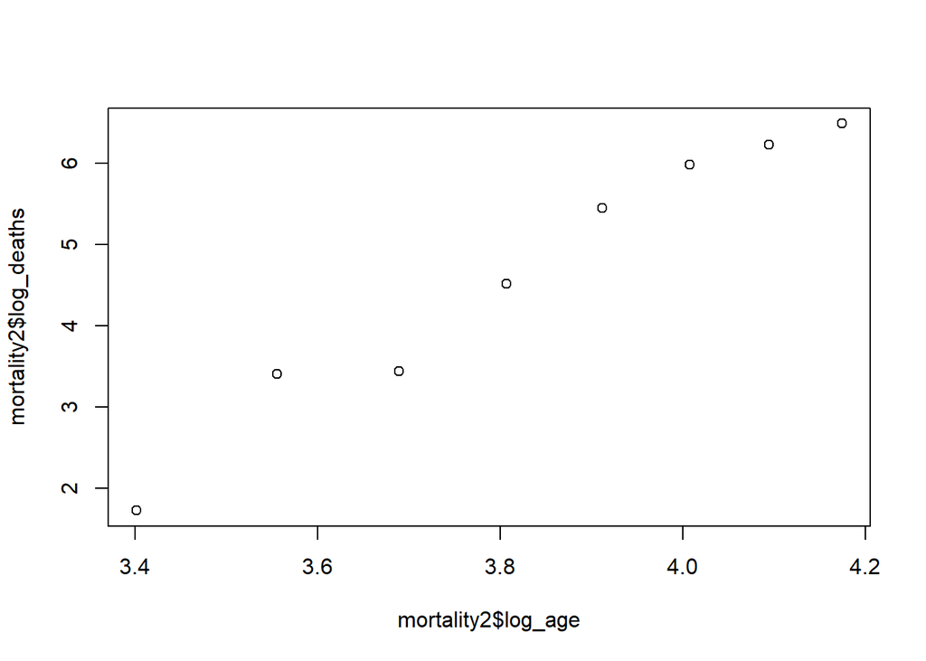

```r
plot(mortality2$log_age, mortality2$log_deaths)
```

```r
summary(lmodel)
```

```
##
## Call:
## lm(formula = log_deaths ~ log_age, data = mortality2)
##
## Residuals:
##      Min       1Q   Median       3Q      Max
## -0.34631 -0.28614 -0.02311  0.24654  0.44482
##
## Coefficients:
##             Estimate Std. Error t value Pr(>|t|)
## (Intercept) -18.9094     1.7376  -10.88 3.57e-05 ***
## log_age       6.1520     0.4527   13.59 9.85e-06 ***
## ---
## Signif. codes:  0 '***' 0.001 '**' 0.01 '*' 0.05 '.' 0.1 ' ' 1
##
## Residual standard error: 0.3222 on 6 degrees of freedom
## Multiple R-squared:  0.9685, Adjusted R-squared:  0.9633
## F-statistic: 184.7 on 1 and 6 DF,  p-value: 9.854e-06
```

```r
exp(lmodel$fitted.values)*mortality2$population/100000
```

```
##         1         2         3         4         5         6         7         8
##  1.330546  3.204702  7.069199 11.886386 18.733671 30.115732 57.094466 86.677030
```

```r
mortality2$deaths
```

```
## [1]  1  5  5 12 25 38 54 65
```

```r
data(poisson)
poisson
```

```
## # A tibble: 9 × 2
##       y     x
##   <dbl> <dbl>
## 1     2    -1
## 2     3    -1
## 3     6     0
## 4     7     0
## 5     8     0
## 6     9     0
## 7    10     1
## 8    12     1
## 9    15     1
```

```r
res.p=glm(y~x,family=poisson(link="identity"),data=poisson)
summary(res.p)
```

```
##
## Call:
## glm(formula = y ~ x, family = poisson(link = "identity"), data = poisson)
##
## Coefficients:
##             Estimate Std. Error z value Pr(>|z|)
## (Intercept)   7.4516     0.8841   8.428  < 2e-16 ***
## x             4.9353     1.0892   4.531 5.86e-06 ***
## ---
## Signif. codes:  0 '***' 0.001 '**' 0.01 '*' 0.05 '.' 0.1 ' ' 1
##
## (Dispersion parameter for poisson family taken to be 1)
##
##     Null deviance: 18.4206  on 8  degrees of freedom
## Residual deviance:  1.8947  on 7  degrees of freedom
## AIC: 40.008
##
## Number of Fisher Scoring iterations: 3
```

## Chapter4 Estimation

```r
#table 4.1
data(failure)
failure
```

```
## # A tibble: 49 × 1
##    lifetimes
##        <dbl>
##  1      1051
##  2      1337
##  3      1389
##  4      1921
##  5      1942
##  6      2322
##  7      3629
##  8      4006
##  9      4012
## 10      4063
## 11      4921
## 12      5445
## 13      5620
## 14      5817
## 15      5905
## 16      5956
## 17      6068
## 18      6121
## 19      6473
## 20      7501
## 21      7886
## 22      8108
## 23      8546
## 24      8666
## 25      8831
## # ℹ 24 more rows
```

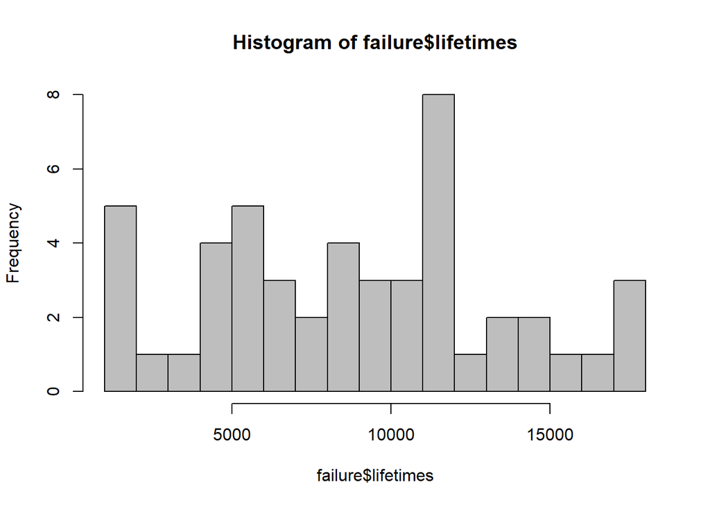

```r
hist(failure$lifetimes,freq=T,col="grey",breaks=12)
```

```r
library(tidyverse)
length(failure$lifetimes)
```

```
## [1] 49
```

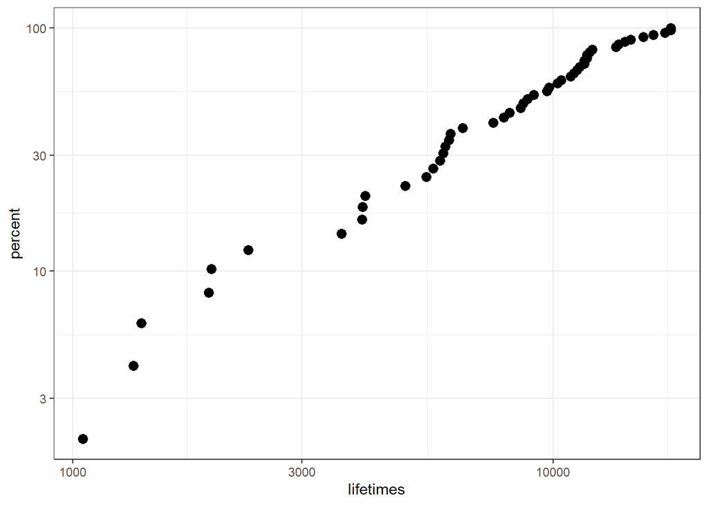

```r
failure$percent <- order(failure$lifetimes)*100/length(failure$lifetimes)
failure |> ggplot(aes(x=lifetimes, y=percent)) + geom_point(size=3) +
  scale_x_log10() + scale_y_log10() + theme_bw()
```

```r
weibull <- tibble(
  x=seq(1000, 20000, by=1),
  data = dweibull(seq(1000, 20000, by=1),shape=3))
weibull$percent <- order(weibull$data)*100/length(weibull$data)
head(weibull)
```

```
## # A tibble: 6 × 3
##       x  data percent
##   <dbl> <dbl>   <dbl>
## 1  1000     0 0.00526
## 2  1001     0 0.0105
## 3  1002     0 0.0158
## 4  1003     0 0.0211
## 5  1004     0 0.0263
## 6  1005     0 0.0316
```

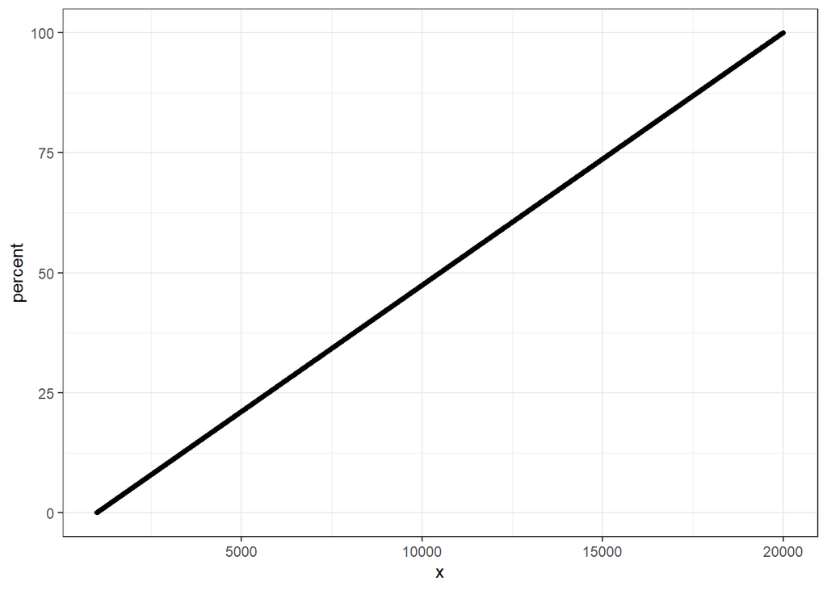

```r
weibull |> ggplot(aes(x=x, y=percent)) + geom_point(size=1) + theme_bw()
```

```r
y <- failure$lifetimes
N <- length(failure$lifetimes)
shape <- 2
forU <- function(theta){
  1e6*(-(shape*N)/(theta)+(shape*sum(y^2))/(theta^3))
}
forUprime <- function(theta){
  1e6*((shape*N)/(theta^2)-(shape*3*sum(y^2))/(theta^4))
}
forEUprime <- function(theta){
  1e6*(-(shape^2*N)/(theta^2))
}
nextTheta <- function(theta, U, Up){
  theta - U/Up
}
```

```r
theta1 <- mean(failure$lifetimes)
U10e6_1 <- forU(theta1)
Uprime10e6_1 <- forUprime(theta1)
EUprime10e6_1 <- forEUprime(theta1)
newTheta <- nextTheta(theta1, U10e6_1/1e6, Uprime10e6_1/1e6)
theta1
```

```
## [1] 8805.694
```

```r
U10e6_1
```

```
## [1] 2915.751
```

```r
Uprime10e6_1
```

```
## [1] -3.521083
```

```r
EUprime10e6_1
```

```
## [1] -2.52772
```

```r
U10e6_1/Uprime10e6_1
```

```
## [1] -828.0835
```

```r
U10e6_1/EUprime10e6_1
```

```
## [1] -1153.51
```

```r
newTheta
```

```
## [1] 9633.777
```

```r
library(tidyverse)
tibble("theta" = theta1,
       "U10e6" = U10e6_1,
       "Uprime10e6" = Uprime10e6_1,
       "EUprime10e6" = EUprime10e6_1,
       "U/Uprime" = U10e6_1/Uprime10e6_1,
       "U/EUprime" = U10e6_1/EUprime10e6_1
       ) %>%
  add_row("theta" = nextTheta(last(.$theta), last(.$U10e6)/1e6, last(.$Uprime10e6)/1e6),
          "U10e6" = forU(theta),
       "Uprime10e6" = forUprime(theta),
       "EUprime10e6" = forEUprime(theta),
       "U/Uprime" = U10e6/Uprime10e6,
       "U/EUprime" = U10e6/EUprime10e6
       ) %>%
  add_row("theta" = nextTheta(last(.$theta), last(.$U10e6)/1e6, last(.$Uprime10e6)/1e6),
          "U10e6" = forU(theta),
       "Uprime10e6" = forUprime(theta),
       "EUprime10e6" = forEUprime(theta),
       "U/Uprime" = U10e6/Uprime10e6,
       "U/EUprime" = U10e6/EUprime10e6
       ) %>%
  add_row("theta" = nextTheta(last(.$theta), last(.$U10e6)/1e6, last(.$Uprime10e6)/1e6),
          "U10e6" = forU(theta),
       "Uprime10e6" = forUprime(theta),
       "EUprime10e6" = forEUprime(theta),
       "U/Uprime" = U10e6/Uprime10e6,
       "U/EUprime" = U10e6/EUprime10e6
       ) %>%
  add_row("theta" = nextTheta(last(.$theta), last(.$U10e6)/1e6, last(.$Uprime10e6)/1e6),
          "U10e6" = forU(theta),
       "Uprime10e6" = forUprime(theta),
       "EUprime10e6" = forEUprime(theta),
       "U/Uprime" = U10e6/Uprime10e6,
       "U/EUprime" = U10e6/EUprime10e6
       )
```

```
## # A tibble: 5 × 6
##   theta         U10e6 Uprime10e6 EUprime10e6    `U/Uprime` `U/EUprime`
##   <dbl>         <dbl>      <dbl>       <dbl>         <dbl>       <dbl>
## 1 8806. 2916.              -3.52       -2.53 -828.            -1.15e+3
## 2 9634.  553.              -2.28       -2.11 -242.            -2.62e+2
## 3 9876.   32.7             -2.02       -2.01  -16.2           -1.63e+1
## 4 9892.    0.134           -2.00       -2.00   -0.0668        -6.68e-2
## 5 9892.    0.00000226      -2.00       -2.00   -0.00000113    -1.13e-6
```

```r
library(dobson)
data(poisson)
poisson
```

```
## # A tibble: 9 × 2
##       y     x
##   <dbl> <dbl>
## 1     2    -1
## 2     3    -1
## 3     6     0
## 4     7     0
## 5     8     0
## 6     9     0
## 7    10     1
## 8    12     1
## 9    15     1
```

```r
res.p=glm(y~x,family=poisson(link="identity"),data=poisson)
summary(res.p)
```

```
##
## Call:
## glm(formula = y ~ x, family = poisson(link = "identity"), data = poisson)
##
## Coefficients:
##             Estimate Std. Error z value Pr(>|z|)
## (Intercept)   7.4516     0.8841   8.428  < 2e-16 ***
## x             4.9353     1.0892   4.531 5.86e-06 ***
## ---
## Signif. codes:  0 '***' 0.001 '**' 0.01 '*' 0.05 '.' 0.1 ' ' 1
##
## (Dispersion parameter for poisson family taken to be 1)
##
##     Null deviance: 18.4206  on 8  degrees of freedom
## Residual deviance:  1.8947  on 7  degrees of freedom
## AIC: 40.008
##
## Number of Fisher Scoring iterations: 3
```

```r
aids
```

```
## # A tibble: 20 × 3
##     year quarter cases
##    <dbl>   <dbl> <dbl>
##  1  1984       1     1
##  2  1984       2     6
##  3  1984       3    16
##  4  1984       4    23
##  5  1985       1    27
##  6  1985       2    39
##  7  1985       3    31
##  8  1985       4    30
##  9  1986       1    43
## 10  1986       2    51
## 11  1986       3    63
## 12  1986       4    70
## 13  1987       1    88
## 14  1987       2    97
## 15  1987       3    91
## 16  1987       4   104
## 17  1988       1   110
## 18  1988       2   113
## 19  1988       3   149
## 20  1988       4   159
```

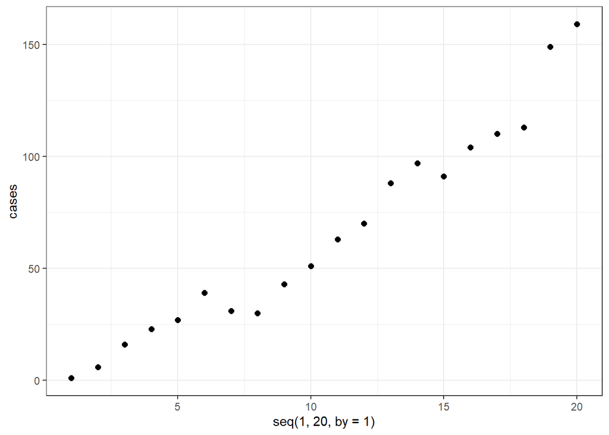

```r
aids |> ggplot(aes(x=seq(1,20, by=1),
                   y=cases)) + geom_point(size=2) + theme_bw()
```

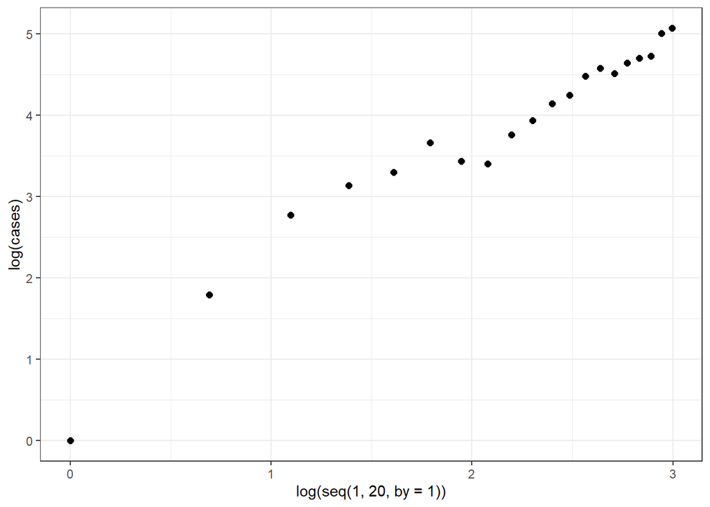

```r
ggplot(aes(x=log(seq(1,20, by=1)),
           y=log(cases)),
           data=aids) + geom_point(size=2) + theme_bw()
```

```r
aids$logx <- log(seq(1,20, by=1))
res.p=glm(cases~logx,family=poisson(link="log"),data=aids)
summary(res.p)
```

```
##
## Call:
## glm(formula = cases ~ logx, family = poisson(link = "log"), data = aids)
##
## Coefficients:
##             Estimate Std. Error z value Pr(>|z|)
## (Intercept)  0.99600    0.16971   5.869 4.39e-09 ***
## logx         1.32661    0.06463  20.525  < 2e-16 ***
## ---
## Signif. codes:  0 '***' 0.001 '**' 0.01 '*' 0.05 '.' 0.1 ' ' 1
##
## (Dispersion parameter for poisson family taken to be 1)
##
##     Null deviance: 677.264  on 19  degrees of freedom
## Residual deviance:  21.755  on 18  degrees of freedom
## AIC: 138.05
##
## Number of Fisher Scoring iterations: 4
```

```r
beta1 = 1
beta2 = 1
beta = matrix(c(beta1, beta2))
beta
```

```
##      [,1]
## [1,]    1
## [2,]    1
```

```r
X = matrix(c(rep(1,20), aids$logx),
           ncol = 2,
           byrow = FALSE)
X
```

```
##       [,1]      [,2]
##  [1,]    1 0.0000000
##  [2,]    1 0.6931472
##  [3,]    1 1.0986123
##  [4,]    1 1.3862944
##  [5,]    1 1.6094379
##  [6,]    1 1.7917595
##  [7,]    1 1.9459101
##  [8,]    1 2.0794415
##  [9,]    1 2.1972246
## [10,]    1 2.3025851
## [11,]    1 2.3978953
## [12,]    1 2.4849066
## [13,]    1 2.5649494
## [14,]    1 2.6390573
## [15,]    1 2.7080502
## [16,]    1 2.7725887
## [17,]    1 2.8332133
## [18,]    1 2.8903718
## [19,]    1 2.9444390
## [20,]    1 2.9957323
```

```r
library(matlib)
Y=aids$cases
W = as.vector(exp(X %*% beta))
XWX = t(X) %*% diag(W) %*% X
XWX
```

```
##           [,1]     [,2]
## [1,]  570.8392 1439.608
## [2,] 1439.6080 3768.835
```

```r
Z = X %*% beta + Y/exp(X %*% beta) - 1
XWz = t(X) %*% diag(W) %*% Z
XWz
```

```
##          [,1]
## [1,] 2750.608
## [2,] 7165.214
```

```r
beta = inv(XWX) %*% XWz
beta
```

```
##          [,1]
## [1,] 0.652354
## [2,] 1.651976
```

```r
W = as.vector(exp(X %*% beta))
XWX = t(X) %*% diag(W) %*% X
XWX
```

```
##          [,1]      [,2]
## [1,] 2179.160  5759.537
## [2,] 5759.537 15530.924
```

```r
Z = X %*% beta + Y/exp(X %*% beta) - 1
XWz = t(X) %*% diag(W) %*% Z
XWz
```

```
##          [,1]
## [1,] 10068.04
## [2,] 27050.81
```

```r
beta = inv(XWX) %*% XWz
beta
```

```
##           [,1]
## [1,] 0.8418285
## [2,] 1.4296516
```

```r
W = as.vector(exp(X %*% beta))
XWX = t(X) %*% diag(W) %*% X
XWX
```

```
##          [,1]      [,2]
## [1,] 1468.897  3831.947
## [2,] 3831.947 10243.200
```

```r
Z = X %*% beta + Y/exp(X %*% beta) - 1
XWz = t(X) %*% diag(W) %*% Z
XWz
```

```
##           [,1]
## [1,]  6557.012
## [2,] 17434.482
```

```r
beta = inv(XWX) %*% XWz
beta
```

```
##          [,1]
## [1,] 0.984507
## [2,] 1.333712
```

```r
W = as.vector(exp(X %*% beta))
XWX = t(X) %*% diag(W) %*% X
XWX
```

```
##          [,1]     [,2]
## [1,] 1320.094 3421.644
## [2,] 3421.644 9108.435
```

```r
Z = X %*% beta + Y/exp(X %*% beta) - 1
XWz = t(X) %*% diag(W) %*% Z
XWz
```

```
##           [,1]
## [1,]  5854.034
## [2,] 15491.392
```

```r
beta = inv(XWX) %*% XWz
beta
```

```
##           [,1]
## [1,] 0.9959001
## [2,] 1.3266773
```

```r
W = as.vector(exp(X %*% beta))
XWX = t(X) %*% diag(W) %*% X
XWX
```

```
##          [,1]     [,2]
## [1,] 1311.101 3396.658
## [2,] 3396.658 9039.070
```

```r
Z = X %*% beta + Y/exp(X %*% beta) - 1
XWz = t(X) %*% diag(W) %*% Z
XWz
```

```
##           [,1]
## [1,]  5811.893
## [2,] 15374.382
```

```r
beta = inv(XWX) %*% XWz
beta
```

```
##           [,1]
## [1,] 0.9959791
## [2,] 1.3265970
```

```r
leukemia
```

```
## # A tibble: 17 × 2
##     time   wbc
##    <dbl> <dbl>
##  1    65  3.36
##  2   156  2.88
##  3   100  3.63
##  4   134  3.41
##  5    16  3.78
##  6   108  4.02
##  7   121  4
##  8     4  4.23
##  9    39  3.73
## 10   143  3.85
## 11    56  3.97
## 12    26  4.51
## 13    22  4.54
## 14     1  5
## 15     1  5
## 16     5  4.72
## 17    65  5
```

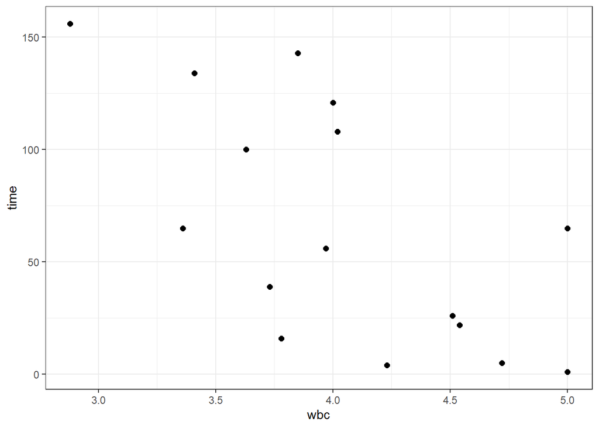

```r
leukemia |> ggplot(aes(x=wbc, y=time))+geom_point(size=2) + theme_bw()
```

```r
res.e=glm(time~wbc,family=Gamma(link="log"), data=leukemia)
summary(res.e, dispersion=1)
```

```
##
## Call:
## glm(formula = time ~ wbc, family = Gamma(link = "log"), data = leukemia)
##
## Coefficients:
##             Estimate Std. Error z value Pr(>|z|)
## (Intercept)   8.4775     1.6548   5.123 3.01e-07 ***
## wbc          -1.1093     0.3997  -2.776  0.00551 **
## ---
## Signif. codes:  0 '***' 0.001 '**' 0.01 '*' 0.05 '.' 0.1 ' ' 1
##
## (Dispersion parameter for Gamma family taken to be 1)
##
##     Null deviance: 26.282  on 16  degrees of freedom
## Residual deviance: 19.457  on 15  degrees of freedom
## AIC: 173.97
##
## Number of Fisher Scoring iterations: 8
```

```r
beta1 = 1
beta2 = 1
beta = matrix(c(beta1, beta2))
beta
```

```
##      [,1]
## [1,]    1
## [2,]    1
```

```r
X = matrix(c(rep(1,length(leukemia$wbc)), leukemia$wbc),
           ncol = 2,
           byrow = FALSE)
X
```

```
##       [,1] [,2]
##  [1,]    1 3.36
##  [2,]    1 2.88
##  [3,]    1 3.63
##  [4,]    1 3.41
##  [5,]    1 3.78
##  [6,]    1 4.02
##  [7,]    1 4.00
##  [8,]    1 4.23
##  [9,]    1 3.73
## [10,]    1 3.85
## [11,]    1 3.97
## [12,]    1 4.51
## [13,]    1 4.54
## [14,]    1 5.00
## [15,]    1 5.00
## [16,]    1 4.72
## [17,]    1 5.00
```

```r
library(matlib)
Y=leukemia$time

for (i in 1:8) {
  W = rep(1,length(leukemia$wbc))
  XWX = t(X) %*% diag(W) %*% X
  print(paste0("iter_", i))
  print(XWX)
  Z = X %*% beta + (Y-exp(X %*% beta))/exp(X %*% beta)
  XWz = t(X) %*% diag(W) %*% Z
  print(XWz)
  beta = inv(XWX) %*% XWz
  print(beta)
  writeLines("\n")
}
```

```
## [1] "iter_1"
##       [,1]     [,2]
## [1,] 17.00  69.6300
## [2,] 69.63 291.4571
##           [,1]
## [1,]  80.19729
## [2,] 328.25994
##             [,1]
## [1,]  4.86057632
## [2,] -0.03493351
##
##
## [1] "iter_2"
##       [,1]     [,2]
## [1,] 17.00  69.6300
## [2,] 69.63 291.4571
##           [,1]
## [1,]  72.57509
## [2,] 293.84440
##            [,1]
## [1,]  6.5030112
## [2,] -0.5453974
##
##
## [1] "iter_3"
##       [,1]     [,2]
## [1,] 17.00  69.6300
## [2,] 69.63 291.4571
##           [,1]
## [1,]  68.40056
## [2,] 274.35080
##            [,1]
## [1,]  7.8244252
## [2,] -0.9279706
##
##
## [1] "iter_4"
##       [,1]     [,2]
## [1,] 17.00  69.6300
## [2,] 69.63 291.4571
```

[output cut: 39 more lines]

```
##           [,1]
## [1,]  8.477461
## [2,] -1.109288
##
##
## [1] "iter_8"
##       [,1]     [,2]
## [1,] 17.00  69.6300
## [2,] 69.63 291.4571
##           [,1]
## [1,]  66.87705
## [2,] 266.97541
##           [,1]
## [1,]  8.477495
## [2,] -1.109296
```

## Chapter5 Inference

```r
#Exercises 5.1
#critical value
qchisq(0.95,df=1)
```

```
## [1] 3.841459
```

```r
N=10
y=3
pi=c(0.1,0.3,0.5)
#information
J=N/(pi*(1-pi))
#Wald/score statistic
Wald = (y-N*pi)^2/(N*pi*(1-pi))
#Deviance
pi_hat=y/N
D=2*(y*log(pi_hat/pi)+(N-y)*log((1-pi_hat)/(1-pi)))
Wald
```

```
## [1] 4.444444 0.000000 1.600000
```

```r
D
```

```
## [1] 3.073272 0.000000 1.645658
```

```r
#Exercises 5.3(d)
N=100
theta_hat=c()
for(i in 1:20){
  N=100
  U = runif(N, min = 0, max = 1)
  theta=2
  Y=(1/U)^(1/theta)
  theta_h = N/(sum(log(Y)))
  print(theta_h)
  theta_hat=c(theta_hat, theta_h)
}
```

```
## [1] 1.821412
## [1] 2.234263
## [1] 2.088903
## [1] 2.383791
## [1] 2.192633
## [1] 1.855911
## [1] 2.214401
## [1] 2.558407
## [1] 1.690483
## [1] 1.779957
## [1] 1.850833
## [1] 2.043665
## [1] 1.819195
## [1] 2.024014
## [1] 2.077961
## [1] 1.792438
## [1] 2.307848
## [1] 2.108495
## [1] 2.081333
## [1] 1.821404
```

```r
theta_hat
```

```
##  [1] 1.821412 2.234263 2.088903 2.383791 2.192633 1.855911 2.214401 2.558407
##  [9] 1.690483 1.779957 1.850833 2.043665 1.819195 2.024014 2.077961 1.792438
## [17] 2.307848 2.108495 2.081333 1.821404
```

```r
quantile(theta_hat,  probs = c(2.5, 97.5)/100)
```

```
##     2.5%    97.5%
## 1.732983 2.475464
```

```r
library(dobson)
leukemia
```

```
## # A tibble: 17 × 2
##     time   wbc
##    <dbl> <dbl>
##  1    65  3.36
##  2   156  2.88
##  3   100  3.63
##  4   134  3.41
##  5    16  3.78
##  6   108  4.02
##  7   121  4
##  8     4  4.23
##  9    39  3.73
## 10   143  3.85
## 11    56  3.97
## 12    26  4.51
## 13    22  4.54
## 14     1  5
## 15     1  5
## 16     5  4.72
## 17    65  5
```

```r
res.e=glm(time~wbc,family=Gamma(link="log"), data=leukemia)
summary(res.e, dispersion=1)
```

```
##
## Call:
## glm(formula = time ~ wbc, family = Gamma(link = "log"), data = leukemia)
##
## Coefficients:
##             Estimate Std. Error z value Pr(>|z|)
## (Intercept)   8.4775     1.6548   5.123 3.01e-07 ***
## wbc          -1.1093     0.3997  -2.776  0.00551 **
## ---
## Signif. codes:  0 '***' 0.001 '**' 0.01 '*' 0.05 '.' 0.1 ' ' 1
##
## (Dispersion parameter for Gamma family taken to be 1)
##
##     Null deviance: 26.282  on 16  degrees of freedom
## Residual deviance: 19.457  on 15  degrees of freedom
## AIC: 173.97
##
## Number of Fisher Scoring iterations: 8
```

```r
#95% confidence interval for the parameter b1.
-1.1093+0.3997*2
```

```
## [1] -0.3099
```

```r
-1.1093-0.3997*2
```

```
## [1] -1.9087
```

```r
res.e2=glm(time~1,family=Gamma(link="log"), data=leukemia)
summary(res.e2, dispersion=1)
```

```
##
## Call:
## glm(formula = time ~ 1, family = Gamma(link = "log"), data = leukemia)
##
## Coefficients:
##             Estimate Std. Error z value Pr(>|z|)
## (Intercept)   4.1347     0.2425   17.05   <2e-16 ***
## ---
## Signif. codes:  0 '***' 0.001 '**' 0.01 '*' 0.05 '.' 0.1 ' ' 1
##
## (Dispersion parameter for Gamma family taken to be 1)
##
##     Null deviance: 26.282  on 16  degrees of freedom
## Residual deviance: 26.282  on 16  degrees of freedom
## AIC: 178.09
##
## Number of Fisher Scoring iterations: 6
```

```r
#deviance difference
res.e2$deviance - res.e$deviance
```

```
## [1] 6.825567
```

```r
diff = res.e2$deviance - res.e$deviance
#p value
(1-pchisq(diff, df=1))
```

```
## [1] 0.008986204
```

## Chapter6 Normal Linear Models

```r
carbohydrate
```

```
## # A tibble: 20 × 4
##    carbohydrate   age weight protein
##           <dbl> <dbl>  <dbl>   <dbl>
##  1           33    33    100      14
##  2           40    47     92      15
##  3           37    49    135      18
##  4           27    35    144      12
##  5           30    46    140      15
##  6           43    52    101      15
##  7           34    62     95      14
##  8           48    23    101      17
##  9           30    32     98      15
## 10           38    42    105      14
## 11           50    31    108      17
## 12           51    61     85      19
## 13           30    63    130      19
## 14           36    40    127      20
## 15           41    50    109      15
## 16           42    64    107      16
## 17           46    56    117      18
## 18           24    61    100      13
## 19           35    48    118      18
## 20           37    28    102      14
```

```r
dput(carbohydrate)
```

```
## structure(list(carbohydrate = c(33, 40, 37, 27, 30, 43, 34, 48,
## 30, 38, 50, 51, 30, 36, 41, 42, 46, 24, 35, 37), age = c(33,
## 47, 49, 35, 46, 52, 62, 23, 32, 42, 31, 61, 63, 40, 50, 64, 56,
## 61, 48, 28), weight = c(100, 92, 135, 144, 140, 101, 95, 101,
## 98, 105, 108, 85, 130, 127, 109, 107, 117, 100, 118, 102), protein = c(14,
## 15, 18, 12, 15, 15, 14, 17, 15, 14, 17, 19, 19, 20, 15, 16, 18,
## 13, 18, 14)), class = c("tbl_df", "tbl", "data.frame"), row.names = c(NA,
## -20L))
```

```r
#Model 6.7
N=dim(carbohydrate)[1]
X <- carbohydrate
X[,1] <- rep(1, N)
X
```

```
## # A tibble: 20 × 4
##    carbohydrate   age weight protein
##           <dbl> <dbl>  <dbl>   <dbl>
##  1            1    33    100      14
##  2            1    47     92      15
##  3            1    49    135      18
##  4            1    35    144      12
##  5            1    46    140      15
##  6            1    52    101      15
##  7            1    62     95      14
##  8            1    23    101      17
##  9            1    32     98      15
## 10            1    42    105      14
## 11            1    31    108      17
## 12            1    61     85      19
## 13            1    63    130      19
## 14            1    40    127      20
## 15            1    50    109      15
## 16            1    64    107      16
## 17            1    56    117      18
## 18            1    61    100      13
## 19            1    48    118      18
## 20            1    28    102      14
```

$$\begin{align}
(y-Xb)^T(y-Xb)&=y^Ty-y^TXb-b^TX^Ty+b^TX^TXb\\
&=y^Ty-b^TX^Ty
\end{align}$$

```r
carbohydrate <- structure(list(carbohydrate = c(33, 40, 37, 27, 30, 43, 34, 48,
30, 38, 50, 51, 30, 36, 41, 42, 46, 24, 35, 37), age = c(33,
47, 49, 35, 46, 52, 62, 23, 32, 42, 31, 61, 63, 40, 50, 64, 56,
61, 48, 28), weight = c(100, 92, 135, 144, 140, 101, 95, 101,
98, 105, 108, 85, 130, 127, 109, 107, 117, 100, 118, 102), protein = c(14,
15, 18, 12, 15, 15, 14, 17, 15, 14, 17, 19, 19, 20, 15, 16, 18,
13, 18, 14)), class = c("tbl_df", "tbl", "data.frame"), row.names = c(NA,
-20L))

N=dim(carbohydrate)[1]
X <- carbohydrate
X[,1] <- rep(1, N)
y <- as.matrix(carbohydrate$carbohydrate)
#b=(X^TX)^{-1}X^Ty
X <- as.matrix(X)
XTX <- t(X) %*% X
XTy <- t(X) %*% y
XTX_inv <- solve(XTX)
b=XTX_inv %*% XTy

#Residual S
t(y - X %*% b) %*% (y - X %*% b)
```

```
##          [,1]
## [1,] 567.6629
```

```r
#Residual S
t(y) %*% y - 2*(t(y) %*% X %*% b) + t(b) %*% XTX %*% b
```

```
##          [,1]
## [1,] 567.6629
```

```r
#Residual S
t(y) %*% y - t(b) %*% XTy
```

```
##          [,1]
## [1,] 567.6629
```

```r
#Model 6.7
y <- as.matrix(carbohydrate$carbohydrate)
#X^Ty
t(as.matrix(X)) %*% y
```

```
##               [,1]
## carbohydrate   752
## age          34596
## weight       82270
## protein      12105
```

```r
#X^TX
t(as.matrix(X)) %*% as.matrix(X)
```

```
##              carbohydrate    age weight protein
## carbohydrate           20    923   2214     318
## age                   923  45697 102003   14780
## weight               2214 102003 250346   35306
## protein               318  14780  35306    5150
```

```r
#b=(X^TX)^{-1}X^Ty
X <- as.matrix(X)
XTX <- t(X) %*% X
XTy <- t(X) %*% y
solve(XTX)
```

```
##              carbohydrate           age        weight       protein
## carbohydrate   4.81577219 -1.134935e-02 -1.875498e-02 -0.1362153330
## age           -0.01134935  3.368777e-04  1.887239e-05 -0.0003953918
## weight        -0.01875498  1.887239e-05  1.955259e-04 -0.0002365220
## protein       -0.13621533 -3.953918e-04 -2.365220e-04  0.0113613619
```

```r
XTX_inv <- solve(XTX)
b=solve(XTX) %*% XTy
b
```

```
##                    [,1]
## carbohydrate 36.9600559
## age          -0.1136764
## weight       -0.2280174
## protein       1.9577126
```

```r
t(y) %*% y
```

```
##       [,1]
## [1,] 29368
```

```r
#Residual S
t(y - X %*% b) %*% (y - X %*% b)
```

```
##          [,1]
## [1,] 567.6629
```

```r
#Residual S
t(y) %*% y - 2*(t(y) %*% X %*% b) + t(b) %*% XTX %*% b
```

```
##          [,1]
## [1,] 567.6629
```

```r
#Residual
t(y) %*% y - t(b) %*% XTy
```

```
##          [,1]
## [1,] 567.6629
```

```r
#R^2
(t(b) %*% XTX %*% b - N*mean(y)^2)/(t(y) %*% y - N*(mean(y)^2))
```

```
##           [,1]
## [1,] 0.4805428
```

```r
(t(b) %*% XTy - N*mean(y)^2)/(t(y) %*% y - N*mean(y)^2)
```

```
##           [,1]
## [1,] 0.4805428
```

```r
#fitted values
X %*% b
```

```
##           [,1]
##  [1,] 37.81498
##  [2,] 40.00536
##  [3,] 35.84640
##  [4,] 23.63943
##  [5,] 29.17420
##  [6,] 37.38482
##  [7,] 35.65845
##  [8,] 44.59686
##  [9,] 40.34240
## [10,] 35.65180
## [11,] 42.09133
## [12,] 47.84086
## [13,] 37.35273
## [14,] 42.60905
## [15,] 35.78803
## [16,] 36.61031
## [17,] 39.15497
## [18,] 32.67433
## [19,] 39.83637
## [20,] 37.92732
```

```r
#unbiased estimator of \sigma^2:
p=4
(t(y-X %*% b) %*% (y-X %*% b))/(N-p)
```

```
##          [,1]
## [1,] 35.47893
```

```r
sigma_sq <- (t(y-X %*% b) %*% (y-X %*% b))/(N-p)
#J^{-1}
diag(XTX_inv)
```

```
## carbohydrate          age       weight      protein
## 4.8157721870 0.0003368777 0.0001955259 0.0113613619
```

```r
sqrt(as.vector(sigma_sq) * diag(XTX_inv))
```

```
## carbohydrate          age       weight      protein
##  13.07128293   0.10932548   0.08328895   0.63489286
```

```r
#Model 6.7
N=dim(carbohydrate)[1]
X2 <- carbohydrate[,2:4]
X2[,1] <- rep(1, N)
X2
```

```
## # A tibble: 20 × 3
##      age weight protein
##    <dbl>  <dbl>   <dbl>
##  1     1    100      14
##  2     1     92      15
##  3     1    135      18
##  4     1    144      12
##  5     1    140      15
##  6     1    101      15
##  7     1     95      14
##  8     1    101      17
##  9     1     98      15
## 10     1    105      14
## 11     1    108      17
## 12     1     85      19
## 13     1    130      19
## 14     1    127      20
## 15     1    109      15
## 16     1    107      16
## 17     1    117      18
## 18     1    100      13
## 19     1    118      18
## 20     1    102      14
```

```r
y <- as.matrix(carbohydrate$carbohydrate)
#b=(X^TX)^{-1}X^Ty
X2 <- as.matrix(X2)
XTX2 <- t(X2) %*% X2
XTy2 <- t(X2) %*% y
solve(XTX2)
```

```
##                 age        weight       protein
## age      4.43341460 -0.0181191691 -0.1495360119
## weight  -0.01811917  0.0001944686 -0.0002143716
## protein -0.14953601 -0.0002143716  0.0108972924
```

```r
XTX_inv2 <- solve(XTX2)
b2=XTX_inv2 %*% XTy2
b2
```

```
##              [,1]
## age     33.130320
## weight  -0.221649
## protein  1.824291
```

```r
t(y) %*% y
```

```
##       [,1]
## [1,] 29368
```

```r
#Residual
t(y - X2 %*% b2) %*% (y - X2 %*% b2)
```

```
##          [,1]
## [1,] 606.0219
```

```r
res.lm=lm(carbohydrate~age+weight+protein,data=carbohydrate)
summary(res.lm)
```

```
##
## Call:
## lm(formula = carbohydrate ~ age + weight + protein, data = carbohydrate)
##
## Residuals:
##      Min       1Q   Median       3Q      Max
## -10.3424  -4.8203   0.9897   3.8553   7.9087
##
## Coefficients:
##             Estimate Std. Error t value Pr(>|t|)
## (Intercept) 36.96006   13.07128   2.828  0.01213 *
## age         -0.11368    0.10933  -1.040  0.31389
## weight      -0.22802    0.08329  -2.738  0.01460 *
## protein      1.95771    0.63489   3.084  0.00712 **
## ---
## Signif. codes:  0 '***' 0.001 '**' 0.01 '*' 0.05 '.' 0.1 ' ' 1
##
## Residual standard error: 5.956 on 16 degrees of freedom
## Multiple R-squared:  0.4805, Adjusted R-squared:  0.3831
## F-statistic: 4.934 on 3 and 16 DF,  p-value: 0.01297
```

```r
res.lm=lm(carbohydrate~age+weight+protein,data=carbohydrate)
b2 <- res.lm$coefficients
N=dim(carbohydrate)[1]
X <- carbohydrate
X[,1] <- rep(1, N)
y <- as.matrix(carbohydrate$carbohydrate)
#b=(X^TX)^{-1}X^Ty
X <- as.matrix(X)

#Residual S
t(y - X %*% b2) %*% (y - X %*% b2)
```

```
##          [,1]
## [1,] 567.6629
```

```r
#Residual S
t(y) %*% y - 2*(t(y) %*% X %*% b2) + t(b2) %*% XTX %*% b2
```

```
##          [,1]
## [1,] 567.6629
```

```r
#Residual
t(y) %*% y - t(b2) %*% XTy
```

```
##          [,1]
## [1,] 567.6629
```

```r
crossprod(X)
```

```
##              carbohydrate    age weight protein
## carbohydrate           20    923   2214     318
## age                   923  45697 102003   14780
## weight               2214 102003 250346   35306
## protein               318  14780  35306    5150
```

```r
t(X) %*% X
```

```
##              carbohydrate    age weight protein
## carbohydrate           20    923   2214     318
## age                   923  45697 102003   14780
## weight               2214 102003 250346   35306
## protein               318  14780  35306    5150
```

```r
res.lm$fitted.values
```

```
##        1        2        3        4        5        6        7        8
## 37.81498 40.00536 35.84640 23.63943 29.17420 37.38482 35.65845 44.59686
##        9       10       11       12       13       14       15       16
## 40.34240 35.65180 42.09133 47.84086 37.35273 42.60905 35.78803 36.61031
##       17       18       19       20
## 39.15497 32.67433 39.83637 37.92732
```

```r
#unbiased estimator of \sigma^2:
b2 <- res.lm$coefficients
p=4
sigma_sq <- (t(y-X %*% b2) %*% (y-X %*% b2))/(N-p)
sigma_hat <- sqrt(sigma_sq)
sigma_hat
```

```
##          [,1]
## [1,] 5.956419
```

```r
#het matrix X(X^TX)^{-1}X^T
H <- X %*% XTX_inv %*% t(X)
diag(H)
```

```
##  [1] 0.14759018 0.11986321 0.19203771 0.49453706 0.23926883 0.08702051
##  [7] 0.22415190 0.29634508 0.14949497 0.09270349 0.15862094 0.34949329
## [13] 0.27032727 0.29021767 0.06653041 0.15639780 0.12027527 0.25560301
## [19] 0.10186193 0.18765947
```

```r
hatvalues(res.lm)
```

```
##          1          2          3          4          5          6          7
## 0.14759018 0.11986321 0.19203771 0.49453706 0.23926883 0.08702051 0.22415190
##          8          9         10         11         12         13         14
## 0.29634508 0.14949497 0.09270349 0.15862094 0.34949329 0.27032727 0.29021767
##         15         16         17         18         19         20
## 0.06653041 0.15639780 0.12027527 0.25560301 0.10186193 0.18765947
```

```r
#standard deviation of residual
std_e <- as.vector(sigma_hat)*sqrt(1-hatvalues(res.lm))
std_e
```

```
##        1        2        3        4        5        6        7        8
## 5.499326 5.588051 5.354030 4.234771 5.195183 5.691356 5.246547 4.996491
##        9       10       11       12       13       14       15       16
## 5.493178 5.673615 5.463628 4.804090 5.088026 5.018199 5.754868 5.470841
##       17       18       19       20
## 5.586742 5.139106 5.644907 5.368517
```

```r
#Table 6.6
library(tidyverse)
tibble(carbohydrate = carbohydrate$carbohydrate,
       Fitted_values = res.lm$fitted.values,
       Residual = res.lm$residuals,
       Std_residual = res.lm$residuals/std_e,
       DFIT = Std_residual*sqrt(hatvalues(res.lm)/(1-hatvalues(res.lm))),
       cooks_distance = cooks.distance(res.lm))
```

```
## # A tibble: 20 × 6
##    carbohydrate Fitted_values  Residual Std_residual      DFIT cooks_distance
##           <dbl>         <dbl>     <dbl>        <dbl>     <dbl>          <dbl>
##  1           33          37.8  -4.81       -0.876    -0.364      0.0332
##  2           40          40.0  -0.00536    -0.000959 -0.000354   0.0000000313
##  3           37          35.8   1.15        0.215     0.105      0.00276
##  4           27          23.6   3.36        0.794     0.785      0.154
##  5           30          29.2   0.826       0.159     0.0891     0.00199
##  6           43          37.4   5.62        0.987     0.305      0.0232
##  7           34          35.7  -1.66       -0.316    -0.170      0.00722
##  8           48          44.6   3.40        0.681     0.442      0.0488
##  9           30          40.3 -10.3        -1.88     -0.789      0.156
## 10           38          35.7   2.35        0.414     0.132      0.00438
## 11           50          42.1   7.91        1.45      0.629      0.0988
## 12           51          47.8   3.16        0.658     0.482      0.0581
## 13           30          37.4  -7.35       -1.45     -0.880      0.193
## 14           36          42.6  -6.61       -1.32     -0.842      0.177
## 15           41          35.8   5.21        0.906     0.242      0.0146
## 16           42          36.6   5.39        0.985     0.424      0.0450
## 17           46          39.2   6.85        1.23      0.453      0.0513
## 18           24          32.7  -8.67       -1.69     -0.989      0.245
## 19           35          39.8  -4.84       -0.857    -0.289      0.0208
## 20           37          37.9  -0.927      -0.173    -0.0830     0.00172
```

```r
res.lm1=lm(carbohydrate~weight+protein,data=carbohydrate)
summary(res.lm1)
```

```
##
## Call:
## lm(formula = carbohydrate ~ weight + protein, data = carbohydrate)
##
## Residuals:
##      Min       1Q   Median       3Q      Max
## -10.6812  -3.9135   0.9464   4.0880   9.7948
##
## Coefficients:
##             Estimate Std. Error t value Pr(>|t|)
## (Intercept) 33.13032   12.57155   2.635  0.01736 *
## weight      -0.22165    0.08326  -2.662  0.01642 *
## protein      1.82429    0.62327   2.927  0.00941 **
## ---
## Signif. codes:  0 '***' 0.001 '**' 0.01 '*' 0.05 '.' 0.1 ' ' 1
##
## Residual standard error: 5.971 on 17 degrees of freedom
## Multiple R-squared:  0.4454, Adjusted R-squared:  0.3802
## F-statistic: 6.827 on 2 and 17 DF,  p-value: 0.006661
```

The R squared value ranges between 0 to 1 and is represented by the below formula:

$$R2= 1- SSres / SStot$$

```r
anova(res.lm)
```

```
## Analysis of Variance Table
##
## Response: carbohydrate
##           Df Sum Sq Mean Sq F value   Pr(>F)
## age        1   3.82    3.82  0.1076 0.747136
## weight     1 183.98  183.98  5.1856 0.036859 *
## protein    1 337.34  337.34  9.5082 0.007121 **
## Residuals 16 567.66   35.48
## ---
## Signif. codes:  0 '***' 0.001 '**' 0.01 '*' 0.05 '.' 0.1 ' ' 1
```

```r
anova(res.lm1)
```

```
## Analysis of Variance Table
##
## Response: carbohydrate
##           Df Sum Sq Mean Sq F value   Pr(>F)
## weight     1 181.38 181.378   5.088 0.037560 *
## protein    1 305.40 305.400   8.567 0.009409 **
## Residuals 17 606.02  35.648
## ---
## Signif. codes:  0 '***' 0.001 '**' 0.01 '*' 0.05 '.' 0.1 ' ' 1
```

```r
#SStot OF res.lm
sum(anova(res.lm)$`Sum Sq`)
```

```
## [1] 1092.8
```

```r
sum((carbohydrate$carbohydrate-mean(carbohydrate$carbohydrate))^2)
```

```
## [1] 1092.8
```

```r
#SSres OF res.lm
sum(anova(res.lm)$`Sum Sq`[1:3])
```

```
## [1] 525.1371
```

```r
sum((res.lm$fitted.values-mean(carbohydrate$carbohydrate))^2)
```

```
## [1] 525.1371
```

```r
sum((res.lm$fitted.values-mean(res.lm$fitted.values))^2)
```

```
## [1] 525.1371
```

```r
#SStot OF res.lm1
sum(anova(res.lm1)$`Sum Sq`)
```

```
## [1] 1092.8
```

```r
sum((carbohydrate$carbohydrate-mean(carbohydrate$carbohydrate))^2)
```

```
## [1] 1092.8
```

```r
#SSres OF res.lm1
sum(anova(res.lm1)$`Sum Sq`[1:2])
```

```
## [1] 486.7781
```

```r
sum((res.lm1$fitted.values-mean(carbohydrate$carbohydrate))^2)
```

```
## [1] 486.7781
```

```r
#R-square
summary(res.lm)$r.squared
```

```
## [1] 0.4805428
```

```r
1-anova(res.lm)$`Sum Sq`[4]/sum(anova(res.lm)$`Sum Sq`)
```

```
## [1] 0.4805428
```

```r
summary(res.lm1)$r.squared
```

```
## [1] 0.4454411
```

```r
1-anova(res.lm1)$`Sum Sq`[3]/sum(anova(res.lm1)$`Sum Sq`)
```

```
## [1] 0.4454411
```

Adjusted $R^2$ is computed as:

$$1 - (1 - R^2) \frac{n - 1}{n - p -
1}$$

```r
#res.lm
summary(res.lm)$adj.r.squared
```

```
## [1] 0.3831445
```

```r
1-(1-summary(res.lm)$r.squared)*(20-1)/(20-3-1)
```

```
## [1] 0.3831445
```

```r
#res.lm1
summary(res.lm1)$adj.r.squared
```

```
## [1] 0.3801989
```

```r
1-(1-summary(res.lm1)$r.squared)*(20-1)/(20-2-1)
```

```
## [1] 0.3801989
```

The square root of $R^2$ is called the **multiple correlation coefficient**.

```r
anova(res.lm, res.lm1)
```

```
## Analysis of Variance Table
##
## Model 1: carbohydrate ~ age + weight + protein
## Model 2: carbohydrate ~ weight + protein
##   Res.Df    RSS Df Sum of Sq      F Pr(>F)
## 1     16 567.66
## 2     17 606.02 -1   -38.359 1.0812 0.3139
```

```r
#F statistic
38.359/(567.66/16)
```

```
## [1] 1.081182
```

```r
1-pf(38.359/(567.66/16), df1=1, df2=16)
```

```
## [1] 0.3138919
```

```r
data(carbohydrate)
res.glm=glm(carbohydrate~age+weight+protein,family=gaussian,data=carbohydrate)
summary(res.glm)
```

```
##
## Call:
## glm(formula = carbohydrate ~ age + weight + protein, family = gaussian,
##     data = carbohydrate)
##
## Coefficients:
##             Estimate Std. Error t value Pr(>|t|)
## (Intercept) 36.96006   13.07128   2.828  0.01213 *
## age         -0.11368    0.10933  -1.040  0.31389
## weight      -0.22802    0.08329  -2.738  0.01460 *
## protein      1.95771    0.63489   3.084  0.00712 **
## ---
## Signif. codes:  0 '***' 0.001 '**' 0.01 '*' 0.05 '.' 0.1 ' ' 1
##
## (Dispersion parameter for gaussian family taken to be 35.47893)
##
##     Null deviance: 1092.80  on 19  degrees of freedom
## Residual deviance:  567.66  on 16  degrees of freedom
## AIC: 133.67
##
## Number of Fisher Scoring iterations: 2
```

```r
res.glm2=glm(carbohydrate~weight+protein,family=gaussian,data=carbohydrate)
summary(res.glm2)
```

```
##
## Call:
## glm(formula = carbohydrate ~ weight + protein, family = gaussian,
##     data = carbohydrate)
##
## Coefficients:
##             Estimate Std. Error t value Pr(>|t|)
## (Intercept) 33.13032   12.57155   2.635  0.01736 *
## weight      -0.22165    0.08326  -2.662  0.01642 *
## protein      1.82429    0.62327   2.927  0.00941 **
## ---
## Signif. codes:  0 '***' 0.001 '**' 0.01 '*' 0.05 '.' 0.1 ' ' 1
##
## (Dispersion parameter for gaussian family taken to be 35.64835)
##
##     Null deviance: 1092.80  on 19  degrees of freedom
## Residual deviance:  606.02  on 17  degrees of freedom
## AIC: 132.98
##
## Number of Fisher Scoring iterations: 2
```

```r
# Therefore, the difference in the residual sums of squares for Models (6.7) and (6.6) is 606.022−567.663 = 38.359.
res.glm2$deviance
```

```
## [1] 606.0219
```

```r
res.glm$deviance
```

```
## [1] 567.6629
```

```r
res.glm2$deviance - res.glm$deviance
```

```
## [1] 38.35907
```

```r
#(606.02-567.66)
```

```r
#The value F =38.359/35.489 = 1.08 is not significant compared with the F(1,16) distribution,
res.glm2$df.residual
```

```
## [1] 17
```

```r
res.glm$df.residual
```

```
## [1] 16
```

```r
(res.glm2$deviance - res.glm$deviance)/(res.glm$deviance/res.glm$df.residual)
```

```
## [1] 1.081179
```

```r
Fstatistic <- (606.02-567.66)/(567.66/16)
Fstatistic
```

```
## [1] 1.081211
```

```r
pf(Fstatistic, 1,16)
```

```
## [1] 0.6861142
```

```r
library(cvTools)
full.model <- lm(carbohydrate ~ ., data = carbohydrate)
cvFit(full.model, data = carbohydrate, K = 5, R = 20, y = carbohydrate$carbohydrate)
```

```
## 5-fold CV results:
##      CV
## 6.93886
```

```r
library(olsrr)
full.model <- lm(carbohydrate ~ ., data = carbohydrate)
ols_step_both_p(full.model, details=TRUE)
```

```
## Stepwise Selection Method
## ---------------------------
##
## Candidate Terms:
##
## 1. age
## 2. weight
## 3. protein
##
## We are selecting variables based on p value...
##
##
## Stepwise Selection: Step 1
##
## - protein added
##
##                          Model Summary
## ---------------------------------------------------------------
## R                        0.463       RMSE                6.907
## R-Squared                0.214       Coef. Var          18.369
## Adj. R-Squared           0.171       MSE                47.703
## Pred R-Squared          -0.010       MAE                 5.842
## ---------------------------------------------------------------
##  RMSE: Root Mean Square Error
##  MSE: Mean Square Error
##  MAE: Mean Absolute Error
##
##                                ANOVA
## -------------------------------------------------------------------
##                 Sum of
##                Squares        DF    Mean Square      F        Sig.
## -------------------------------------------------------------------
## Regression     234.150         1        234.150    4.909    0.0399
## Residual       858.650        18         47.703
## Total         1092.800        19
## -------------------------------------------------------------------
##
##                                   Parameter Estimates
## ----------------------------------------------------------------------------------------
##       model      Beta    Std. Error    Std. Beta      t       Sig       lower     upper
```

[output cut: 95 more lines]

```
##                Squares        DF    Mean Square      F        Sig.
## -------------------------------------------------------------------
## Regression     486.778         2        243.389    6.827    0.0067
## Residual       606.022        17         35.648
## Total         1092.800        19
## -------------------------------------------------------------------
##
##                                   Parameter Estimates
## ----------------------------------------------------------------------------------------
##       model      Beta    Std. Error    Std. Beta      t        Sig      lower     upper
## ----------------------------------------------------------------------------------------
## (Intercept)    33.130        12.572                  2.635    0.017     6.607    59.654
##     protein     1.824         0.623        0.534     2.927    0.009     0.509     3.139
##      weight    -0.222         0.083       -0.486    -2.662    0.016    -0.397    -0.046
## ----------------------------------------------------------------------------------------
```

```
##
##                              Stepwise Selection Summary
## ------------------------------------------------------------------------------------
##                      Added/                   Adj.
## Step    Variable    Removed     R-Square    R-Square     C(p)       AIC        RMSE
## ------------------------------------------------------------------------------------
##    1    protein     addition       0.214       0.171    8.2020    137.9501    6.9067
##    2     weight     addition       0.445       0.380    3.0810    132.9812    5.9706
## ------------------------------------------------------------------------------------
```

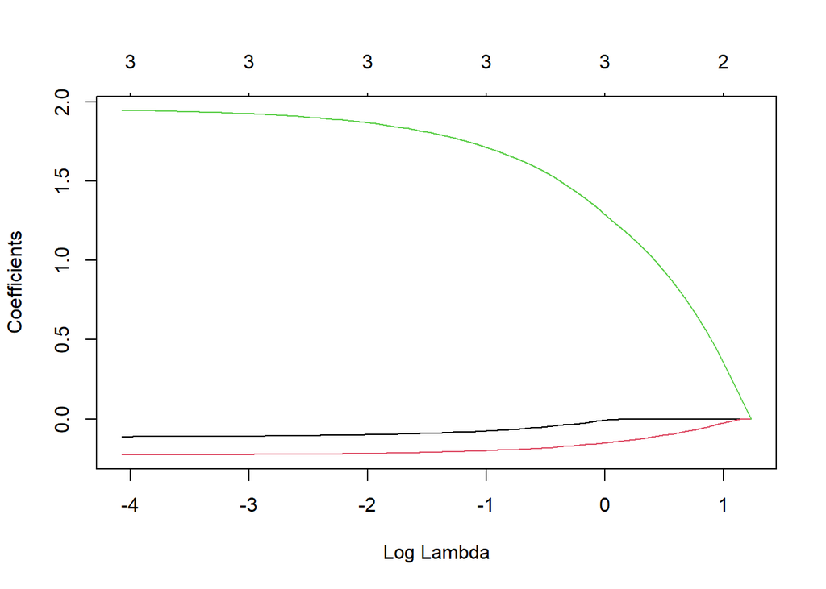

```r
#R code (lasso)
library(glmnet)
y = carbohydrate$carbohydrate
x = as.matrix(carbohydrate[,c('age','weight','protein')])
fit = glmnet(x, y)
plot(fit, xvar='lambda')
```

```r
cvfit = cv.glmnet(x, y, grouped=FALSE)
coef(cvfit, s = "lambda.1se")
```

```
## 4 x 1 sparse Matrix of class "dgCMatrix"
##                     s1
## (Intercept) 34.3091615
## age          .
## weight      -0.0800142
## protein      0.7640510
```

```r
plant.dried
```

```
## # A tibble: 30 × 2
##    group      weight
##    <chr>       <dbl>
##  1 Control      4.17
##  2 Control      5.58
##  3 Control      5.18
##  4 Control      6.11
##  5 Control      4.5
##  6 Control      4.61
##  7 Control      5.17
##  8 Control      4.53
##  9 Control      5.33
## 10 Control      5.14
## 11 TreatmentA   4.81
## 12 TreatmentA   4.17
## 13 TreatmentA   4.41
## 14 TreatmentA   3.59
## 15 TreatmentA   5.87
## 16 TreatmentA   3.83
## 17 TreatmentA   6.03
## 18 TreatmentA   4.89
## 19 TreatmentA   4.32
## 20 TreatmentA   4.69
## 21 TreatmentB   6.31
## 22 TreatmentB   5.12
## 23 TreatmentB   5.54
## 24 TreatmentB   5.5
## 25 TreatmentB   5.37
## # ℹ 5 more rows
```

```r
res.glm1=glm(weight~-1 + group, family=gaussian, data=plant.dried)
summary(res.glm1)
```

```
##
## Call:
## glm(formula = weight ~ -1 + group, family = gaussian, data = plant.dried)
##
## Coefficients:
##                 Estimate Std. Error t value Pr(>|t|)
## groupControl      5.0320     0.1971   25.53   <2e-16 ***
## groupTreatmentA   4.6610     0.1971   23.64   <2e-16 ***
## groupTreatmentB   5.5260     0.1971   28.03   <2e-16 ***
## ---
## Signif. codes:  0 '***' 0.001 '**' 0.01 '*' 0.05 '.' 0.1 ' ' 1
##
## (Dispersion parameter for gaussian family taken to be 0.3885959)
##
##     Null deviance: 786.318  on 30  degrees of freedom
## Residual deviance:  10.492  on 27  degrees of freedom
## AIC: 61.619
##
## Number of Fisher Scoring iterations: 2
```

```r
res.glm0=glm(weight~1, family=gaussian, data=plant.dried)
summary(res.glm0)
```

```
##
## Call:
## glm(formula = weight ~ 1, family = gaussian, data = plant.dried)
##
## Coefficients:
##             Estimate Std. Error t value Pr(>|t|)
## (Intercept)    5.073      0.128   39.63   <2e-16 ***
## ---
## Signif. codes:  0 '***' 0.001 '**' 0.01 '*' 0.05 '.' 0.1 ' ' 1
##
## (Dispersion parameter for gaussian family taken to be 0.49167)
##
##     Null deviance: 14.258  on 29  degrees of freedom
## Residual deviance: 14.258  on 29  degrees of freedom
## AIC: 66.821
##
## Number of Fisher Scoring iterations: 2
```

```r
balanced
```

```
## # A tibble: 12 × 3
##    `factor A` `factor B`  data
##    <chr>      <chr>      <dbl>
##  1 A1         B1           6.8
##  2 A1         B1           6.6
##  3 A1         B2           5.3
##  4 A1         B2           6.1
##  5 A2         B1           7.5
##  6 A2         B1           7.4
##  7 A2         B2           7.2
##  8 A2         B2           6.5
##  9 A3         B1           7.8
## 10 A3         B1           9.1
## 11 A3         B2           8.8
## 12 A3         B2           9.1
```

```r
res.glmint=glm(data~`factor A`*`factor B`, family=gaussian, data=balanced)
res.glmadd=glm(data~`factor A`+`factor B`, family=gaussian, data=balanced)
res.glmA=glm(data~`factor A`, family=gaussian, data=balanced)
res.glmB=glm(data~`factor B`, family=gaussian, data=balanced)
res.glmmean=glm(data~1, family=gaussian, data=balanced)
```

```r
res.glmint
```

```
##
## Call:  glm(formula = data ~ `factor A` * `factor B`, family = gaussian,
##     data = balanced)
##
## Coefficients:
##               (Intercept)               `factor A`A2
##                      6.70                       0.75
##              `factor A`A3               `factor B`B2
##                      1.75                      -1.00
## `factor A`A2:`factor B`B2  `factor A`A3:`factor B`B2
##                      0.40                       1.50
##
## Degrees of Freedom: 11 Total (i.e. Null);  6 Residual
## Null Deviance:       15.83
## Residual Deviance: 1.48  AIC: 22.94
```

```r
summary(res.glmint)
```

```
##
## Call:
## glm(formula = data ~ `factor A` * `factor B`, family = gaussian,
##     data = balanced)
##
## Coefficients:
##                           Estimate Std. Error t value Pr(>|t|)
## (Intercept)                 6.7000     0.3512  19.078 1.34e-06 ***
## `factor A`A2                0.7500     0.4967   1.510   0.1818
## `factor A`A3                1.7500     0.4967   3.524   0.0125 *
## `factor B`B2               -1.0000     0.4967  -2.013   0.0907 .
## `factor A`A2:`factor B`B2   0.4000     0.7024   0.569   0.5897
## `factor A`A3:`factor B`B2   1.5000     0.7024   2.136   0.0766 .
## ---
## Signif. codes:  0 '***' 0.001 '**' 0.01 '*' 0.05 '.' 0.1 ' ' 1
##
## (Dispersion parameter for gaussian family taken to be 0.2466667)
##
##     Null deviance: 15.83  on 11  degrees of freedom
## Residual deviance:  1.48  on  6  degrees of freedom
## AIC: 22.94
##
## Number of Fisher Scoring iterations: 2
```

```r
anova(res.glmint)
```

```
## Analysis of Deviance Table
##
## Model: gaussian, link: identity
##
## Response: data
##
## Terms added sequentially (first to last)
##
##
##                       Df Deviance Resid. Df Resid. Dev
## NULL                                     11    15.8300
## `factor A`             2  12.7400         9     3.0900
## `factor B`             1   0.4033         8     2.6867
## `factor A`:`factor B`  2   1.2067         6     1.4800
```

```r
#b^TX^Ty = y^y-(y-Xb)^T(y-Xb)
sum(res.glmint$data$data^2)
```

```
## [1] 664.1
```

```r
crossprod(res.glmint$data$data)
```

```
##       [,1]
## [1,] 664.1
```

```r
res.glmint$data$data-res.glmint$fitted.values
```

```
##     1     2     3     4     5     6     7     8     9    10    11    12
##  0.10 -0.10 -0.40  0.40  0.05 -0.05  0.35 -0.35 -0.65  0.65 -0.15  0.15
```

```r
res.glmint$residuals
```

```
##     1     2     3     4     5     6     7     8     9    10    11    12
##  0.10 -0.10 -0.40  0.40  0.05 -0.05  0.35 -0.35 -0.65  0.65 -0.15  0.15
```

```r
sum(res.glmint$data$data^2) - sum((res.glmint$data$data-res.glmint$fitted.values)^2)
```

```
## [1] 662.62
```

```r
summary(res.glmadd)
```

```
##
## Call:
## glm(formula = data ~ `factor A` + `factor B`, family = gaussian,
##     data = balanced)
##
## Coefficients:
##              Estimate Std. Error t value Pr(>|t|)
## (Intercept)    6.3833     0.3346  19.079  5.9e-08 ***
## `factor A`A2   0.9500     0.4098   2.318 0.049047 *
## `factor A`A3   2.5000     0.4098   6.101 0.000289 ***
## `factor B`B2  -0.3667     0.3346  -1.096 0.305015
## ---
## Signif. codes:  0 '***' 0.001 '**' 0.01 '*' 0.05 '.' 0.1 ' ' 1
##
## (Dispersion parameter for gaussian family taken to be 0.3358333)
##
##     Null deviance: 15.8300  on 11  degrees of freedom
## Residual deviance:  2.6867  on  8  degrees of freedom
## AIC: 26.095
##
## Number of Fisher Scoring iterations: 2
```

```r
sum(res.glmadd$data$data^2) - sum((res.glmadd$residuals)^2)
```

```
## [1] 661.4133
```

```r
summary(res.glmA)
```

```
##
## Call:
## glm(formula = data ~ `factor A`, family = gaussian, data = balanced)
##
## Coefficients:
##              Estimate Std. Error t value Pr(>|t|)
## (Intercept)    6.2000     0.2930  21.162 5.51e-09 ***
## `factor A`A2   0.9500     0.4143   2.293 0.047550 *
## `factor A`A3   2.5000     0.4143   6.034 0.000194 ***
## ---
## Signif. codes:  0 '***' 0.001 '**' 0.01 '*' 0.05 '.' 0.1 ' ' 1
##
## (Dispersion parameter for gaussian family taken to be 0.3433333)
##
##     Null deviance: 15.83  on 11  degrees of freedom
## Residual deviance:  3.09  on  9  degrees of freedom
## AIC: 25.774
##
## Number of Fisher Scoring iterations: 2
```

```r
sum(res.glmA$data$data^2) - sum((res.glmA$residuals)^2)
```

```
## [1] 661.01
```

```r
summary(res.glmB)
```

```
##
## Call:
## glm(formula = data ~ `factor B`, family = gaussian, data = balanced)
##
## Coefficients:
##              Estimate Std. Error t value Pr(>|t|)
## (Intercept)    7.5333     0.5071  14.857 3.83e-08 ***
## `factor B`B2  -0.3667     0.7171  -0.511     0.62
## ---
## Signif. codes:  0 '***' 0.001 '**' 0.01 '*' 0.05 '.' 0.1 ' ' 1
##
## (Dispersion parameter for gaussian family taken to be 1.542667)
##
##     Null deviance: 15.830  on 11  degrees of freedom
## Residual deviance: 15.427  on 10  degrees of freedom
## AIC: 43.069
##
## Number of Fisher Scoring iterations: 2
```

```r
sum(res.glmB$data$data^2) - sum((res.glmB$residuals)^2)
```

```
## [1] 648.6733
```

```r
summary(res.glmmean)
```

```
##
## Call:
## glm(formula = data ~ 1, family = gaussian, data = balanced)
##
## Coefficients:
##             Estimate Std. Error t value Pr(>|t|)
## (Intercept)   7.3500     0.3463   21.22 2.82e-10 ***
## ---
## Signif. codes:  0 '***' 0.001 '**' 0.01 '*' 0.05 '.' 0.1 ' ' 1
##
## (Dispersion parameter for gaussian family taken to be 1.439091)
##
##     Null deviance: 15.83  on 11  degrees of freedom
## Residual deviance: 15.83  on 11  degrees of freedom
## AIC: 41.379
##
## Number of Fisher Scoring iterations: 2
```

```r
sum(res.glmmean$data$data^2) - sum((res.glmmean$residuals)^2)
```

```
## [1] 648.27
```

```r
#Table6.13
tibble(
  d.f.=c(res.glmint$df.residual,
  res.glmadd$df.residual,
  res.glmA$df.residual,
  res.glmB$df.residual,
  res.glmmean$df.residual),
  bTXTy=c(sum(res.glmint$data$data^2) - sum((res.glmint$residuals)^2),
          sum(res.glmadd$data$data^2) - sum((res.glmadd$residuals)^2),
          sum(res.glmA$data$data^2) - sum((res.glmA$residuals)^2),
          sum(res.glmB$data$data^2) - sum((res.glmB$residuals)^2),
          sum(res.glmmean$data$data^2) - sum((res.glmmean$residuals)^2)),
  scaled_deviance= c(res.glmint$deviance,
  res.glmadd$deviance,
  res.glmA$deviance,
  res.glmB$deviance,
  res.glmmean$deviance),
  ) |> as.data.frame()
```

```
##   d.f.    bTXTy scaled_deviance
## 1    6 662.6200        1.480000
## 2    8 661.4133        2.686667
## 3    9 661.0100        3.090000
## 4   10 648.6733       15.426667
## 5   11 648.2700       15.830000
```

```r
sigmaDs <- res.glmint$deviance
sigmaDi <- res.glmadd$deviance
#F
((sigmaDi-sigmaDs)/(res.glmadd$df.residual-res.glmint$df.residual))/(sigmaDs/res.glmint$df.residual)
```

```
## [1] 2.445946
```

```r
df1=res.glmadd$df.residual-res.glmint$df.residual
df1
```

```
## [1] 2
```

```r
df2=res.glmint$df.residual
df2
```

```
## [1] 6
```

```r
#F
Fstatistic=((sigmaDi-sigmaDs)/(res.glmadd$df.residual-res.glmint$df.residual))/(sigmaDs/res.glmint$df.residual)
1-pf(Fstatistic, df1=df1, df2=df2)
```

```
## [1] 0.1671644
```

```r
sigmaDs <- res.glmint$deviance
sigmaDi <- res.glmadd$deviance
sigmaDa <- res.glmA$deviance
df1=res.glmA$df.residual-res.glmadd$df.residual
df1
```

```
## [1] 1
```

```r
df2=res.glmint$df.residual
df2
```

```
## [1] 6
```

```r
Fstatistic=((sigmaDa-sigmaDi)/(res.glmA$df.residual-res.glmadd$df.residual))/(sigmaDs/res.glmint$df.residual)
Fstatistic
```

```
## [1] 1.635135
```

```r
1-pf(Fstatistic, df1=df1, df2=df2)
```

```
## [1] 0.2482245
```

```r
sigmaDs <- res.glmint$deviance
sigmaDi <- res.glmadd$deviance
sigmaDb <- res.glmB$deviance
df1=res.glmB$df.residual-res.glmadd$df.residual
df1
```

```
## [1] 2
```

```r
df2=res.glmint$df.residual
df2
```

```
## [1] 6
```

```r
Fstatistic=((sigmaDb-sigmaDi)/(res.glmB$df.residual-res.glmadd$df.residual))/(sigmaDs/res.glmint$df.residual)
Fstatistic
```

```
## [1] 25.82432
```

```r
1-pf(Fstatistic, df1=df1, df2=df2)
```

```
## [1] 0.001127422
```

```r
#Table6.14
tibble(Source_of_variantion=c(
  "Mean",
  "Level A",
  "Level B",
  "Interactions",
  "Residual"
),
  d.f.=c(
  length(res.glmmean$coefficients),
  length(res.glmA$coefficients)-length(res.glmmean$coefficients),
  length(res.glmB$coefficients)-length(res.glmmean$coefficients),
  length(res.glmint$coefficients)-length(res.glmA$coefficients)-length(res.glmB$coefficients)+length(res.glmmean$coefficients),
  res.glmint$df.residual
  ),
  sum_of_squares=c(
    sum(res.glmmean$data$data^2) - sum((res.glmmean$residuals)^2),
    sum(res.glmA$data$data^2) - sum((res.glmA$residuals)^2) - (sum(res.glmmean$data$data^2) - sum((res.glmmean$residuals)^2)),
    sum(res.glmB$data$data^2) - sum((res.glmB$residuals)^2) - (sum(res.glmmean$data$data^2) - sum((res.glmmean$residuals)^2)),
    sum(res.glmint$data$data^2) - sum((res.glmint$residuals)^2) -
    (sum(res.glmA$data$data^2) - sum((res.glmA$residuals)^2)) -
      (sum(res.glmB$data$data^2) - sum((res.glmB$residuals)^2)) +
      ((sum(res.glmmean$data$data^2) - sum((res.glmmean$residuals)^2))),
    sum((res.glmint$residuals)^2)
  ),
  Mean_squares = sum_of_squares/`d.f.`,
  "F"=c(
    " ",
    ((sigmaDb-sigmaDi)/(res.glmB$df.residual-res.glmadd$df.residual))/(sigmaDs/res.glmint$df.residual),
    ((sigmaDa-sigmaDi)/(res.glmA$df.residual-res.glmadd$df.residual))/(sigmaDs/res.glmint$df.residual),
    ((sigmaDi-sigmaDs)/(res.glmadd$df.residual-res.glmint$df.residual))/(sigmaDs/res.glmint$df.residual),
    " "
  )
  ) |> as.data.frame()
```

```
##   Source_of_variantion d.f. sum_of_squares Mean_squares                F
## 1                 Mean    1    648.2700000  648.2700000
## 2              Level A    2     12.7400000    6.3700000 25.8243243243243
## 3              Level B    1      0.4033333    0.4033333 1.63513513513513
## 4         Interactions    2      1.2066667    0.6033333 2.44594594594595
## 5             Residual    6      1.4800000    0.2466667
```

```r
anova(res.glmmean, res.glmA, res.glmB, res.glmadd, res.glmint)
```

```
## Analysis of Deviance Table
##
## Model 1: data ~ 1
## Model 2: data ~ `factor A`
## Model 3: data ~ `factor B`
## Model 4: data ~ `factor A` + `factor B`
## Model 5: data ~ `factor A` * `factor B`
##   Resid. Df Resid. Dev Df Deviance
## 1        11    15.8300
## 2         9     3.0900  2  12.7400
## 3        10    15.4267 -1 -12.3367
## 4         8     2.6867  2  12.7400
## 5         6     1.4800  2   1.2067
```

```r
#Table6.14
anova(res.glmmean, res.glmA, res.glmB, res.glmadd, res.glmint)$`Resid. Dev`
```

```
## [1] 15.830000  3.090000 15.426667  2.686667  1.480000
```

```r
#sum_of_squares Mean
sum(res.glmmean$data$data^2) - sum((res.glmmean$residuals)^2)
```

```
## [1] 648.27
```

```r
#sum_of_squares Level A
anova(res.glmmean, res.glmA, res.glmB, res.glmadd, res.glmint)$`Resid. Dev`[1] - anova(res.glmmean, res.glmA, res.glmB, res.glmadd, res.glmint)$`Resid. Dev`[2]
```

```
## [1] 12.74
```

```r
#sum_of_squares Level B
anova(res.glmmean, res.glmA, res.glmB, res.glmadd, res.glmint)$`Resid. Dev`[1] - anova(res.glmmean, res.glmA, res.glmB, res.glmadd, res.glmint)$`Resid. Dev`[3]
```

```
## [1] 0.4033333
```

```r
#sum_of_squares Interactions
anova(res.glmmean, res.glmA, res.glmB, res.glmadd, res.glmint)$`Resid. Dev`[4] - anova(res.glmmean, res.glmA, res.glmB, res.glmadd, res.glmint)$`Resid. Dev`[5]
```

```
## [1] 1.206667
```

```r
#sum_of_squares Residual
anova(res.glmmean, res.glmA, res.glmB, res.glmadd, res.glmint)$`Resid. Dev`[5]
```

```
## [1] 1.48
```

```r
#Table6.15
achievement
```

```
## # A tibble: 21 × 3
##    method     y     x
##    <chr>  <dbl> <dbl>
##  1 A          6     3
##  2 A          4     1
##  3 A          5     3
##  4 A          3     1
##  5 A          4     2
##  6 A          3     1
##  7 A          6     4
##  8 B          8     4
##  9 B          9     5
## 10 B          7     5
## 11 B          9     4
## 12 B          8     3
## 13 B          5     1
## 14 B          7     2
## 15 C          6     3
## 16 C          7     2
## 17 C          7     2
## 18 C          7     3
## 19 C          8     4
## 20 C          5     1
## 21 C          7     4
```

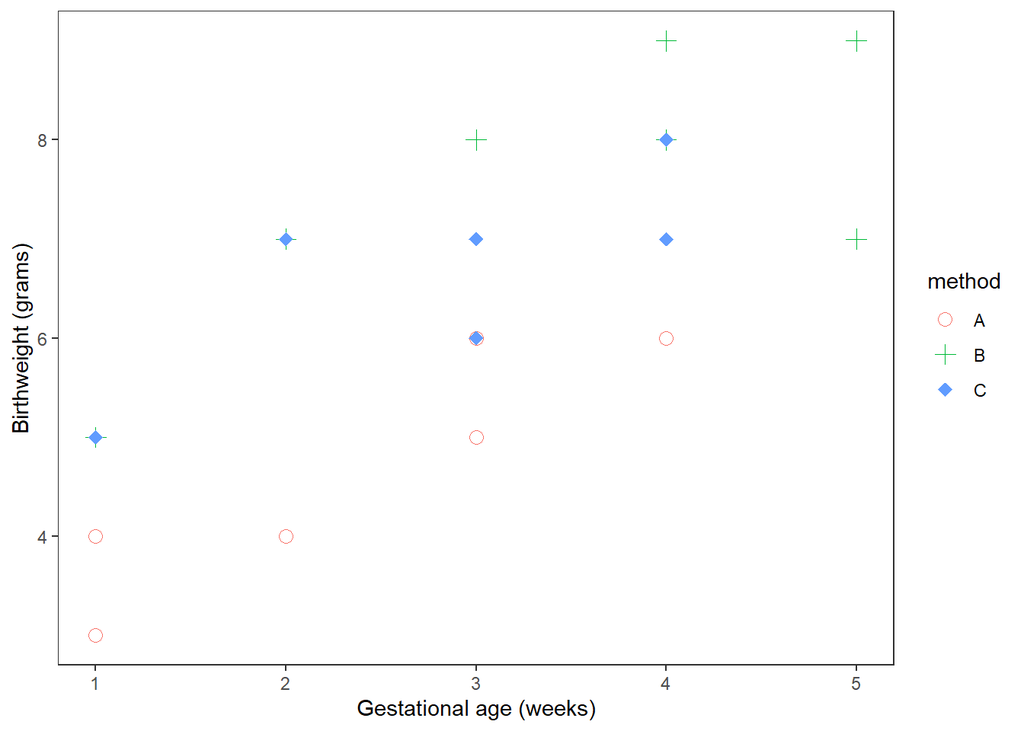

```r
achievement |> ggplot(aes(x=x,
                          y=y,
                          group=method)) + geom_point(aes(shape=method, color=method), size=3) +
  theme_bw() + theme(
  # Hide panel borders and remove grid lines
  #panel.border = element_line(colour = "black"),
  panel.grid.major = element_blank(),
  panel.grid.minor = element_blank(),
  # Change axis line
  #axis.line = element_line(colour = "black")
) + xlab("Gestational age (weeks)") +
  ylab("Birthweight (grams)") + scale_shape_manual(values=c(1, 3, 18))
```

```r
#Model 6.13
res.glm=glm(y~x+method, family=gaussian, data=achievement)
summary(res.glm)
```

```
##
## Call:
## glm(formula = y ~ x + method, family = gaussian, data = achievement)
##
## Coefficients:
##             Estimate Std. Error t value Pr(>|t|)
## (Intercept)   2.8367     0.4235   6.699 3.74e-06 ***
## x             0.7429     0.1421   5.227 6.84e-05 ***
## methodB       2.1878     0.4545   4.814 0.000162 ***
## methodC       1.8612     0.4240   4.390 0.000400 ***
## ---
## Signif. codes:  0 '***' 0.001 '**' 0.01 '*' 0.05 '.' 0.1 ' ' 1
##
## (Dispersion parameter for gaussian family taken to be 0.6060024)
##
##     Null deviance: 63.810  on 20  degrees of freedom
## Residual deviance: 10.302  on 17  degrees of freedom
## AIC: 54.64
##
## Number of Fisher Scoring iterations: 2
```

```r
#Model 6.13
summary(res.glm)$coefficients
```

```
##              Estimate Std. Error  t value     Pr(>|t|)
## (Intercept) 2.8367347  0.4234705 6.698778 3.739415e-06
## x           0.7428571  0.1421270 5.226714 6.837988e-05
## methodB     2.1877551  0.4544618 4.813947 1.620169e-04
## methodC     1.8612245  0.4239569 4.390126 3.995625e-04
```

```r
summary(res.glm)$coefficients[1]
```

```
## [1] 2.836735
```

```r
summary(res.glm)$coefficients[1]+summary(res.glm)$coefficients[3]
```

```
## [1] 5.02449
```

```r
summary(res.glm)$coefficients[1]+summary(res.glm)$coefficients[4]
```

```
## [1] 4.697959
```

```r
summary(res.glm)$coefficients[2]
```

```
## [1] 0.7428571
```

```r
#sigmaD1
res.glm$deviance
```

```
## [1] 10.30204
```

```r
#Model 6.14
res.glm2=glm(y~x, family=gaussian, data=achievement)
summary(res.glm2)
```

```
##
## Call:
## glm(formula = y ~ x, family = gaussian, data = achievement)
##
## Coefficients:
##             Estimate Std. Error t value Pr(>|t|)
## (Intercept)   3.4468     0.6112   5.639 1.95e-05 ***
## x             1.0106     0.2001   5.051 7.09e-05 ***
## ---
## Signif. codes:  0 '***' 0.001 '**' 0.01 '*' 0.05 '.' 0.1 ' ' 1
##
## (Dispersion parameter for gaussian family taken to be 1.433371)
##
##     Null deviance: 63.810  on 20  degrees of freedom
## Residual deviance: 27.234  on 19  degrees of freedom
## AIC: 71.054
##
## Number of Fisher Scoring iterations: 2
```

```r
#Model 6.14
summary(res.glm2)$coefficients
```

```
##             Estimate Std. Error  t value     Pr(>|t|)
## (Intercept) 3.446809  0.6112211 5.639217 1.946757e-05
## x           1.010638  0.2000691 5.051447 7.088061e-05
```

```r
summary(res.glm2)$coefficients[1]
```

```
## [1] 3.446809
```

```r
summary(res.glm2)$coefficients[2]
```

```
## [1] 1.010638
```

```r
#sigmaD0
res.glm2$deviance
```

```
## [1] 27.23404
```

```r
anova(res.glm2,res.glm)
```

```
## Analysis of Deviance Table
##
## Model 1: y ~ x
## Model 2: y ~ x + method
##   Resid. Df Resid. Dev Df Deviance
## 1        19     27.234
## 2        17     10.302  2   16.932
```

```r
#b^TX^Ty
sum((res.glm2$data$y)^2) - sum((res.glm2$data$y-res.glm2$fitted.values)^2)
```

```
## [1] 853.766
```

```r
sum(res.glm2$fitted.values^2)
```

```
## [1] 853.766
```

```r
anova(res.glm2,res.glm)$`Resid. Df`
```

```
## [1] 19 17
```

```r
#Table6.16
tibble(d.f.=c(length(res.glm2$coefficients),
              anova(res.glm2,res.glm)$`Resid. Df`[1]-anova(res.glm2,res.glm)$`Resid. Df`[2],
              anova(res.glm2,res.glm)$`Resid. Df`[2]),
       sum_of_squaresc=c(sum(res.glm2$fitted.values^2),
                         anova(res.glm2,res.glm)$`Resid. Dev`[1]-anova(res.glm2,res.glm)$`Resid. Dev`[2],
                         anova(res.glm2,res.glm)$`Resid. Dev`[2]),
       Mean_squares=sum_of_squaresc/`d.f.`,
       "F"=c("",Mean_squares[2]/Mean_squares[3],"")) |> as.data.frame()
```

```
##   d.f. sum_of_squaresc Mean_squares                F
## 1    2       853.76596  426.8829787
## 2    2        16.93200    8.4660009 13.9702431129244
## 3   17        10.30204    0.6060024
```

```r
head(PLOS)
```

```
##   nchar authors
## 1   150       6
## 2    88      17
## 3    64       3
## 4   126      30
## 5    87       9
## 6   115       3
```

```r
dim(PLOS)
```

```
## [1] 878   2
```

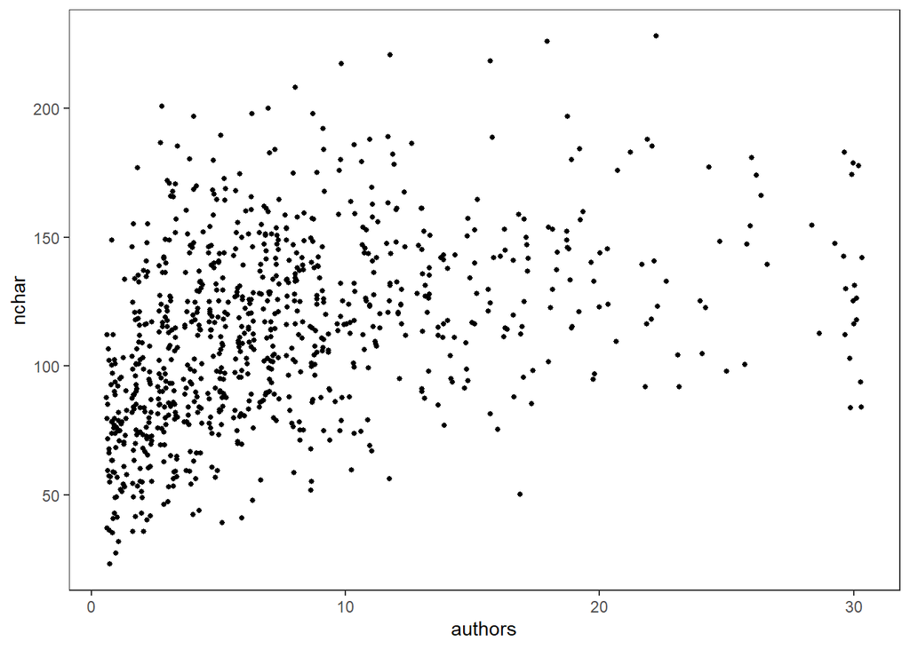

```r
#Figure6.7
PLOS |> ggplot(aes(x=authors,
                   y=nchar))+geom_jitter(size=1)+theme_bw() + theme(
  # Hide panel borders and remove grid lines
  #panel.border = element_line(colour = "black"),
  panel.grid.major = element_blank(),
  panel.grid.minor = element_blank(),
  # Change axis line
  #axis.line = element_line(colour = "black")
)
```

```r
#Model6.15
lmodel = lm(nchar ~ authors, data=PLOS)
summary(lmodel)
```

```
##
## Call:
## lm(formula = nchar ~ authors, data = PLOS)
##
## Residuals:
##     Min      1Q  Median      3Q     Max
## -83.210 -23.156  -1.519  20.753  99.068
##
## Coefficients:
##             Estimate Std. Error t value Pr(>|t|)
## (Intercept)  96.1061     1.7554   54.75   <2e-16 ***
## authors       2.1826     0.1737   12.56   <2e-16 ***
## ---
## Signif. codes:  0 '***' 0.001 '**' 0.01 '*' 0.05 '.' 0.1 ' ' 1
##
## Residual standard error: 32.89 on 876 degrees of freedom
## Multiple R-squared:  0.1527, Adjusted R-squared:  0.1517
## F-statistic: 157.8 on 1 and 876 DF,  p-value: < 2.2e-16
```

```r
#Model6.16
qmodel = lm(nchar ~ authors + I(authors^2), data=PLOS)
summary(qmodel)
```

```
##
## Call:
## lm(formula = nchar ~ authors + I(authors^2), data = PLOS)
##
## Residuals:
##    Min     1Q Median     3Q    Max
## -90.09 -21.33  -2.51  18.34 102.78
##
## Coefficients:
##              Estimate Std. Error t value Pr(>|t|)
## (Intercept)  81.40444    2.47751   32.86  < 2e-16 ***
## authors       6.06579    0.50618   11.98  < 2e-16 ***
## I(authors^2) -0.15375    0.01891   -8.13 1.46e-15 ***
## ---
## Signif. codes:  0 '***' 0.001 '**' 0.01 '*' 0.05 '.' 0.1 ' ' 1
##
## Residual standard error: 31.73 on 875 degrees of freedom
## Multiple R-squared:  0.2122, Adjusted R-squared:  0.2104
## F-statistic: 117.8 on 2 and 875 DF,  p-value: < 2.2e-16
```

```r
sum(lmodel$residuals^2)
```

```
## [1] 947501.8
```

```r
sum(qmodel$residuals^2)
```

```
## [1] 880950.2
```

```r
anova(lmodel, qmodel)
```

```
## Analysis of Variance Table
##
## Model 1: nchar ~ authors
## Model 2: nchar ~ authors + I(authors^2)
##   Res.Df    RSS Df Sum of Sq      F    Pr(>F)
## 1    876 947502
## 2    875 880950  1     66552 66.102 1.458e-15 ***
## ---
## Signif. codes:  0 '***' 0.001 '**' 0.01 '*' 0.05 '.' 0.1 ' ' 1
```

```r
#Table6.21
#Fractional polynomials
p=c(-2,-1,-0.5,0,0.5,1,2,3)
for(i in p){
  model = lm(nchar ~ I(authors^i), data=PLOS)
  print(sum(model$residuals^2))
}
```

```
## [1] 926425.7
## [1] 872771.8
## [1] 852655.3
## [1] 1118208
## [1] 896880.9
## [1] 947501.8
## [1] 1025531
## [1] 1064216
```

```r
p=c(-2,-1,-0.5,0,0.5,1,2,3)
model <- function(i){
  sum(lm(nchar ~ I(authors^i), data=PLOS)$residuals^2)
}

sapply(p, model)
```

```
## [1]  926425.7  872771.8  852655.3 1118207.9  896880.9  947501.8 1025530.8
## [8] 1064216.3
```

```r
sugar
```

```
## # A tibble: 6 × 3
##   period  refined manufactured
##   <chr>     <dbl>        <dbl>
## 1 1936-39    32           16.3
## 2 1046-49    31.2         23.1
## 3 1956-59    27           23.6
## 4 1966-69    21           27.7
## 5 1976-79    14.9         34.6
## 6 1986-89     8.8         33.9
```

```r
sugar2 <- sugar
sugar2["decade"] <- c(seq(0,5))
sugar2
```

```
## # A tibble: 6 × 4
##   period  refined manufactured decade
##   <chr>     <dbl>        <dbl>  <int>
## 1 1936-39    32           16.3      0
## 2 1046-49    31.2         23.1      1
## 3 1956-59    27           23.6      2
## 4 1966-69    21           27.7      3
## 5 1976-79    14.9         34.6      4
## 6 1986-89     8.8         33.9      5
```

```r
model1 <- lm(refined ~ decade, data=sugar2)
summary(model1)
```

```
##
## Call:
## lm(formula = refined ~ decade, data = sugar2)
##
## Residuals:
##       1       2       3       4       5       6
## -2.6905  1.3924  2.0752  0.9581 -0.2590 -1.4762
##
## Coefficients:
##             Estimate Std. Error t value Pr(>|t|)
## (Intercept)  34.6905     1.4765   23.50 1.95e-05 ***
## decade       -4.8829     0.4877  -10.01 0.000559 ***
## ---
## Signif. codes:  0 '***' 0.001 '**' 0.01 '*' 0.05 '.' 0.1 ' ' 1
##
## Residual standard error: 2.04 on 4 degrees of freedom
## Multiple R-squared:  0.9616, Adjusted R-squared:  0.952
## F-statistic: 100.2 on 1 and 4 DF,  p-value: 0.0005593
```

```r
#coefficients
model1$coefficients
```

```
## (Intercept)      decade
##   34.690476   -4.882857
```

```r
#extract standard error of individual regression coefficients
sqrt(diag(vcov(model1)))
```

```
## (Intercept)      decade
##   1.4765230   0.4876795
```

```r
#extract residual standard error of regression model
summary(model1)$sigma
```

```
## [1] 2.04011
```

```r
#95% confidence interval
t_value <- qt(0.975, df=4)
t_value
```

```
## [1] 2.776445
```

```r
sd <- sqrt(diag(vcov(model1)))[2]
model1$coefficients[2]-t_value*sd
```

```
##    decade
## -6.236872
```

```r
model1$coefficients[2]+t_value*sd
```

```
##    decade
## -3.528842
```

```r
model2 <- lm(manufactured ~ decade, data=sugar2)
summary(model2)
```

```
##
## Call:
## lm(formula = manufactured ~ decade, data = sugar2)
##
## Residuals:
##       1       2       3       4       5       6
## -1.1905  1.9924 -1.1248 -0.6419  2.6410 -1.6762
##
## Coefficients:
##             Estimate Std. Error t value Pr(>|t|)
## (Intercept)  17.4905     1.4854  11.775 0.000298 ***
## decade        3.6171     0.4906   7.373 0.001804 **
## ---
## Signif. codes:  0 '***' 0.001 '**' 0.01 '*' 0.05 '.' 0.1 ' ' 1
##
## Residual standard error: 2.052 on 4 degrees of freedom
## Multiple R-squared:  0.9315, Adjusted R-squared:  0.9143
## F-statistic: 54.36 on 1 and 4 DF,  p-value: 0.001804
```

```r
#coefficients
model2$coefficients
```

```
## (Intercept)      decade
##   17.490476    3.617143
```

```r
#extract standard error of individual regression coefficients
sqrt(diag(vcov(model2)))
```

```
## (Intercept)      decade
##   1.4853655   0.4906001
```

```r
#95% confidence interval
model2$coefficients[2]-t_value*sd
```

```
##   decade
## 2.263128
```

```r
model2$coefficients[2]+t_value*sd
```

```
##   decade
## 4.971158
```

```r
sugar2['Total'] <- sugar2['refined']+sugar2['manufactured']
model3 <- lm(Total ~ decade, data=sugar2)
summary(model3)
```

```
##
## Call:
## lm(formula = Total ~ decade, data = sugar2)
##
## Residuals:
##       1       2       3       4       5       6
## -3.8810  3.3848  0.9505  0.3162  2.3819 -3.1524
##
## Coefficients:
##             Estimate Std. Error t value Pr(>|t|)
## (Intercept)   52.181      2.377  21.956 2.55e-05 ***
## decade        -1.266      0.785  -1.612    0.182
## ---
## Signif. codes:  0 '***' 0.001 '**' 0.01 '*' 0.05 '.' 0.1 ' ' 1
##
## Residual standard error: 3.284 on 4 degrees of freedom
## Multiple R-squared:  0.3939, Adjusted R-squared:  0.2424
## F-statistic:   2.6 on 1 and 4 DF,  p-value: 0.1822
```

```r
#Table 6.23
pasture
```

```
## # A tibble: 27 × 2
##        K yield
##    <dbl> <dbl>
##  1     0 1754.
##  2    40 4923.
##  3    50 5246.
##  4     5 3185.
##  5    10 3538.
##  6    30 4000
##  7    15 4185.
##  8    40 4692.
##  9    20 3600
## 10    15 3108.
## 11    30 4415.
## 12    50 4938.
## 13     5 3046.
## 14     0 2554.
## 15    10 3323.
## 16    40 4462.
## 17    20 4215.
## 18    40 4154.
## 19    10 2400
## 20     5 2862.
## 21    40 3723
## 22    30 4892.
## 23    40 4785.
## 24    20 3185.
## 25     0 2723.
## # ℹ 2 more rows
```

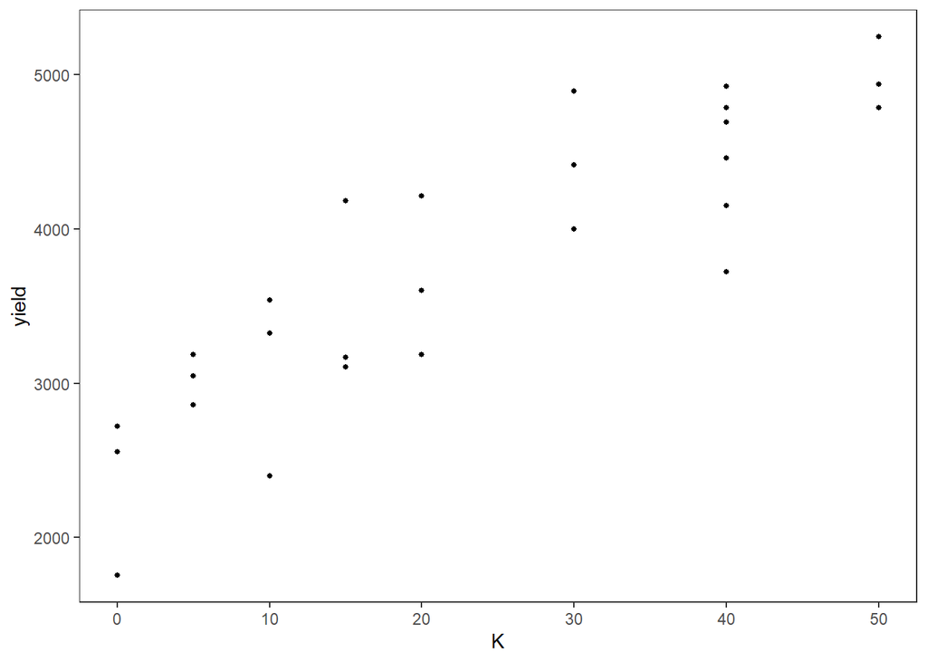

```r
#EXERCISES 6.2
pasture |> ggplot(aes(x=K,
                   y=yield))+geom_point(size=1)+theme_bw() + theme(
  # Hide panel borders and remove grid lines
  #panel.border = element_line(colour = "black"),
  panel.grid.major = element_blank(),
  panel.grid.minor = element_blank(),
  # Change axis line
  #axis.line = element_line(colour = "black")
)
```

```r
lmodel2 = lm(yield ~ K, data=pasture)
summary(lmodel2)
```

```
##
## Call:
## lm(formula = yield ~ K, data = pasture)
##
## Residuals:
##     Min      1Q  Median      3Q     Max
## -890.32 -231.14  -11.45  252.25  814.96
##
## Coefficients:
##             Estimate Std. Error t value Pr(>|t|)
## (Intercept) 2644.224    148.366  17.822 1.01e-15 ***
## K             48.361      5.192   9.315 1.32e-09 ***
## ---
## Signif. codes:  0 '***' 0.001 '**' 0.01 '*' 0.05 '.' 0.1 ' ' 1
##
## Residual standard error: 445.1 on 25 degrees of freedom
## Multiple R-squared:  0.7763, Adjusted R-squared:  0.7674
## F-statistic: 86.77 on 1 and 25 DF,  p-value: 1.316e-09
```

```r
qmodel2 = lm(yield ~ K + I(K^2), data=pasture)
summary(qmodel2)
```

```
##
## Call:
## lm(formula = yield ~ K + I(K^2), data = pasture)
##
## Residuals:
##     Min      1Q  Median      3Q     Max
## -876.18 -257.45   82.54  287.88  722.17
##
## Coefficients:
##              Estimate Std. Error t value Pr(>|t|)
## (Intercept) 2471.2637   196.1115  12.601 4.51e-12 ***
## K             73.8059    19.8999   3.709   0.0011 **
## I(K^2)        -0.5152     0.3894  -1.323   0.1983
## ---
## Signif. codes:  0 '***' 0.001 '**' 0.01 '*' 0.05 '.' 0.1 ' ' 1
##
## Residual standard error: 438.6 on 24 degrees of freedom
## Multiple R-squared:  0.7915, Adjusted R-squared:  0.7742
## F-statistic: 45.56 on 2 and 24 DF,  p-value: 6.736e-09
```

```r
anova(lmodel2, qmodel2)
```

```
## Analysis of Variance Table
##
## Model 1: yield ~ K
## Model 2: yield ~ K + I(K^2)
##   Res.Df     RSS Df Sum of Sq      F Pr(>F)
## 1     25 4952793
## 2     24 4616095  1    336698 1.7506 0.1983
```

```r
#standard deviation of residual
N=length(pasture$K)
p=3
sigma_sq <- (t(pasture$yield-qmodel2$fitted.values) %*% (pasture$yield-qmodel2$fitted.values))/(N-p)
sigma_hat <- sqrt(sigma_sq)
std_e <- as.vector(sigma_hat)*sqrt(1-hatvalues(qmodel2))
std_e
```

```
##        1        2        3        4        5        6        7        8
## 392.2723 421.5502 382.4364 417.6786 424.3213 418.1877 422.4668 421.5502
##        9       10       11       12       13       14       15       16
## 418.6776 422.4668 418.1877 382.4364 417.6786 392.2723 424.3213 421.5502
##       17       18       19       20       21       22       23       24
## 418.6776 421.5502 424.3213 417.6786 421.5502 418.1877 421.5502 418.6776
##       25       26       27
## 392.2723 382.4364 422.4668
```

```r
#standardized residuals
qmodel2$residuals/std_e
```

```
##           1           2           3           4           5           6
## -1.82873907  0.76839933  0.97438347  0.85517076  0.89718998 -0.53029260
##           7           8           9          10          11          12
##  1.70940578  0.22089635 -0.33749718 -0.83967034  0.46304132  0.16954371
##          13          14          15          16          17          18
##  0.52381553  0.21040554  0.38955584 -0.32660664  1.13236888 -1.05629433
##          19          20          21          22          23          24
## -1.78591804  0.08184895 -2.07847386  1.60343841  0.43985010 -1.32966870
##          25          26          27
##  0.64199347 -0.23261469 -0.69386007
```

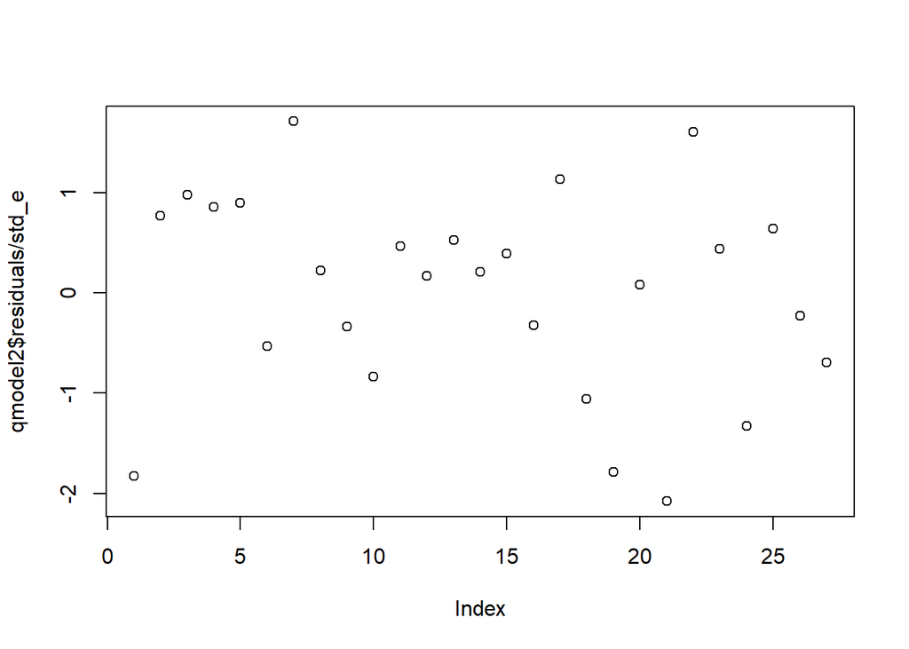

```r
plot(qmodel2$residuals/std_e)
```

```r
#EXERCISES6.3
m1 <- lm(carbohydrate~age+weight+protein,data=carbohydrate)
m2 <- lm(carbohydrate~weight+protein,data=carbohydrate)
m3 <- lm(carbohydrate~age+protein,data=carbohydrate)
m4 <- lm(carbohydrate~protein,data=carbohydrate)
anova(m1, m2, m3, m4)
```

```
## Analysis of Variance Table
##
## Model 1: carbohydrate ~ age + weight + protein
## Model 2: carbohydrate ~ weight + protein
## Model 3: carbohydrate ~ age + protein
## Model 4: carbohydrate ~ protein
##   Res.Df    RSS Df Sum of Sq      F Pr(>F)
## 1     16 567.66
## 2     17 606.02 -1   -38.359 1.0812 0.3139
## 3     17 833.57  0  -227.549
## 4     18 858.65 -1   -25.079 0.7069 0.4129
```

```r
#EXERCISES6.4
cholesterol
```

```
## # A tibble: 30 × 3
##     chol   age   bmi
##    <dbl> <dbl> <dbl>
##  1  5.94    52  20.7
##  2  4.71    46  21.3
##  3  5.86    51  25.4
##  4  6.52    44  22.7
##  5  6.8     70  23.9
##  6  5.23    33  24.3
##  7  4.97    21  22.2
##  8  8.78    63  26.2
##  9  5.13    56  23.3
## 10  6.74    54  29.2
## 11  5.95    44  22.7
## 12  5.83    71  21.9
## 13  5.74    39  22.4
## 14  4.92    58  20.2
## 15  6.69    58  24.4
## 16  6.48    65  26.3
## 17  8.83    76  22.7
## 18  5.1     47  21.5
## 19  5.81    43  20.7
## 20  4.65    30  18.9
## 21  6.82    58  23.9
## 22  6.28    78  24.3
## 23  5.15    49  23.8
## 24  2.92    36  19.6
## 25  9.27    67  24.3
## # ℹ 5 more rows
```

```r
m5 <- lm(chol~age+bmi,data=cholesterol)
m6 <- lm(chol~age,data=cholesterol)
anova(m5, m6)
```

```
## Analysis of Variance Table
##
## Model 1: chol ~ age + bmi
## Model 2: chol ~ age
##   Res.Df    RSS Df Sum of Sq      F  Pr(>F)
## 1     27 26.571
## 2     28 31.636 -1   -5.0655 5.1474 0.03149 *
## ---
## Signif. codes:  0 '***' 0.001 '**' 0.01 '*' 0.05 '.' 0.1 ' ' 1
```

```r
#EXERCISES6.5
plasma
```

```
## # A tibble: 31 × 2
##    Group phosphate
##    <chr>     <dbl>
##  1 H-O         2.3
##  2 H-O         4.1
##  3 H-O         4.2
##  4 H-O         4
##  5 H-O         4.6
##  6 H-O         4.6
##  7 H-O         3.8
##  8 H-O         5.2
##  9 H-O         3.1
## 10 H-O         3.7
## 11 H-O         3.8
## 12 N-O         3
## 13 N-O         4.1
## 14 N-O         3.9
## 15 N-O         3.1
## 16 N-O         3.3
## 17 N-O         2.9
## 18 N-O         3.3
## 19 N-O         3.9
## 20 C           3
## 21 C           2.6
## 22 C           3.1
## 23 C           2.2
## 24 C           2.1
## 25 C           2.4
## # ℹ 6 more rows
```

```r
m7 <- lm(phosphate~Group,data=plasma)
#Sum of squares: mean
length(plasma$phosphate)*mean(plasma$phosphate)^2
```

```
## [1] 350.919
```

```r
anova(m7)
```

```
## Analysis of Variance Table
##
## Response: phosphate
##           Df Sum Sq Mean Sq F value    Pr(>F)
## Group      2 7.8083  3.9041  11.651 0.0002082 ***
## Residuals 28 9.3827  0.3351
## ---
## Signif. codes:  0 '***' 0.001 '**' 0.01 '*' 0.05 '.' 0.1 ' ' 1
```

```r
tibble(d.f.=c(1,
              anova(m7)$`Df`[1],
              anova(m7)$`Df`[2]),
       Sum_of_squares=c(length(plasma$phosphate)*mean(plasma$phosphate)^2,
                        anova(m7)$`Sum Sq`[1],
                        anova(m7)$`Sum Sq`[2]),
       Mean_squares=Sum_of_squares/d.f.,
       "F"=c("",Mean_squares[2]/Mean_squares[3],"")) |> as.data.frame()
```

```
##   d.f. Sum_of_squares Mean_squares                F
## 1    1     350.919032   350.919032
## 2    2       7.808278     3.904139 11.6508063181284
## 3   28       9.382689     0.335096
```

```r
1-pf(11.6508063181284, df1=2, df2=28)
```

```
## [1] 0.0002081509
```

```r
#pooled standard deviation
N=length(plasma$phosphate)
p=3
sqrt(sum((plasma$phosphate-m7$fitted.values)^2)/(N-p))
```

```
## [1] 0.5788748
```

```r
summary(m7)
```

```
##
## Call:
## lm(formula = phosphate ~ Group, data = plasma)
##
## Residuals:
##      Min       1Q   Median       3Q      Max
## -1.64545 -0.29148  0.01667  0.36667  1.25455
##
## Coefficients:
##             Estimate Std. Error t value Pr(>|t|)
## (Intercept)   2.7833     0.1671  16.656 4.63e-16 ***
## GroupH-O      1.1621     0.2416   4.809 4.67e-05 ***
## GroupN-O      0.6542     0.2642   2.476   0.0196 *
## ---
## Signif. codes:  0 '***' 0.001 '**' 0.01 '*' 0.05 '.' 0.1 ' ' 1
##
## Residual standard error: 0.5789 on 28 degrees of freedom
## Multiple R-squared:  0.4542, Adjusted R-squared:  0.4152
## F-statistic: 11.65 on 2 and 28 DF,  p-value: 0.0002082
```

```r
m7$coefficients
```

```
## (Intercept)    GroupH-O    GroupN-O
##   2.7833333   1.1621212   0.6541667
```

```r
plasma |> group_by(Group) |> summarise(n=n())
```

```
## # A tibble: 3 × 2
##   Group     n
##   <chr> <int>
## 1 C        12
## 2 H-O      11
## 3 N-O       8
```

```r
t_value <- qt(0.975, df=28)
t_value
```

```
## [1] 2.048407
```

```r
sd <- sqrt(sum((plasma$phosphate-m7$fitted.values)^2)/(N-p))
sd
```

```
## [1] 0.5788748
```

```r
#95% percentile
m7$coefficients[2]-m7$coefficients[3]-t_value*sd*sqrt(1/11+1/8)
```

```
##    GroupH-O
## -0.04302617
```

```r
m7$coefficients[2]-m7$coefficients[3]+t_value*sd*sqrt(1/11+1/8)
```

```
## GroupH-O
## 1.058935
```

```r
#EXERCISES6.6
machine2 <- machine |> mutate(day=factor(day),
                  worker=factor(worker)) |> drop_na() |> as.data.frame()
machine2[37, 3] <- 32.9
machine2$weight
```

```
##  [1] 35.7 37.1 36.7 37.7 35.3 38.4 37.2 38.1 36.9 37.2 34.9 34.3 34.5 33.7 36.2
## [16] 37.1 35.5 36.5 36.0 33.8 34.7 35.2 34.6 36.4 35.2 36.9 38.5 36.4 37.8 36.1
## [31] 32.0 35.2 33.5 32.9 33.3 35.8 32.9 35.7 38.0 36.1
```

```r
#Sum of squares: Mean
length(machine2$weight)*(mean(machine2$weight))^2
```

```
## [1] 51122.5
```

```r
m8 <- lm(weight~1,data=machine2)
m9 <- lm(weight~worker,data=machine2)
m10 <- lm(weight~day,data=machine2)
m11 <- lm(weight~day+worker,data=machine2)
m12 <- lm(weight~day*worker,data=machine2)

anova(m8,m9,m10,m11,m12)
```

```
## Analysis of Variance Table
##
## Model 1: weight ~ 1
## Model 2: weight ~ worker
## Model 3: weight ~ day
## Model 4: weight ~ day + worker
## Model 5: weight ~ day * worker
##   Res.Df     RSS Df Sum of Sq      F    Pr(>F)
## 1     39 103.860
## 2     36  49.238  3    54.622 14.495 3.895e-06 ***
## 3     38  97.776 -2   -48.538 19.320 3.144e-06 ***
## 4     35  43.154  3    54.622 14.495 3.895e-06 ***
## 5     32  40.196  3     2.958  0.785    0.5112
## ---
## Signif. codes:  0 '***' 0.001 '**' 0.01 '*' 0.05 '.' 0.1 ' ' 1
```

```r
#EXERCISES6.7
balanced
```

```
## # A tibble: 12 × 3
##    `factor A` `factor B`  data
##    <chr>      <chr>      <dbl>
##  1 A1         B1           6.8
##  2 A1         B1           6.6
##  3 A1         B2           5.3
##  4 A1         B2           6.1
##  5 A2         B1           7.5
##  6 A2         B1           7.4
##  7 A2         B2           7.2
##  8 A2         B2           6.5
##  9 A3         B1           7.8
## 10 A3         B1           9.1
## 11 A3         B2           8.8
## 12 A3         B2           9.1
```

```r
N=length(balanced$data)
y=balanced$data
X=matrix(c(rep(1,N),
         c(rep(-1,4),rep(1,4),rep(0,4)),
         c(rep(-1,4),rep(0,4),rep(1,4)),
         c(rep(-1,2),rep(1,2),rep(-1,2),rep(1,2),rep(-1,2),rep(1,2)),
         c(rep(1,2),rep(-1,4),rep(1,2),rep(0,4)),
         c(rep(1,2),rep(-1,2),rep(0,4),rep(-1,2),rep(1,2))),
         ncol = 6,
         byrow = FALSE)
X
```

```
##       [,1] [,2] [,3] [,4] [,5] [,6]
##  [1,]    1   -1   -1   -1    1    1
##  [2,]    1   -1   -1   -1    1    1
##  [3,]    1   -1   -1    1   -1   -1
##  [4,]    1   -1   -1    1   -1   -1
##  [5,]    1    1    0   -1   -1    0
##  [6,]    1    1    0   -1   -1    0
##  [7,]    1    1    0    1    1    0
##  [8,]    1    1    0    1    1    0
##  [9,]    1    0    1   -1    0   -1
## [10,]    1    0    1   -1    0   -1
## [11,]    1    0    1    1    0    1
## [12,]    1    0    1    1    0    1
```

```r
crossprod(X)
```

```
##      [,1] [,2] [,3] [,4] [,5] [,6]
## [1,]   12    0    0    0    0    0
## [2,]    0    8    4    0    0    0
## [3,]    0    4    8    0    0    0
## [4,]    0    0    0   12    0    0
## [5,]    0    0    0    0    8    4
## [6,]    0    0    0    0    4    8
```

Model6.9

$$E(Y_{jkl}) = \mu
+\alpha_j+\beta_k+(\alpha\beta)_{jk}$$
Model6.9

$$E(Y_{jkl}) = \mu
+\alpha_j+\beta_k$$

Model6.10

$$E(Y_{jkl}) = \mu +\alpha_j$$

Model6.11

$$E(Y_{jkl}) = \mu +\beta_k$$

```r
#Model6.9
#E(Yjkl) = μ +aj+bk+(ab)jk,
N=dim(X)[1]
p=dim(X)[1]-dim(X)[2]
b1=crossprod(solve(crossprod(X)), crossprod(X, y))
b1
```

```
##            [,1]
## [1,]  7.3500000
## [2,] -0.2000000
## [3,]  1.3500000
## [4,] -0.1833333
## [5,] -0.1166667
## [6,]  0.4333333
```

```r
sigma.sq = crossprod((y-X %*% b1))/(N-p)
#bXy
crossprod(b1, crossprod(X, y))
```

```
##        [,1]
## [1,] 662.62
```

```r
sigma.sq.D1 = crossprod(y) - crossprod(b1, crossprod(X, y))
sigma.sq.D1
```

```
##      [,1]
## [1,] 1.48
```

```r
Deviance1 = sigma.sq.D1/sigma.sq
Deviance1
```

```
##      [,1]
## [1,]    6
```

```r
Deviance_f <- function(X1){
  N=dim(X1)[1]
  p1=dim(X1)[1]-dim(X1)[2]
  b=crossprod(solve(crossprod(X1)), crossprod(X1, y))
  sigma_sq = crossprod((y-X1 %*% b))/(N-p1)
  sigma_sq_D1 = crossprod(y) - crossprod(b, crossprod(X1, y))
  return(sigma_sq_D1)
}
Deviance_f(X[,1:4])
```

```
##          [,1]
## [1,] 2.686667
```

## Chapter7 Binary Variables and Logistic Regression

```r
y=c(6,13,18,28,52,53,61,60)
n=c(59,60,62,56,63,59,62,60)
x=c(1.6907,1.7242,1.7552,1.7842,1.8113,1.8369,1.8610,1.8839)
n_y=n-y
beetle.mat=cbind(y,n_y)
beetle.mat
```

```
##       y n_y
## [1,]  6  53
## [2,] 13  47
## [3,] 18  44
## [4,] 28  28
## [5,] 52  11
## [6,] 53   6
## [7,] 61   1
## [8,] 60   0
```

```r
y=c(6,13,18,28,52,53,61,60)
n=c(59,60,62,56,63,59,62,60)
x=c(1.6907,1.7242,1.7552,1.7842,1.8113,1.8369,1.8610,1.8839)
X1=matrix(c(rep(1, length(x)), x),
         ncol = 2,
         byrow = FALSE)

B=matrix(c(0, 0), ncol = 1, byrow = FALSE)
for(i in seq(1:6)){
  pii = exp(X1 %*% B)/(1+exp(X1 %*% B))
  npi1_pi = n*pii*(1-pii)
  U=matrix(c(sum(y-n*pii),
             sum((y-n*pii)*x)),
           ncol = 1, byrow = FALSE)
  J=matrix(c(sum(npi1_pi),
             sum(npi1_pi*x),
             sum(npi1_pi*x),
             sum(npi1_pi*x*x)),
           ncol=2,
           byrow = TRUE)
  J_1 = solve(J)
  B=J_1 %*% (crossprod(J, B)+U)
  print(paste0("iter: ", i))
  print("coefficients:")
  print(B)
  print("variances:")
  print(diag(J_1))
  writeLines("\n")
}
```

```
## [1] "iter: 1"
## [1] "coefficients:"
##           [,1]
## [1,] -37.85638
## [2,]  21.33743
## [1] "variances:"
## [1] 6.742888 2.092829
##
##
## [1] "iter: 2"
## [1] "coefficients:"
##           [,1]
## [1,] -53.85319
## [2,]  30.38351
## [1] "variances:"
## [1] 13.045111  4.087611
##
##
## [1] "iter: 3"
## [1] "coefficients:"
##           [,1]
## [1,] -59.96521
## [2,]  33.84419
## [1] "variances:"
## [1] 21.500222  6.777708
##
##
## [1] "iter: 4"
## [1] "coefficients:"
##           [,1]
## [1,] -60.70778
## [2,]  34.26485
## [1] "variances:"
## [1] 26.195147  8.274844
##
##
## [1] "iter: 5"
## [1] "coefficients:"
##           [,1]
## [1,] -60.71745
## [2,]  34.27032
## [1] "variances:"
## [1] 26.831382  8.477882
##
##
## [1] "iter: 6"
## [1] "coefficients:"
##           [,1]
## [1,] -60.71745
## [2,]  34.27033
## [1] "variances:"
## [1] 26.839770  8.480559
```

```r
sqrt(diag(J_1))
```

```
## [1] 5.180711 2.912140
```

```r
B
```

```
##           [,1]
## [1,] -60.71745
## [2,]  34.27033
```

```r
y=c(6,13,18,28,52,53,61,60)
n=c(59,60,62,56,63,59,62,60)
x=c(1.6907,1.7242,1.7552,1.7842,1.8113,1.8369,1.8610,1.8839)
#sigma_sq
sigma_sq <- crossprod(y-n*exp(X1 %*% B)/(1+exp(X1 %*% B)))/(dim(X1)[1]-dim(X1)[2])

#Deviance
pi=y/n
pi_hat=exp(X1 %*% B)/(1+exp(X1 %*% B))
#add small error to get rid of 0
Deviance=2*sum((y*log(pi/pi_hat)+(n-y)*log((1-pi+1/1e10)/(1-pi_hat+1/1e10))))
Deviance
```

```
## [1] 11.23223
```

```r
#add small error to get rid of 0
p_null <- sum(y)/sum(n)
Deviance_null=2*sum((y*log(pi/p_null)+(n-y)*log((1-pi+1/1e10)/(1-p_null+1/1e10))))
Deviance_null
```

```
## [1] 284.2024
```

```r
res.glm1=glm(beetle.mat~x, family=binomial(link="logit"))
summary(res.glm1)
```

```
##
## Call:
## glm(formula = beetle.mat ~ x, family = binomial(link = "logit"))
##
## Coefficients:
##             Estimate Std. Error z value Pr(>|z|)
## (Intercept)  -60.717      5.181  -11.72   <2e-16 ***
## x             34.270      2.912   11.77   <2e-16 ***
## ---
## Signif. codes:  0 '***' 0.001 '**' 0.01 '*' 0.05 '.' 0.1 ' ' 1
##
## (Dispersion parameter for binomial family taken to be 1)
##
##     Null deviance: 284.202  on 7  degrees of freedom
## Residual deviance:  11.232  on 6  degrees of freedom
## AIC: 41.43
##
## Number of Fisher Scoring iterations: 4
```

```r
summary(res.glm1)
```

```
##
## Call:
## glm(formula = beetle.mat ~ x, family = binomial(link = "logit"))
##
## Coefficients:
##             Estimate Std. Error z value Pr(>|z|)
## (Intercept)  -60.717      5.181  -11.72   <2e-16 ***
## x             34.270      2.912   11.77   <2e-16 ***
## ---
## Signif. codes:  0 '***' 0.001 '**' 0.01 '*' 0.05 '.' 0.1 ' ' 1
##
## (Dispersion parameter for binomial family taken to be 1)
##
##     Null deviance: 284.202  on 7  degrees of freedom
## Residual deviance:  11.232  on 6  degrees of freedom
## AIC: 41.43
##
## Number of Fisher Scoring iterations: 4
```

```r
logLik(res.glm1)
```

```
## 'log Lik.' -18.71513 (df=2)
```

```r
#mini model with no explanatory variable
res.glm.mini=glm(beetle.mat~1, family=binomial(link="logit"))
summary(res.glm.mini)
```

```
##
## Call:
## glm(formula = beetle.mat ~ 1, family = binomial(link = "logit"))
##
## Coefficients:
##             Estimate Std. Error z value Pr(>|z|)
## (Intercept)  0.42630    0.09327   4.571 4.87e-06 ***
## ---
## Signif. codes:  0 '***' 0.001 '**' 0.01 '*' 0.05 '.' 0.1 ' ' 1
##
## (Dispersion parameter for binomial family taken to be 1)
##
##     Null deviance: 284.2  on 7  degrees of freedom
## Residual deviance: 284.2  on 7  degrees of freedom
## AIC: 312.4
##
## Number of Fisher Scoring iterations: 4
```

```r
logLik(res.glm.mini)
```

```
## 'log Lik.' -155.2002 (df=1)
```

```r
#AIC
-2*logLik(res.glm.mini)+2*1
```

```
## 'log Lik.' 312.4005 (df=1)
```

```r
y=c(6,13,18,28,52,53,61,60)
n=c(59,60,62,56,63,59,62,60)
x=c(1.6907,1.7242,1.7552,1.7842,1.8113,1.8369,1.8610,1.8839)
#log likelihood of model with no explanatory variable
pi_tide <- sum(y)/sum(n)
sum(log(choose(n, y)))
```

```
## [1] 167.5203
```

```r
sum(y*log(pi_tide)+(n-y)*log(1-pi_tide))
```

```
## [1] -322.7205
```

```r
sum(log(choose(n, y))+y*log(pi_tide)+(n-y)*log(1-pi_tide))
```

```
## [1] -155.2002
```

```r
fitted.values(res.glm1)
```

```
##          1          2          3          4          5          6          7
## 0.05860103 0.16402787 0.36211901 0.60531491 0.79517177 0.90323582 0.95519611
##          8
## 0.97904934
```

```r
fit_p=c(fitted.values(res.glm1))
fit_y=n*fit_p
fit_y
```

```
##         1         2         3         4         5         6         7         8
##  3.457461  9.841672 22.451378 33.897635 50.095822 53.290913 59.222159 58.742961
```

```r
#logistic model
res.glm1=glm(beetle.mat~x, family=binomial(link="logit"))
summary(res.glm1)
```

```
##
## Call:
## glm(formula = beetle.mat ~ x, family = binomial(link = "logit"))
##
## Coefficients:
##             Estimate Std. Error z value Pr(>|z|)
## (Intercept)  -60.717      5.181  -11.72   <2e-16 ***
## x             34.270      2.912   11.77   <2e-16 ***
## ---
## Signif. codes:  0 '***' 0.001 '**' 0.01 '*' 0.05 '.' 0.1 ' ' 1
##
## (Dispersion parameter for binomial family taken to be 1)
##
##     Null deviance: 284.202  on 7  degrees of freedom
## Residual deviance:  11.232  on 6  degrees of freedom
## AIC: 41.43
##
## Number of Fisher Scoring iterations: 4
```

```r
logLik(res.glm1)
```

```
## 'log Lik.' -18.71513 (df=2)
```

```r
res.glm1$deviance
```

```
## [1] 11.23223
```

```r
res.glm1$residuals
```

```
##           1           2           3           4           5           6
##  0.78115418  0.38388091 -0.31082206 -0.44081641  0.18557365 -0.05641516
##           7           8
##  0.67002811  1.02139898
```

```r
res.glm1$resid
```

```
##           1           2           3           4           5           6
##  0.78115418  0.38388091 -0.31082206 -0.44081641  0.18557365 -0.05641516
##           7           8
##  0.67002811  1.02139898
```

```r
#working
resid(res.glm1,type="working")
```

```
##           1           2           3           4           5           6
##  0.78115418  0.38388091 -0.31082206 -0.44081641  0.18557365 -0.05641516
##           7           8
##  0.67002811  1.02139898
```

```r
#deviance
resid(res.glm1,type="dev")
```

```
##          1          2          3          4          5          6          7
##  1.2836777  1.0596900 -1.1961123 -1.5941244  0.6061405 -0.1271584  1.2510711
##          8
##  1.5939850
```

```r
#response
resid(res.glm1,type="resp")
```

```
##            1            2            3            4            5            6
##  0.043093890  0.052638798 -0.071796425 -0.105314906  0.030225053 -0.004930735
##            7            8
##  0.028674861  0.020950656
```

```r
#pearson
resid(res.glm1,type="pear")
```

```
##          1          2          3          4          5          6          7
##  1.4092960  1.1011003 -1.1762596 -1.6123815  0.5944454 -0.1281090  1.0914228
##          8
##  1.1331102
```

```r
#predict values are the linear function: beta*x
#fitted.values are the logistic of predict
res.glm1$fitted.values
```

```
##          1          2          3          4          5          6          7
## 0.05860103 0.16402787 0.36211901 0.60531491 0.79517177 0.90323582 0.95519611
##          8
## 0.97904934
```

```r
predict(res.glm1)
```

```
##          1          2          3          4          5          6          7
## -2.7766148 -1.6285589 -0.5661788  0.4276606  1.3563864  2.2337068  3.0596216
##          8
##  3.8444121
```

```r
exp(predict(res.glm1))/(1+exp(predict(res.glm1)))
```

```
##          1          2          3          4          5          6          7
## 0.05860103 0.16402787 0.36211901 0.60531491 0.79517177 0.90323582 0.95519611
##          8
## 0.97904934
```

```r
#working residuals
resid(res.glm1,type="working")
```

```
##           1           2           3           4           5           6
##  0.78115418  0.38388091 -0.31082206 -0.44081641  0.18557365 -0.05641516
##           7           8
##  0.67002811  1.02139898
```

```r
#predict mu=beta*x
mu = predict(res.glm1)
#pi is logistic of predict
pi = exp(mu)/(1+exp(mu))
(y/n-pi) / (pi*(1-pi))
```

```
##           1           2           3           4           5           6
##  0.78115418  0.38388091 -0.31082206 -0.44081641  0.18557365 -0.05641516
##           7           8
##  0.67002811  1.02139898
```

```r
#response residuals
resid(res.glm1,type="resp")
```

```
##            1            2            3            4            5            6
##  0.043093890  0.052638798 -0.071796425 -0.105314906  0.030225053 -0.004930735
##            7            8
##  0.028674861  0.020950656
```

```r
y/n - res.glm1$fitted.values
```

```
##            1            2            3            4            5            6
##  0.043093890  0.052638798 -0.071796425 -0.105314906  0.030225053 -0.004930735
##            7            8
##  0.028674861  0.020950656
```

```r
#pearson residuals
resid(res.glm1,type="pear")
```

```
##          1          2          3          4          5          6          7
##  1.4092960  1.1011003 -1.1762596 -1.6123815  0.5944454 -0.1281090  1.0914228
##          8
##  1.1331102
```

```r
pi = exp(mu)/(1+exp(mu))
(y/n-pi) / sqrt((pi*(1-pi))/n)
```

```
##          1          2          3          4          5          6          7
##  1.4092960  1.1011003 -1.1762596 -1.6123815  0.5944454 -0.1281090  1.0914228
##          8
##  1.1331102
```

```r
#or
(y-n*pi) / sqrt(n*pi*(1-pi))
```

```
##          1          2          3          4          5          6          7
##  1.4092960  1.1011003 -1.1762596 -1.6123815  0.5944454 -0.1281090  1.0914228
##          8
##  1.1331102
```

Deviance is
$$\begin{align}
D&=2[l(b_{max};y)-l(b;y)]\\
&=2\sum_{i=1}^{N}\left[y_i\log(y_i/\hat{y})+(n_i-y_i)\log\left(\frac{n_i-y_i}{n_i-\hat{y}}\right)\right]\\
\end{align}$$

For Deviance for a Poisson model:
$$sign(o_i-e_i)*\sqrt{d_i}=sign(o_i-e_i)*\sqrt{2[o_i\log(o_i/e_i)-(o_i-e_i)]},
\quad i=1,\dots,N$$

```r
#Deviance residuals (add small error to get rid of log0)
resid(res.glm1,type="dev")
```

```
##          1          2          3          4          5          6          7
##  1.2836777  1.0596900 -1.1961123 -1.5941244  0.6061405 -0.1271584  1.2510711
##          8
##  1.5939850
```

```r
pi = exp(mu)/(1+exp(mu))
sqrt(-2*(y*log(pi/(y/n))+(n-y)*log((1-pi+1e-10)/(1-y/n+1e-10))))*sign(y/n-pi)
```

```
##          1          2          3          4          5          6          7
##  1.2836777  1.0596900 -1.1961123 -1.5941244  0.6061405 -0.1271584  1.2510711
##          8
##  1.5939850
```

```r
#sum squared deviance residuals is the model deviance
sum(resid(res.glm1,type="dev")^2)
```

```
## [1] 11.23223
```

```r
res.glm1$deviance
```

```
## [1] 11.23223
```

```r
sum(-2*(y*log(pi/(y/n))+(n-y)*log((1-pi+1e-10)/(1-y/n+1e-10))))
```

```
## [1] 11.23223
```

```r
#partial residuals
resid(res.glm1,type="partial")
```

```
##            x
## 1 -2.7392650
## 2 -1.9884824
## 3 -1.6208053
## 4 -0.7569602
## 5  0.7981557
## 6  1.4334872
## 7  2.9858454
## 8  4.1220067
## attr(,"constant")
## [1] 0.7438044
```

```r
pi = exp(mu)/(1+exp(mu))
(y/n-pi) / (pi*(1-pi)) + res.glm1$coefficients[2]*(x - mean(x))
```

```
##          1          2          3          4          5          6          7
## -2.7392650 -1.9884824 -1.6208053 -0.7569602  0.7981557  1.4334872  2.9858454
##          8
##  4.1220067
```

```r
res.glm2=glm(beetle.mat~x, family=binomial(link="probit"))
summary(res.glm2)
```

```
##
## Call:
## glm(formula = beetle.mat ~ x, family = binomial(link = "probit"))
##
## Coefficients:
##             Estimate Std. Error z value Pr(>|z|)
## (Intercept)  -34.935      2.648  -13.19   <2e-16 ***
## x             19.728      1.487   13.27   <2e-16 ***
## ---
## Signif. codes:  0 '***' 0.001 '**' 0.01 '*' 0.05 '.' 0.1 ' ' 1
##
## (Dispersion parameter for binomial family taken to be 1)
##
##     Null deviance: 284.20  on 7  degrees of freedom
## Residual deviance:  10.12  on 6  degrees of freedom
## AIC: 40.318
##
## Number of Fisher Scoring iterations: 4
```

```r
fit_p2=c(fitted.values(res.glm2))
fit_y2=n*fit_p2
fit_y2
```

```
##         1         2         3         4         5         6         7         8
##  3.357774 10.721610 23.481932 33.815505 49.615626 53.318874 59.664650 59.227967
```

```r
res.glm3=glm(beetle.mat~x, family=binomial(link="cloglog"))
summary(res.glm3)
```

```
##
## Call:
## glm(formula = beetle.mat ~ x, family = binomial(link = "cloglog"))
##
## Coefficients:
##             Estimate Std. Error z value Pr(>|z|)
## (Intercept)  -39.572      3.240  -12.21   <2e-16 ***
## x             22.041      1.799   12.25   <2e-16 ***
## ---
## Signif. codes:  0 '***' 0.001 '**' 0.01 '*' 0.05 '.' 0.1 ' ' 1
##
## (Dispersion parameter for binomial family taken to be 1)
##
##     Null deviance: 284.2024  on 7  degrees of freedom
## Residual deviance:   3.4464  on 6  degrees of freedom
## AIC: 33.644
##
## Number of Fisher Scoring iterations: 4
```

```r
fit_p3=c(fitted.values(res.glm3))
fit_y3=n*fit_p3
fit_y3
```

```
##        1        2        3        4        5        6        7        8
##  5.58945 11.28068 20.95422 30.36944 47.77642 54.14273 61.11331 59.94723
```

```r
senility
```

```
## # A tibble: 54 × 2
##        x     s
##    <dbl> <dbl>
##  1     9     1
##  2    13     1
##  3     6     1
##  4     8     1
##  5    10     1
##  6     4     1
##  7    14     1
##  8     8     1
##  9    11     1
## 10     7     1
## 11     9     1
## 12     7     1
## 13     5     1
## 14    14     1
## 15    13     0
## 16    16     0
## 17    10     0
## 18    12     0
## 19    11     0
## 20    14     0
## 21    15     0
## 22    18     0
## 23     7     0
## 24    16     0
## 25     9     0
## # ℹ 29 more rows
```

```r
#Table 7.9
senility2 <- senility |> group_by(x) |>
  mutate(y=sum(s),
         n=n(),
         ) |> distinct(x, .keep_all = TRUE) |>
  arrange(x) |> ungroup()
senility2
```

```
## # A tibble: 17 × 4
##        x     s     y     n
##    <dbl> <dbl> <dbl> <int>
##  1     4     1     1     2
##  2     5     1     1     1
##  3     6     1     1     2
##  4     7     1     2     3
##  5     8     1     2     2
##  6     9     1     2     6
##  7    10     1     1     6
##  8    11     1     1     6
##  9    12     0     0     2
## 10    13     1     1     6
## 11    14     1     2     7
## 12    15     0     0     3
## 13    16     0     0     4
## 14    17     0     0     1
## 15    18     0     0     1
## 16    19     0     0     1
## 17    20     0     0     1
```

```r
res.glm.senility=glm(cbind(y,n-y)~x,family=binomial(link="logit"),data=senility2)
summary(res.glm.senility)
```

```
##
## Call:
## glm(formula = cbind(y, n - y) ~ x, family = binomial(link = "logit"),
##     data = senility2)
##
## Coefficients:
##             Estimate Std. Error z value Pr(>|z|)
## (Intercept)   2.4040     1.1918   2.017  0.04369 *
## x            -0.3235     0.1140  -2.838  0.00453 **
## ---
## Signif. codes:  0 '***' 0.001 '**' 0.01 '*' 0.05 '.' 0.1 ' ' 1
##
## (Dispersion parameter for binomial family taken to be 1)
##
##     Null deviance: 20.208  on 16  degrees of freedom
## Residual deviance:  9.419  on 15  degrees of freedom
## AIC: 27.792
##
## Number of Fisher Scoring iterations: 5
```

```r
#Table 7.9
predicts <- predict(res.glm.senility)
pi_tide2 <- exp(predicts)/(1+exp(predicts))
pearson_residuals <- resid(res.glm.senility, type="pear")
deviance_residuals <- resid(res.glm.senility, type="dev")
senility2 |> mutate(pi_tide=pi_tide2,
                    X=pearson_residuals,
                    d=deviance_residuals)
```

```
## # A tibble: 17 × 7
##        x     s     y     n pi_tide      X      d
##    <dbl> <dbl> <dbl> <int>   <dbl>  <dbl>  <dbl>
##  1     4     1     1     2  0.752  -0.826 -0.766
##  2     5     1     1     1  0.687   0.675  0.866
##  3     6     1     1     2  0.614  -0.330 -0.326
##  4     7     1     2     3  0.535   0.458  0.464
##  5     8     1     2     2  0.454   1.55   1.78
##  6     9     1     2     6  0.376  -0.214 -0.216
##  7    10     1     1     6  0.303  -0.728 -0.771
##  8    11     1     1     6  0.240  -0.419 -0.436
##  9    12     0     0     2  0.186  -0.675 -0.906
## 10    13     1     1     6  0.142   0.176  0.172
## 11    14     1     2     7  0.107   1.53   1.31
## 12    15     0     0     3  0.0795 -0.509 -0.705
## 13    16     0     0     4  0.0588 -0.500 -0.696
## 14    17     0     0     1  0.0433 -0.213 -0.297
## 15    18     0     0     1  0.0317 -0.181 -0.254
## 16    19     0     0     1  0.0231 -0.154 -0.216
## 17    20     0     0     1  0.0168 -0.131 -0.184
```

```r
senility2 |> mutate(pi_tide=pi_tide2,
                    X=pearson_residuals,
                    d=deviance_residuals) |>
  summarize(across(everything(), sum))
```

```
## # A tibble: 1 × 7
##       x     s     y     n pi_tide      X     d
##   <dbl> <dbl> <dbl> <int>   <dbl>  <dbl> <dbl>
## 1   204    10    14    54    4.65 -0.486 -1.19
```

```r
senility3 <- senility2 |> mutate(pi_tide=pi_tide2,
                    X=pearson_residuals,
                    d=deviance_residuals,
                    e=n*pi_tide,
                    n_e=n-e)
sum(senility3$X^2)
```

```
## [1] 8.083029
```

```r
sum(senility3$d^2)
```

```
## [1] 9.41897
```

```r
senility3[senility3$pi_tide <= 0.107,]
```

```
## # A tibble: 7 × 9
##       x     s     y     n pi_tide      X      d      e   n_e
##   <dbl> <dbl> <dbl> <int>   <dbl>  <dbl>  <dbl>  <dbl> <dbl>
## 1    14     1     2     7  0.107   1.53   1.31  0.747  6.25
## 2    15     0     0     3  0.0795 -0.509 -0.705 0.239  2.76
## 3    16     0     0     4  0.0588 -0.500 -0.696 0.235  3.76
## 4    17     0     0     1  0.0433 -0.213 -0.297 0.0433 0.957
## 5    18     0     0     1  0.0317 -0.181 -0.254 0.0317 0.968
## 6    19     0     0     1  0.0231 -0.154 -0.216 0.0231 0.977
## 7    20     0     0     1  0.0168 -0.131 -0.184 0.0168 0.983
```

```r
senility3[senility3$pi_tide > 0.107 & senility3$pi_tide <= 0.304,]
```

```
## # A tibble: 4 × 9
##       x     s     y     n pi_tide      X      d     e   n_e
##   <dbl> <dbl> <dbl> <int>   <dbl>  <dbl>  <dbl> <dbl> <dbl>
## 1    10     1     1     6   0.303 -0.728 -0.771 1.82   4.18
## 2    11     1     1     6   0.240 -0.419 -0.436 1.44   4.56
## 3    12     0     0     2   0.186 -0.675 -0.906 0.371  1.63
## 4    13     1     1     6   0.142  0.176  0.172 0.850  5.15
```

```r
senility3[senility3$pi_tide > 0.304,]
```

```
## # A tibble: 6 × 9
##       x     s     y     n pi_tide      X      d     e   n_e
##   <dbl> <dbl> <dbl> <int>   <dbl>  <dbl>  <dbl> <dbl> <dbl>
## 1     4     1     1     2   0.752 -0.826 -0.766 1.50  0.496
## 2     5     1     1     1   0.687  0.675  0.866 0.687 0.313
## 3     6     1     1     2   0.614 -0.330 -0.326 1.23  0.773
## 4     7     1     2     3   0.535  0.458  0.464 1.60  1.40
## 5     8     1     2     2   0.454  1.55   1.78  0.908 1.09
## 6     9     1     2     6   0.376 -0.214 -0.216 2.25  3.75
```

```r
#Table7.10
senility3[senility3$pi_tide <= 0.107,] |> summarize(across(1:9, sum)) |> as.data.frame()
```

```
##     x s y  n   pi_tide          X         d        e      n_e
## 1 119 1 2 18 0.3599508 -0.1527076 -1.047855 1.335407 16.66459
```

```r
senility3[senility3$pi_tide > 0.107 & senility3$pi_tide <= 0.304,] |> summarize(across(1:9, sum)) |> as.data.frame()
```

```
##    x s y  n   pi_tide         X         d        e      n_e
## 1 46 3 3 20 0.8703006 -1.646441 -1.941109 4.479079 15.52092
```

```r
senility3[senility3$pi_tide > 0.304,] |> summarize(across(1:9, sum)) |> as.data.frame()
```

```
##    x s y  n  pi_tide        X        d        e      n_e
## 1 39 6 9 16 3.417445 1.313162 1.799157 8.185514 7.814486
```

```r
X_HL=sum((2-1.335)^2/1.335,
         (3-4.479)^2/4.479,
         (9-8.186)^2/8.186,
         (16-16.665)^2/16.665,
         (17-15.521)^2/15.521,
         (7-7.814)^2/7.814
         )
X_HL
```

```
## [1] 1.152841
```

```r
1-pchisq(X_HL, df=1)
```

```
## [1] 0.2829553
```

```r
res.glm.senility.mini=glm(cbind(y,n-y)~1,family=binomial(link="logit"),data=senility2)
summary(res.glm.senility.mini)
```

```
##
## Call:
## glm(formula = cbind(y, n - y) ~ 1, family = binomial(link = "logit"),
##     data = senility2)
##
## Coefficients:
##             Estimate Std. Error z value Pr(>|z|)
## (Intercept)  -1.0498     0.3105  -3.381 0.000723 ***
## ---
## Signif. codes:  0 '***' 0.001 '**' 0.01 '*' 0.05 '.' 0.1 ' ' 1
##
## (Dispersion parameter for binomial family taken to be 1)
##
##     Null deviance: 20.208  on 16  degrees of freedom
## Residual deviance: 20.208  on 16  degrees of freedom
## AIC: 36.581
##
## Number of Fisher Scoring iterations: 3
```

```r
#AIC
AIC(res.glm.senility.mini)
```

```
## [1] 36.5808
```

```r
-2*c(logLik(res.glm.senility.mini))+2*1
```

```
## [1] 36.5808
```

```r
#BIC
BIC(res.glm.senility.mini)
```

```
## [1] 37.41401
```

```r
res.glm.senility.mini$aic-2*1+1*log(length(senility2$y))
```

```
## [1] 37.41401
```

```r
predict(res.glm.senility.mini)
```

```
##         1         2         3         4         5         6         7         8
## -1.049822 -1.049822 -1.049822 -1.049822 -1.049822 -1.049822 -1.049822 -1.049822
##         9        10        11        12        13        14        15        16
## -1.049822 -1.049822 -1.049822 -1.049822 -1.049822 -1.049822 -1.049822 -1.049822
##        17
## -1.049822
```

```r
constant <- sum(log(choose(senility2$n, senility2$y)))
constant
```

```
## [1] 13.61276
```

```r
logLik(res.glm.senility)
```

```
## 'log Lik.' -11.89593 (df=2)
```

```r
logLik(res.glm.senility.mini)
```

```
## 'log Lik.' -17.2904 (df=1)
```

```r
#pseudo R2
R2 <- (logLik(res.glm.senility.mini)-logLik(res.glm.senility))/(logLik(res.glm.senility.mini)-constant)
R2
```

```
## 'log Lik.' 0.1745604 (df=1)
```

```r
#ungrouped
res.glm.senility.ungrouped=glm(s~x,family=binomial(link="logit"),data=senility)
summary(res.glm.senility.ungrouped)
```

```
##
## Call:
## glm(formula = s ~ x, family = binomial(link = "logit"), data = senility)
##
## Coefficients:
##             Estimate Std. Error z value Pr(>|z|)
## (Intercept)   2.4040     1.1918   2.017  0.04369 *
## x            -0.3235     0.1140  -2.838  0.00453 **
## ---
## Signif. codes:  0 '***' 0.001 '**' 0.01 '*' 0.05 '.' 0.1 ' ' 1
##
## (Dispersion parameter for binomial family taken to be 1)
##
##     Null deviance: 61.806  on 53  degrees of freedom
## Residual deviance: 51.017  on 52  degrees of freedom
## AIC: 55.017
##
## Number of Fisher Scoring iterations: 5
```

```r
logLik(res.glm.senility.ungrouped)
```

```
## 'log Lik.' -25.50869 (df=2)
```

```r
#ungrouped
res.glm.senility.ungrouped.mini=glm(s~1,family=binomial(link="logit"),data=senility)
summary(res.glm.senility.ungrouped.mini)
```

```
##
## Call:
## glm(formula = s ~ 1, family = binomial(link = "logit"), data = senility)
##
## Coefficients:
##             Estimate Std. Error z value Pr(>|z|)
## (Intercept)  -1.0498     0.3105  -3.381 0.000723 ***
## ---
## Signif. codes:  0 '***' 0.001 '**' 0.01 '*' 0.05 '.' 0.1 ' ' 1
##
## (Dispersion parameter for binomial family taken to be 1)
##
##     Null deviance: 61.806  on 53  degrees of freedom
## Residual deviance: 61.806  on 53  degrees of freedom
## AIC: 63.806
##
## Number of Fisher Scoring iterations: 4
```

```r
logLik(res.glm.senility.ungrouped.mini)
```

```
## 'log Lik.' -30.90316 (df=1)
```

```r
data(anthers)
anthers
```

```
## # A tibble: 6 × 4
##       y     n storage centrifuge
##   <dbl> <dbl>   <dbl>      <dbl>
## 1    55   102       1         40
## 2    52    99       1        150
## 3    57   108       1        350
## 4    55    76       2         40
## 5    50    81       2        150
## 6    50    90       2        350
```

```r
#model2 different Intercept and different slope
j <- anthers$storage
newstor <- j-1
x <- log(anthers$centrifuge)
res.glm1=glm(cbind(y,n-y)~newstor*x,family=binomial(link="logit"),data=anthers)
summary(res.glm1)
```

```
##
## Call:
## glm(formula = cbind(y, n - y) ~ newstor * x, family = binomial(link = "logit"),
##     data = anthers)
##
## Coefficients:
##             Estimate Std. Error z value Pr(>|z|)
## (Intercept)  0.23389    0.62839   0.372   0.7097
## newstor      1.97711    0.99802   1.981   0.0476 *
## x           -0.02274    0.12685  -0.179   0.8577
## newstor:x   -0.31862    0.19888  -1.602   0.1091
## ---
## Signif. codes:  0 '***' 0.001 '**' 0.01 '*' 0.05 '.' 0.1 ' ' 1
##
## (Dispersion parameter for binomial family taken to be 1)
##
##     Null deviance: 10.451974  on 5  degrees of freedom
## Residual deviance:  0.027728  on 2  degrees of freedom
## AIC: 37.596
##
## Number of Fisher Scoring iterations: 3
```

```r
#model2 different Intercept and shared slope
data(anthers)
j <- anthers$storage
newstor <- j-1
x <- log(anthers$centrifuge)
res.glm2=glm(cbind(y,n-y)~newstor+x,family=binomial(link="logit"),data=anthers)
summary(res.glm2)
```

```
##
## Call:
## glm(formula = cbind(y, n - y) ~ newstor + x, family = binomial(link = "logit"),
##     data = anthers)
##
## Coefficients:
##             Estimate Std. Error z value Pr(>|z|)
## (Intercept)  0.87673    0.48701   1.800   0.0718 .
## newstor      0.40684    0.17462   2.330   0.0198 *
## x           -0.15459    0.09702  -1.593   0.1111
## ---
## Signif. codes:  0 '***' 0.001 '**' 0.01 '*' 0.05 '.' 0.1 ' ' 1
##
## (Dispersion parameter for binomial family taken to be 1)
##
##     Null deviance: 10.4520  on 5  degrees of freedom
## Residual deviance:  2.6188  on 3  degrees of freedom
## AIC: 38.187
##
## Number of Fisher Scoring iterations: 3
```

```r
#model3 shared Intercept and slope
data(anthers)
x <- log(anthers$centrifuge)
res.glm3=glm(cbind(y,n-y)~x,family=binomial(link="logit"),data=anthers)
summary(res.glm3)
```

```
##
## Call:
## glm(formula = cbind(y, n - y) ~ x, family = binomial(link = "logit"),
##     data = anthers)
##
## Coefficients:
##             Estimate Std. Error z value Pr(>|z|)
## (Intercept)   1.0213     0.4813   2.122   0.0338 *
## x            -0.1478     0.0965  -1.532   0.1255
## ---
## Signif. codes:  0 '***' 0.001 '**' 0.01 '*' 0.05 '.' 0.1 ' ' 1
##
## (Dispersion parameter for binomial family taken to be 1)
##
##     Null deviance: 10.4520  on 5  degrees of freedom
## Residual deviance:  8.0916  on 4  degrees of freedom
## AIC: 41.66
##
## Number of Fisher Scoring iterations: 3
```

```r
#fitted model1
fit_p1=c(fitted.values(res.glm1))
fit_y1=anthers$n*fit_p1
fit_y1
```

```
##        1        2        3        4        5        6
## 54.81819 52.46542 56.71639 54.83190 50.43032 49.73778
```

```r
#fitted model2
fit_p2=c(fitted.values(res.glm2))
fit_y2=anthers$n*fit_p2
fit_y2
```

```
##        1        2        3        4        5        6
## 58.75401 52.02530 53.22069 51.00579 50.58959 53.40461
```

```r
#fitted model2
fit_p3=c(fitted.values(res.glm3))
fit_y3=anthers$n*fit_p3
fit_y3
```

```
##        1        2        3        4        5        6
## 62.91247 56.39788 58.18362 46.87596 46.14372 48.48635
```

```r
res.glm1$null.deviance
```

```
## [1] 10.45197
```

```r
res.glm1$deviance
```

```
## [1] 0.0277278
```

```r
res.glm2$null.deviance
```

```
## [1] 10.45197
```

```r
res.glm2$deviance
```

```
## [1] 2.618837
```

```r
res.glm3$null.deviance
```

```
## [1] 10.45197
```

```r
res.glm3$deviance
```

```
## [1] 8.091578
```

```r
#model3 shared Intercept and slope
data(senility)
senility
```

```
## # A tibble: 54 × 2
##        x     s
##    <dbl> <dbl>
##  1     9     1
##  2    13     1
##  3     6     1
##  4     8     1
##  5    10     1
##  6     4     1
##  7    14     1
##  8     8     1
##  9    11     1
## 10     7     1
## 11     9     1
## 12     7     1
## 13     5     1
## 14    14     1
## 15    13     0
## 16    16     0
## 17    10     0
## 18    12     0
## 19    11     0
## 20    14     0
## 21    15     0
## 22    18     0
## 23     7     0
## 24    16     0
## 25     9     0
## # ℹ 29 more rows
```

```r
library(tidyverse)
senility2 <- senility |>
  group_by(x) |>
  summarize(y = sum(s),
            n = n())

senility2
```

```
## # A tibble: 17 × 3
##        x     y     n
##    <dbl> <dbl> <int>
##  1     4     1     2
##  2     5     1     1
##  3     6     1     2
##  4     7     2     3
##  5     8     2     2
##  6     9     2     6
##  7    10     1     6
##  8    11     1     6
##  9    12     0     2
## 10    13     1     6
## 11    14     2     7
## 12    15     0     3
## 13    16     0     4
## 14    17     0     1
## 15    18     0     1
## 16    19     0     1
## 17    20     0     1
```

```r
res.glm=glm(cbind(y,n-y)~x,family=binomial(link="logit"),data=senility2)
summary(res.glm)
```

```
##
## Call:
## glm(formula = cbind(y, n - y) ~ x, family = binomial(link = "logit"),
##     data = senility2)
##
## Coefficients:
##             Estimate Std. Error z value Pr(>|z|)
## (Intercept)   2.4040     1.1918   2.017  0.04369 *
## x            -0.3235     0.1140  -2.838  0.00453 **
## ---
## Signif. codes:  0 '***' 0.001 '**' 0.01 '*' 0.05 '.' 0.1 ' ' 1
##
## (Dispersion parameter for binomial family taken to be 1)
##
##     Null deviance: 20.208  on 16  degrees of freedom
## Residual deviance:  9.419  on 15  degrees of freedom
## AIC: 27.792
##
## Number of Fisher Scoring iterations: 5
```

```r
res.glm$deviance
```

```
## [1] 9.41897
```

```r
pchisq(res.glm$deviance, df=15)
```

```
## [1] 0.1453876
```

```r
min(senility2$x)
```

```
## [1] 4
```

```r
max(senility2$x)
```

```
## [1] 20
```

```r
x2 <- data.frame(x = seq(min(senility2$x), max(senility2$x), by=0.1))
```

```r
predict <- predict(res.glm, x2, type="response")
predict2 <- cbind(x2, data.frame(predict))
head(predict2)
```

```
##     x   predict
## 1 4.0 0.7521145
## 2 4.1 0.7460336
## 3 4.2 0.7398551
## 4 4.3 0.7335800
## 5 4.4 0.7272093
## 6 4.5 0.7207443
```

```r
senility3 <- senility2 |>
  mutate(
    proportion = y/n
  )
senility3
```

```
## # A tibble: 17 × 4
##        x     y     n proportion
##    <dbl> <dbl> <int>      <dbl>
##  1     4     1     2      0.5
##  2     5     1     1      1
##  3     6     1     2      0.5
##  4     7     2     3      0.667
##  5     8     2     2      1
##  6     9     2     6      0.333
##  7    10     1     6      0.167
##  8    11     1     6      0.167
##  9    12     0     2      0
## 10    13     1     6      0.167
## 11    14     2     7      0.286
## 12    15     0     3      0
## 13    16     0     4      0
## 14    17     0     1      0
## 15    18     0     1      0
## 16    19     0     1      0
## 17    20     0     1      0
```

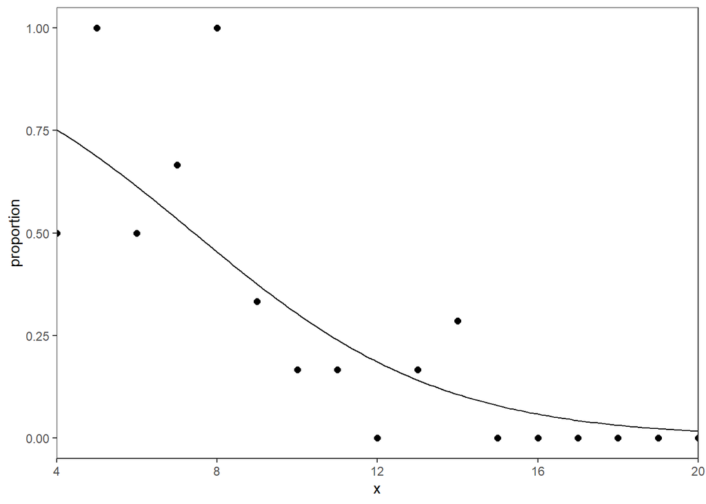

```r
ggplot(senility3, aes(x = x, y = proportion)) +
  geom_point(size=2) +
  geom_line(data=predict2, aes(x = x, y = predict)) + theme_bw() + theme(
  # Hide panel borders and remove grid lines
  #panel.border = element_line(colour = "black"),
  panel.grid.major = element_blank(),
  panel.grid.minor = element_blank(),
  # Change axis line
  #axis.line = element_line(colour = "black")
) + scale_x_continuous(limits = c(4, 20), expand = c(0, 0))
```

```r
res.glm$coefficients[1]
```

```
## (Intercept)
##    2.404043
```

```r
senility3 |>
  mutate(estimate = exp(res.glm$coefficients[1]+res.glm$coefficients[2]*x)/(1+exp(res.glm$coefficients[1]+res.glm$coefficients[2]*x))) |>
  mutate(X = (y-n*estimate)/sqrt(n*estimate*(1-estimate)))
```

```
## # A tibble: 17 × 6
##        x     y     n proportion estimate      X
##    <dbl> <dbl> <int>      <dbl>    <dbl>  <dbl>
##  1     4     1     2      0.5     0.752  -0.826
##  2     5     1     1      1       0.687   0.675
##  3     6     1     2      0.5     0.614  -0.330
##  4     7     2     3      0.667   0.535   0.458
##  5     8     2     2      1       0.454   1.55
##  6     9     2     6      0.333   0.376  -0.214
##  7    10     1     6      0.167   0.303  -0.728
##  8    11     1     6      0.167   0.240  -0.419
##  9    12     0     2      0       0.186  -0.675
## 10    13     1     6      0.167   0.142   0.176
## 11    14     2     7      0.286   0.107   1.53
## 12    15     0     3      0       0.0795 -0.509
## 13    16     0     4      0       0.0588 -0.500
## 14    17     0     1      0       0.0433 -0.213
## 15    18     0     1      0       0.0317 -0.181
## 16    19     0     1      0       0.0231 -0.154
## 17    20     0     1      0       0.0168 -0.131
```

```r
res.glm=glm(s~x,family=binomial(link="logit"),data=senility)
summary(res.glm)
```

```
##
## Call:
## glm(formula = s ~ x, family = binomial(link = "logit"), data = senility)
##
## Coefficients:
##             Estimate Std. Error z value Pr(>|z|)
## (Intercept)   2.4040     1.1918   2.017  0.04369 *
## x            -0.3235     0.1140  -2.838  0.00453 **
## ---
## Signif. codes:  0 '***' 0.001 '**' 0.01 '*' 0.05 '.' 0.1 ' ' 1
##
## (Dispersion parameter for binomial family taken to be 1)
##
##     Null deviance: 61.806  on 53  degrees of freedom
## Residual deviance: 51.017  on 52  degrees of freedom
## AIC: 55.017
##
## Number of Fisher Scoring iterations: 5
```

```r
library(doBy)
waisgrp=summaryBy(s~x,data=senility,FUN=c(sum,length))
names(waisgrp)=c('x','y','n')
waisgrp
```

```
## # A tibble: 17 × 3
##        x     y     n
##    <dbl> <dbl> <dbl>
##  1     4     1     2
##  2     5     1     1
##  3     6     1     2
##  4     7     2     3
##  5     8     2     2
##  6     9     2     6
##  7    10     1     6
##  8    11     1     6
##  9    12     0     2
## 10    13     1     6
## 11    14     2     7
## 12    15     0     3
## 13    16     0     4
## 14    17     0     1
## 15    18     0     1
## 16    19     0     1
## 17    20     0     1
```

```r
res.glm=glm(cbind(y, n-y)~x,family=binomial(link="logit"), data=waisgrp)
summary(res.glm)
```

```
##
## Call:
## glm(formula = cbind(y, n - y) ~ x, family = binomial(link = "logit"),
##     data = waisgrp)
##
## Coefficients:
##             Estimate Std. Error z value Pr(>|z|)
## (Intercept)   2.4040     1.1918   2.017  0.04369 *
## x            -0.3235     0.1140  -2.838  0.00453 **
## ---
## Signif. codes:  0 '***' 0.001 '**' 0.01 '*' 0.05 '.' 0.1 ' ' 1
##
## (Dispersion parameter for binomial family taken to be 1)
##
##     Null deviance: 20.208  on 16  degrees of freedom
## Residual deviance:  9.419  on 15  degrees of freedom
## AIC: 27.792
##
## Number of Fisher Scoring iterations: 5
```

```r
anthers
```

```
## # A tibble: 6 × 4
##       y     n storage centrifuge
##   <dbl> <dbl>   <dbl>      <dbl>
## 1    55   102       1         40
## 2    52    99       1        150
## 3    57   108       1        350
## 4    55    76       2         40
## 5    50    81       2        150
## 6    50    90       2        350
```

```r
anthers.sum <- aggregate(anthers[c("n","y")], by = anthers[c("storage")], FUN=sum)
anthers.sum
```

```
##   storage   n   y
## 1       1 309 164
## 2       2 247 155
```

```r
dput(anthers.sum)
```

```
## structure(list(storage = c(1, 2), n = c(309, 247), y = c(164,
## 155)), row.names = c(NA, -2L), class = "data.frame")
```

```r
anthers.sum <- structure(list(storage = c(1, 2), n = c(309, 247), y = c(164,
155)), row.names = c(NA, -2L), class = "data.frame")
logit_model <- glm(cbind(y, n-y) ~ storage, data=anthers.sum, family=binomial(link='logit'))
log_model <- glm(cbind(y, n-y) ~ storage, data=anthers.sum, family=binomial(link='log'))
logit_model$coefficients
```

```
## (Intercept)     storage
##  -0.2753712   0.3985039
```

```r
log_model$coefficients
```

```
## (Intercept)     storage
##  -0.8009865   0.1675116
```

```r
summary(logit_model)
```

```
##
## Call:
## glm(formula = cbind(y, n - y) ~ storage, family = binomial(link = "logit"),
##     data = anthers.sum)
##
## Coefficients:
##             Estimate Std. Error z value Pr(>|z|)
## (Intercept)  -0.2754     0.2632  -1.046   0.2955
## storage       0.3985     0.1741   2.289   0.0221 *
## ---
## Signif. codes:  0 '***' 0.001 '**' 0.01 '*' 0.05 '.' 0.1 ' ' 1
##
## (Dispersion parameter for binomial family taken to be 1)
##
##     Null deviance:  5.2790e+00  on 1  degrees of freedom
## Residual deviance: -3.7748e-14  on 0  degrees of freedom
## AIC: 16.079
##
## Number of Fisher Scoring iterations: 2
```

```r
stats::confint(logit_model)
```

```
##                   2.5 %    97.5 %
## (Intercept) -0.79161864 0.2410017
## storage      0.05841082 0.7414014
```

Newton method:

the log-likelihood function is
$$l=\sum_{i=1}^{N}\left[y_i(\beta_1+\beta_2x_i)-n_i\log\left[1+\exp(\beta_1+\beta_2x_i)\right]+\log{n_i
\choose y_i}\right]$$
the score matrix is
$$U=\left[\begin{matrix}
\frac{\partial l}{\partial\beta_1} \\ \frac{\partial l}{\partial\beta_2}
\end{matrix}\right]=\left[\begin{matrix}
\sum(y_i-n_i\pi_i) \\ \sum x_i(y_i-n_i\pi_i)
\end{matrix}\right]$$
$$\pi_i=\frac{\exp(\beta_1+\beta_2x_i)}{1+\exp(\beta_1+\beta_2x_i)}$$

the information matrix is

$$J=\left[\begin{matrix}
\sum n_i\pi_i(1-\pi_i) & \sum n_ix_i\pi_i(1-\pi_i) \\ \sum
n_ix_i\pi_i(1-\pi_i) & \sum n_ix_i^2\pi_i(1-\pi_i)
\end{matrix}\right]$$

The iteration is :

$$J^{(m-1)} b^m=J^{(m-1)}
b^{(m-1)}+U^{(m-1)}$$

For a log-likelihood function of a single parameter $\beta$ , the first three terms of the Taylor series approximation near an estimate $b$ are

$$\begin{align}l(\beta)&\approx
l(b)+(\beta-b)U(b)+\frac{1}{2}(\beta-b)^2U'(b)\\
&=l(b)+(\beta-b)U(b)-\frac{1}{2}(\beta-b)^2J(b)\\
&=-\frac{1}{2}(\beta-b)^2J(b)
\end{align}$$
when $U(b)$ is the maximum likelihood estimate, $U(b)=0$ Then
$$l(\beta)-l(b)=-\frac{1}{2}(\beta-b)^2J(b)$$
and because
$$\mathbb
E[(b-\beta)(b-\beta)^T]=J^{-1}\mathbb E(UU^T)J^{-1}=J^{-1}$$
because
$$J=\mathbb E(UU^T)$$
then
$$2[l(\beta)-l(b)]=(b-\beta)^2J(b)\sim
\chi^2(p)$$

For the one-parameter case,
$$b\sim
N(\beta, J^{-1})$$

```r
X <- matrix(c(1,1,1,2), ncol=2,
            byrow = TRUE)
B=matrix(c(0, 0), ncol = 1, byrow = FALSE)
n <- anthers.sum$n
y <- anthers.sum$y
x <- anthers.sum$storage
for(i in seq(1:6)){
  pii = exp(X %*% B)/(1+exp(X %*% B))
  npi1_pi = n*pii*(1-pii)
  U=matrix(c(sum(y-n*pii),
             sum((y-n*pii)*x)),
           ncol = 1, byrow = FALSE)
  J=matrix(c(sum(npi1_pi),
             sum(npi1_pi*x),
             sum(npi1_pi*x),
             sum(npi1_pi*x*x)),
           ncol=2,
           byrow = TRUE)
  J_1 = solve(J)
  B=J_1 %*% (crossprod(J, B)+U)
  print(paste0("iter: ", i))
  print("coefficients:")
  print(B)
  print("variances:")
  print(diag(J_1))
  print("std.error:")
  print(sqrt(diag(J_1)))
  writeLines("\n")
}
```

```
## [1] "iter: 1"
## [1] "coefficients:"
##            [,1]
## [1,] -0.2641668
## [2,]  0.3871441
## [1] "variances:"
## [1] 0.06797427 0.02913932
## [1] "std.error:"
## [1] 0.2607188 0.1707024
##
##
## [1] "iter: 2"
## [1] "coefficients:"
##            [,1]
## [1,] -0.2753545
```

[output cut: 49 more lines]

```r
#pi_hat
fitted.values(logit_model)
```

```
##         1         2
## 0.5307443 0.6275304
```

```r
#linear values
predict(logit_model)
```

```
##         1         2
## 0.1231327 0.5216365
```

```r
#pi_hat
exp(predict(logit_model))/(1+exp(predict(logit_model)))
```

```
##         1         2
## 0.5307443 0.6275304
```

```r
x <- anthers.sum$storage
#Logit model odds ratios Constant
exp(coefficients(summary(logit_model))["(Intercept)",1]+coefficients(summary(logit_model))["storage",1]*x[1])
```

```
## [1] 1.131034
```

```r
#Logit model odds ratios Treatment vs. control
exp(coefficients(summary(logit_model))["storage",1]*(x[2]-x[1]))
```

```
## [1] 1.489594
```

```r
questionr::odds.ratio(logit_model, level=0.95)
```

```
##                  OR   2.5 % 97.5 %       p
## (Intercept) 0.75929 0.45311 1.2725 0.29553
## storage     1.48959 1.06015 2.0989 0.02209 *
## ---
## Signif. codes:  0 '***' 0.001 '**' 0.01 '*' 0.05 '.' 0.1 ' ' 1
```

```r
coefficients(summary(logit_model))
```

```
##               Estimate Std. Error   z value   Pr(>|z|)
## (Intercept) -0.2753712  0.2632444 -1.046066 0.29553034
## storage      0.3985039  0.1741129  2.288767 0.02209287
```

```r
#95% CI of constant
exp(coefficients(summary(logit_model))["(Intercept)",1]+qnorm(c(0.025,0.975))*coefficients(summary(logit_model))["(Intercept)",2])
```

```
## [1] 0.4532458 1.2719847
```

```r
#95% CI of treatment vs constant
exp(coefficients(summary(logit_model))["storage",1]+qnorm(c(0.025,0.975))*coefficients(summary(logit_model))["storage",2])
```

```
## [1] 1.058919 2.095430
```

```r
#Exercises 7.1
hiroshima
```

```
## # A tibble: 6 × 4
##   radiation  leukemia `other cancer` `total cancers`
##   <chr>         <dbl>          <dbl>           <dbl>
## 1 0                13            378             391
## 2 1 to 9            5            200             205
## 3 10 to 49          5            151             156
## 4 50 to 99          3             47              50
## 5 100 to 199        4             31              35
## 6 200 +            18             33              51
```

```r
hiroshima2 <- hiroshima |> mutate(dosage=as.integer(str_split(hiroshima$radiation, " ") |> map_chr(\(x) x[1])))
hiroshima2
```

```
## # A tibble: 6 × 5
##   radiation  leukemia `other cancer` `total cancers` dosage
##   <chr>         <dbl>          <dbl>           <dbl>  <int>
## 1 0                13            378             391      0
## 2 1 to 9            5            200             205      1
## 3 10 to 49          5            151             156     10
## 4 50 to 99          3             47              50     50
## 5 100 to 199        4             31              35    100
## 6 200 +            18             33              51    200
```

```r
model.hiroshima <- glm(cbind(leukemia, `other cancer`) ~ dosage, data=hiroshima2, family=binomial(link='logit'))
summary(model.hiroshima)
```

```
##
## Call:
## glm(formula = cbind(leukemia, `other cancer`) ~ dosage, family = binomial(link = "logit"),
##     data = hiroshima2)
##
## Coefficients:
##              Estimate Std. Error z value Pr(>|z|)
## (Intercept) -3.488973   0.204062 -17.098  < 2e-16 ***
## dosage       0.014410   0.001817   7.932 2.15e-15 ***
## ---
## Signif. codes:  0 '***' 0.001 '**' 0.01 '*' 0.05 '.' 0.1 ' ' 1
##
## (Dispersion parameter for binomial family taken to be 1)
##
##     Null deviance: 54.35089  on 5  degrees of freedom
## Residual deviance:  0.43206  on 4  degrees of freedom
## AIC: 26.097
##
## Number of Fisher Scoring iterations: 4
```

```r
n_total <- hiroshima2$`total cancers`
observed <- hiroshima2$leukemia
predict(model.hiroshima)
```

```
##          1          2          3          4          5          6
## -3.4889730 -3.4745628 -3.3448706 -2.7684611 -2.0479491 -0.6069252
```

```r
fitted.values(model.hiroshima)*n_total
```

```
##         1         2         3         4         5         6
## 11.584398  6.159169  5.313911  2.952623  3.999092 17.990807
```

```r
exp(predict(model.hiroshima))*n_total/(1+exp(predict(model.hiroshima)))
```

```
##         1         2         3         4         5         6
## 11.584398  6.159169  5.313911  2.952623  3.999092 17.990807
```

```r
estimated <- fitted.values(model.hiroshima)*n_total
```

```r
hiroshima2 <- hiroshima2 |> mutate(OL=observed,
                     OO=n_total-observed,
                     EL=estimated,
                     EO=n_total-estimated)
hiroshima2
```

```
## # A tibble: 6 × 9
##   radiation  leukemia `other cancer` `total cancers` dosage    OL    OO    EL
##   <chr>         <dbl>          <dbl>           <dbl>  <int> <dbl> <dbl> <dbl>
## 1 0                13            378             391      0    13   378 11.6
## 2 1 to 9            5            200             205      1     5   200  6.16
## 3 10 to 49          5            151             156     10     5   151  5.31
## 4 50 to 99          3             47              50     50     3    47  2.95
## 5 100 to 199        4             31              35    100     4    31  4.00
## 6 200 +            18             33              51    200    18    33 18.0
## # ℹ 1 more variable: EO <dbl>
```

```r
hiroshima2[hiroshima2$dosage == 0,]
```

```
## # A tibble: 1 × 9
##   radiation leukemia `other cancer` `total cancers` dosage    OL    OO    EL
##   <chr>        <dbl>          <dbl>           <dbl>  <int> <dbl> <dbl> <dbl>
## 1 0               13            378             391      0    13   378  11.6
## # ℹ 1 more variable: EO <dbl>
```

```r
hiroshima2[hiroshima2$dosage > 0 & hiroshima2$dosage <= 50,]
```

```
## # A tibble: 3 × 9
##   radiation leukemia `other cancer` `total cancers` dosage    OL    OO    EL
##   <chr>        <dbl>          <dbl>           <dbl>  <int> <dbl> <dbl> <dbl>
## 1 1 to 9           5            200             205      1     5   200  6.16
## 2 10 to 49         5            151             156     10     5   151  5.31
## 3 50 to 99         3             47              50     50     3    47  2.95
## # ℹ 1 more variable: EO <dbl>
```

```r
hiroshima2[hiroshima2$dosage > 50,]
```

```
## # A tibble: 2 × 9
##   radiation  leukemia `other cancer` `total cancers` dosage    OL    OO    EL
##   <chr>         <dbl>          <dbl>           <dbl>  <int> <dbl> <dbl> <dbl>
## 1 100 to 199        4             31              35    100     4    31  4.00
## 2 200 +            18             33              51    200    18    33 18.0
## # ℹ 1 more variable: EO <dbl>
```

```r
hiroshima2[hiroshima2$dosage == 0,] |> summarize(across(6:9, sum)) |> as.data.frame()
```

```
##   OL  OO      EL       EO
## 1 13 378 11.5844 379.4156
```

```r
hiroshima2[hiroshima2$dosage > 0 & hiroshima2$dosage <= 50,] |> summarize(across(6:9, sum)) |> as.data.frame()
```

```
##   OL  OO      EL       EO
## 1 13 398 14.4257 396.5743
```

```r
hiroshima2[hiroshima2$dosage > 50,] |> summarize(across(6:9, sum)) |> as.data.frame()
```

```
##   OL OO      EL      EO
## 1 22 64 21.9899 64.0101
```

```r
#XHL^2
X_HL <- sum(c((13-11.5844)^2/11.5844,
                (378-379.4156)^2/379.4156,
                (13-14.4257)^2/14.4257,
                (398-396.5743)^2/396.5743,
                (22-21.9899)^2/21.9899,
                (64-64.0101)^2/64.0101
                ))
X_HL
```

```
## [1] 0.3243007
```

```r
1-pchisq(X_HL, df=1)
```

```
## [1] 0.5690345
```

```r
#Exercises 7.3
graduates
```

```
## # A tibble: 60 × 5
##     year survive total faculty  sex
##    <dbl> <chr>   <chr> <chr>    <chr>
##  1  1938 18      22    medicine men
##  2  1939 16      23    medicine men
##  3  1940 7       17    medicine men
##  4  1941 12      25    medicine men
##  5  1942 24      50    medicine men
##  6  1943 16      21    medicine men
##  7  1944 22      32    medicine men
##  8  1945 12      14    medicine men
##  9  1946 22      34    medicine men
## 10  1947 28      37    medicine men
## 11  1938 16      30    arts     men
## 12  1939 13      22    arts     men
## 13  1940 11      25    arts     men
## 14  1941 12      14    arts     men
## 15  1942 8       12    arts     men
## 16  1943 11      20    arts     men
## 17  1944 4       10    arts     men
## 18  1945 4       12    arts     men
## 19  1946 *       *     arts     men
## 20  1947 13      23    arts     men
## 21  1938 9       14    science  men
## 22  1939 9       12    science  men
## 23  1940 12      19    science  men
## 24  1941 12      15    science  men
## 25  1942 20      28    science  men
## # ℹ 35 more rows
```

```r
graduates$survive = as.numeric(graduates$survive)
graduates$total = as.numeric(graduates$total)
graduates
```

```
## # A tibble: 60 × 5
##     year survive total faculty  sex
##    <dbl>   <dbl> <dbl> <chr>    <chr>
##  1  1938      18    22 medicine men
##  2  1939      16    23 medicine men
##  3  1940       7    17 medicine men
##  4  1941      12    25 medicine men
##  5  1942      24    50 medicine men
##  6  1943      16    21 medicine men
##  7  1944      22    32 medicine men
##  8  1945      12    14 medicine men
##  9  1946      22    34 medicine men
## 10  1947      28    37 medicine men
## 11  1938      16    30 arts     men
## 12  1939      13    22 arts     men
## 13  1940      11    25 arts     men
## 14  1941      12    14 arts     men
## 15  1942       8    12 arts     men
## 16  1943      11    20 arts     men
## 17  1944       4    10 arts     men
## 18  1945       4    12 arts     men
## 19  1946      NA    NA arts     men
## 20  1947      13    23 arts     men
## 21  1938       9    14 science  men
## 22  1939       9    12 science  men
## 23  1940      12    19 science  men
## 24  1941      12    15 science  men
## 25  1942      20    28 science  men
## # ℹ 35 more rows
```

```r
aggregate(graduates[c("survive","total")], by = graduates[c("sex")], FUN=sum, na.rm = TRUE) |> mutate(ratio=survive/total)
```

```
##     sex survive total     ratio
## 1   men     536   799 0.6708385
## 2 women     184   218 0.8440367
```

```r
graduates$year <- factor(graduates$year)
model.graduates <- glm(cbind(survive, total-survive) ~ year, data=graduates, family=binomial(link='logit'),
                       na.action = na.omit)
summary(model.graduates)
```

```
##
## Call:
## glm(formula = cbind(survive, total - survive) ~ year, family = binomial(link = "logit"),
##     data = graduates, na.action = na.omit)
##
## Coefficients:
##             Estimate Std. Error z value Pr(>|z|)
## (Intercept)  0.69315    0.21004   3.300 0.000967 ***
## year1939     0.06899    0.31064   0.222 0.824238
## year1940    -0.18760    0.29378  -0.639 0.523103
## year1941     0.21511    0.31662   0.679 0.496882
## year1942    -0.17261    0.28810  -0.599 0.549076
## year1943     0.43672    0.32729   1.334 0.182096
## year1944     0.34093    0.29407   1.159 0.246323
## year1945     0.62614    0.30175   2.075 0.037988 *
## year1946     0.07411    0.39592   0.187 0.851521
## year1947     0.40547    0.28143   1.441 0.149667
## ---
## Signif. codes:  0 '***' 0.001 '**' 0.01 '*' 0.05 '.' 0.1 ' ' 1
##
## (Dispersion parameter for binomial family taken to be 1)
##
##     Null deviance: 116.09  on 57  degrees of freedom
## Residual deviance: 101.04  on 48  degrees of freedom
##   (2 observations deleted due to missingness)
## AIC: 269.78
##
## Number of Fisher Scoring iterations: 4
```

```r
graduates$sex <- factor(graduates$sex)
graduates$faculty <- factor(graduates$faculty)
model.graduates2 <- glm(cbind(survive, total-survive) ~ faculty,
                       data=graduates, family=binomial(link='logit'),
                       na.action = na.omit)
summary(model.graduates2)
```

```
##
## Call:
## glm(formula = cbind(survive, total - survive) ~ faculty, family = binomial(link = "logit"),
##     data = graduates, na.action = na.omit)
##
## Coefficients:
##                    Estimate Std. Error z value Pr(>|z|)
## (Intercept)          0.7117     0.1180   6.029 1.65e-09 ***
## facultyengineering   0.2595     0.2220   1.169  0.24243
## facultymedicine     -0.1205     0.1726  -0.698  0.48511
## facultyscience       0.7207     0.1931   3.731  0.00019 ***
## ---
## Signif. codes:  0 '***' 0.001 '**' 0.01 '*' 0.05 '.' 0.1 ' ' 1
##
## (Dispersion parameter for binomial family taken to be 1)
##
##     Null deviance: 116.086  on 57  degrees of freedom
## Residual deviance:  94.225  on 54  degrees of freedom
##   (2 observations deleted due to missingness)
## AIC: 250.96
##
## Number of Fisher Scoring iterations: 4
```

```r
model.graduates.sex <- glm(cbind(survive, total-survive) ~ sex,
                       data=graduates, family=binomial(link='logit'),
                       na.action = na.omit)
summary(model.graduates.sex)
```

```
##
## Call:
## glm(formula = cbind(survive, total - survive) ~ sex, family = binomial(link = "logit"),
##     data = graduates, na.action = na.omit)
##
## Coefficients:
##             Estimate Std. Error z value Pr(>|z|)
## (Intercept)  0.71198    0.07529   9.457  < 2e-16 ***
## sexwomen     0.97660    0.20128   4.852 1.22e-06 ***
## ---
## Signif. codes:  0 '***' 0.001 '**' 0.01 '*' 0.05 '.' 0.1 ' ' 1
##
## (Dispersion parameter for binomial family taken to be 1)
##
##     Null deviance: 116.09  on 57  degrees of freedom
## Residual deviance:  88.84  on 56  degrees of freedom
##   (2 observations deleted due to missingness)
## AIC: 241.58
##
## Number of Fisher Scoring iterations: 4
```

```r
model.graduates.interact <- glm(cbind(survive, total-survive) ~ faculty*sex,
                       data=graduates, family=binomial(link='logit'),
                       na.action = na.omit)
summary(model.graduates.interact)
```

```
##
## Call:
## glm(formula = cbind(survive, total - survive) ~ faculty * sex,
##     family = binomial(link = "logit"), data = graduates, na.action = na.omit)
##
## Coefficients: (2 not defined because of singularities)
##                             Estimate Std. Error z value Pr(>|z|)
## (Intercept)                   0.1911     0.1550   1.233  0.21774
## facultyengineering            0.7801     0.2437   3.201  0.00137 **
## facultymedicine               0.4001     0.1997   2.004  0.04511 *
## facultyscience                0.9968     0.2239   4.452 8.50e-06 ***
## sexwomen                      1.2112     0.2534   4.780 1.76e-06 ***
## facultyengineering:sexwomen       NA         NA      NA       NA
## facultymedicine:sexwomen          NA         NA      NA       NA
## facultyscience:sexwomen       0.5627     0.6640   0.848  0.39671
## ---
## Signif. codes:  0 '***' 0.001 '**' 0.01 '*' 0.05 '.' 0.1 ' ' 1
##
## (Dispersion parameter for binomial family taken to be 1)
##
##     Null deviance: 116.086  on 57  degrees of freedom
## Residual deviance:  56.765  on 52  degrees of freedom
##   (2 observations deleted due to missingness)
## AIC: 217.5
##
## Number of Fisher Scoring iterations: 5
```

```r
women <- graduates[graduates$sex == "women",]
men <- graduates[graduates$sex == "men",]
model.graduates.women <- glm(cbind(survive, total-survive) ~ faculty,
                       data=women, family=binomial(link='logit'),
                       na.action = na.omit)
summary(model.graduates.women)
```

```
##
## Call:
## glm(formula = cbind(survive, total - survive) ~ faculty, family = binomial(link = "logit"),
##     data = women, na.action = na.omit)
##
## Coefficients:
##                Estimate Std. Error z value Pr(>|z|)
## (Intercept)      1.4023     0.2005   6.994 2.66e-12 ***
## facultyscience   1.5595     0.6251   2.495   0.0126 *
## ---
## Signif. codes:  0 '***' 0.001 '**' 0.01 '*' 0.05 '.' 0.1 ' ' 1
##
## (Dispersion parameter for binomial family taken to be 1)
##
##     Null deviance: 22.555  on 19  degrees of freedom
## Residual deviance: 13.739  on 18  degrees of freedom
## AIC: 46.642
##
## Number of Fisher Scoring iterations: 5
```

```r
model.graduates.men <- glm(cbind(survive, total-survive) ~ faculty,
                       data=men, family=binomial(link='logit'),
                       na.action = na.omit)
summary(model.graduates.men)
```

```
##
## Call:
## glm(formula = cbind(survive, total - survive) ~ faculty, family = binomial(link = "logit"),
##     data = men, na.action = na.omit)
##
## Coefficients:
##                    Estimate Std. Error z value Pr(>|z|)
## (Intercept)          0.1911     0.1550   1.233  0.21774
## facultyengineering   0.7801     0.2437   3.201  0.00137 **
## facultymedicine      0.4001     0.1997   2.004  0.04511 *
## facultyscience       0.9968     0.2239   4.452  8.5e-06 ***
## ---
## Signif. codes:  0 '***' 0.001 '**' 0.01 '*' 0.05 '.' 0.1 ' ' 1
##
## (Dispersion parameter for binomial family taken to be 1)
##
##     Null deviance: 66.285  on 37  degrees of freedom
## Residual deviance: 43.026  on 34  degrees of freedom
##   (2 observations deleted due to missingness)
## AIC: 170.86
##
## Number of Fisher Scoring iterations: 4
```

## Chapter8 Nominal and Ordinal Logistic Regression

### 8.2 Multinomial distribution

If $(X_1,\cdots, X_n)$ is a vector with multinomial distribution, proof that $\text{Cov}(X_i,X_j)=-rp_ip_j$, $i\neq j$ where $r$ is the number of trials of the experiment, $p_i$ is the probability of success for the variable $X_i$.
$$fdp=f(x_1,...x_n)={r!\over{x_1!x_2!\cdots
x_n!}}p_1^{x_1}\cdots p_n^{x_n}$$
if $x_1+x_2+\cdots +x_n=r$

We can use indicator random variables to help simplify the covariance expression. We can interpret the problem as $r$ independent rolls of an $n$ sided die. Let $X_i$ be the number of rolls that result in side $i$ facing up, and let $I_{k}^{(i)}$ be an indicator equal to $1$ when roll $k$ is equal to $i$ and $0$ otherwise. Then, we can express $X_i$ and $X_j$ as follows:

$$\begin{equation}
X_i = \sum_{k=1}^{r} I_{k}^{(i)}~~~\mathrm{and}~~~X_j = \sum_{k=1}^{r}
I_{k}^{(j)}
\end{equation}$$

Let’s re-write the covariance using indicators:
$$\begin{equation}
\mathrm{Cov}(X_i,X_j) = E[X_i X_j] - E[X_i]E[X_j]
\end{equation}$$
Let’s compute the first term:
$$\begin{eqnarray}
E[X_i X_j] &=& E\bigg[(\sum_{k=1}^{r}I_{k}^{(i)})
(\sum_{l=1}^{r}I_{l}^{(j)})\bigg] =
\sum_{k=l}E\big[I_{k}^{(i)}I_{l}^{(j)}\big] + \sum_{k\neq
l}E\big[I_{k}^{(i)}I_{l}^{(j)}\big] = \\
&=& 0 + \sum_{k\neq l}E\big[I_{k}^{(i)}\big]
E\big[I_{l}^{(j)}\big] = \sum_{k\neq l} p_i p_j = (r^2 - r)p_i p_j
\end{eqnarray}$$
where we expanded the product of sums, used linearity of expectation and the fact that when $k=l$ we can’t simultaneously roll $i$ and $j$ on the same trial $k=l$ (making the product of indicators zero) Finally we applied independence of rolls that enabled us to write it as a product of probabilities. Let’s compute the remaining term:
$$\begin{equation}
E[X_i] = E[\sum_{k=1}^{r}I_{k}^{(i)}] = \sum_{k=1}^{r}E[I_{k}^{(i)}] =
rp_i
\end{equation}$$
Therefore, the covariance equals:
$$\begin{equation}
\mathrm{Cov}(X_i,X_j) = E[X_i X_j] - E[X_i]E[X_j] = (r^2-r)p_ip_j -
r^2p_ip_j = -r p_i p_j
\end{equation}$$
Notice that $\mathrm{Cov}(X_i, X_j) = -r p_i p_j < 0$ is negative, this makes sense intuitively since for a fixed number of rolls $r$, if we roll many outcomes $i$, this reduces the number of possible outcomes $j$, and therefore $X_i$ and $X_j$ are negatively correlated! [reference](https://math.stackexchange.com/questions/1669513/find-the-covariances-of-a-multinomial-distribution)

```r
Cars
```

```
## # A tibble: 18 × 4
##    sex   age   response       frequency
##    <chr> <chr> <chr>              <dbl>
##  1 women 18-23 no/little             26
##  2 women 18-23 important             12
##  3 women 18-23 very important         7
##  4 women 24-40 no/little              9
##  5 women 24-40 important             21
##  6 women 24-40 very important        15
##  7 women > 40  no/little              5
##  8 women > 40  important             14
##  9 women > 40  very important        41
## 10 men   18-23 no/little             40
## 11 men   18-23 important             17
## 12 men   18-23 very important         8
## 13 men   24-40 no/little             17
## 14 men   24-40 important             15
## 15 men   24-40 very important        12
## 16 men   > 40  no/little              8
## 17 men   > 40  important             15
## 18 men   > 40  very important        18
```

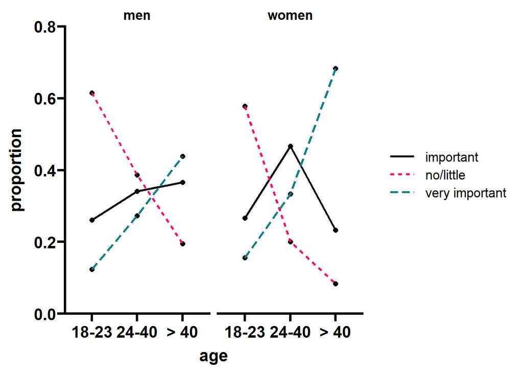

```r
#Figure 8.1
library(tidyverse)
library(ggprism)
Cars |> group_by(sex, age) |> mutate(
    age = factor(age, levels = c("18-23", "24-40", "> 40")),
    proportion = frequency/sum(frequency)
  ) |> ggplot(aes(x = age, y = proportion, group = response)) +
  geom_point(size=2) +
  geom_line(aes(color = response, linetype = response), size=1) +
  facet_wrap(~sex) + theme_bw() + theme(
  # Hide panel borders and remove grid lines
  #panel.border = element_line(colour = "black"),
  panel.grid.major = element_blank(),
  panel.grid.minor = element_blank(),
  # Change axis line
  #axis.line = element_line(colour = "black")
) + scale_y_continuous(limits = c(0, 0.8), expand = c(0, 0)) +
  theme_prism(palette = "black_and_white", base_size = 16) +
  scale_colour_prism(palette = "colorblind_safe")
```

```r
factor(Cars$age)
```

```
##  [1] 18-23 18-23 18-23 24-40 24-40 24-40 > 40  > 40  > 40  18-23 18-23 18-23
## [13] 24-40 24-40 24-40 > 40  > 40  > 40
## Levels: > 40 18-23 24-40
```

```r
factor(Cars$sex)
```

```
##  [1] women women women women women women women women women men   men   men
## [13] men   men   men   men   men   men
## Levels: men women
```

```r
factor(Cars$response)
```

```
##  [1] no/little      important      very important no/little      important
##  [6] very important no/little      important      very important no/little
## [11] important      very important no/little      important      very important
## [16] no/little      important      very important
## Levels: important no/little very important
```

```r
library(nnet)
Cars2 <- Cars |> group_by(sex, age) |> mutate(
    age = factor(age, levels = c("18-23", "24-40", "> 40")),
    sex = factor(sex, levels = c("women", "men")),
    response = factor(response, levels = c("no/little", "important", "very important"))
)

res.cars=multinom(response~age+sex, weights=frequency,data=Cars2)
summary(res.cars)
```

```
## Call:
## multinom(formula = response ~ age + sex, data = Cars2, weights = frequency)
##
## Coefficients:
##                (Intercept) age24-40  age> 40     sexmen
## important       -0.5907992 1.128268 1.587709 -0.3881301
## very important  -1.0390726 1.478104 2.916757 -0.8130202
##
## Std. Errors:
##                (Intercept)  age24-40   age> 40    sexmen
## important        0.2839756 0.3416449 0.4028997 0.3005115
## very important   0.3305014 0.4009256 0.4229276 0.3210382
##
## Residual Deviance: 580.7022
## AIC: 596.7022
```

```r
summary(res.cars)$coefficients
```

```
##                (Intercept) age24-40  age> 40     sexmen
## important       -0.5907992 1.128268 1.587709 -0.3881301
## very important  -1.0390726 1.478104 2.916757 -0.8130202
```

```r
summary(res.cars)$standard.errors
```

```
##                (Intercept)  age24-40   age> 40    sexmen
## important        0.2839756 0.3416449 0.4028997 0.3005115
## very important   0.3305014 0.4009256 0.4229276 0.3210382
```

```r
#Odds ratio
exp(summary(res.cars)$coefficients)
```

```
##                (Intercept) age24-40   age> 40    sexmen
## important        0.5538844 3.090300  4.892529 0.6783241
## very important   0.3537826 4.384626 18.481251 0.4435165
```

```r
#95% CI
exp(summary(res.cars)$coefficients+qnorm(0.025)*summary(res.cars)$standard.errors)
```

```
##                (Intercept) age24-40  age> 40    sexmen
## important        0.3174671 1.581947 2.221184 0.3763929
## very important   0.1851029 1.998316 8.067421 0.2363968
```

```r
exp(summary(res.cars)$coefficients+qnorm(0.975)*summary(res.cars)$standard.errors)
```

```
##                (Intercept) age24-40  age> 40    sexmen
## important        0.9663615 6.036836 10.77661 1.2224555
## very important   0.6761761 9.620575 42.33777 0.8321049
```

```r
#(95% confidence interval)
exp(summary(res.cars)$coefficients - summary(res.cars)$standard.errors * 1.96)
```

```
##                (Intercept) age24-40  age> 40    sexmen
## important        0.3174638 1.581928 2.221152 0.3763888
## very important   0.1851007 1.998287 8.067298 0.2363941
```

```r
exp(summary(res.cars)$coefficients + summary(res.cars)$standard.errors * 1.96)
```

```
##                (Intercept) age24-40  age> 40    sexmen
## important        0.9663714 6.036910 10.77677 1.2224687
## very important   0.6761841 9.620714 42.33842 0.8321145
```

```r
logLik(res.cars)
```

```
## 'log Lik.' -290.3511 (df=8)
```

```r
#minimal model
res.cars.mini=multinom(response~1, weights=frequency,data=Cars2)
summary(res.cars.mini)
```

```
## Call:
## multinom(formula = response ~ 1, data = Cars2, weights = frequency)
##
## Coefficients:
##                (Intercept)
## important      -0.11066559
## very important -0.03883986
##
## Std. Errors:
##                (Intercept)
## important        0.1419933
## very important   0.1393729
##
## Residual Deviance: 658.544
## AIC: 662.544
```

```r
logLik(res.cars.mini)
```

```
## 'log Lik.' -329.272 (df=2)
```

```r
# the likelihood ratio chi-squared statistic C
2*(c(logLik(res.cars) - logLik(res.cars.mini)))
```

```
## [1] 77.84185
```

```r
#degrees of freedom
8-2
```

```
## [1] 6
```

```r
#p value with chisq(6)
1-pchisq(2*(c(logLik(res.cars) - logLik(res.cars.mini))), df=6)
```

```
## [1] 9.992007e-15
```

```r
#pseudo R^2

c((logLik(res.cars.mini) - logLik(res.cars))/logLik(res.cars.mini))
```

```
## [1] 0.118203
```

```r
#AIC
res.cars$AIC
```

```
## [1] 596.7022
```

```r
-2* logLik(res.cars)+2*res.cars$edf
```

```
## 'log Lik.' 596.7022 (df=8)
```

```r
attr(logLik(res.cars), "df")
```

```
## [1] 8
```

```r
#coefficients
coef(res.cars)
```

```
##                (Intercept) age24-40  age> 40     sexmen
## important       -0.5907992 1.128268 1.587709 -0.3881301
## very important  -1.0390726 1.478104 2.916757 -0.8130202
```

```r
#fitted values
fitted(res.cars)
```

```
##     no/little important very important
## 1  0.52420049 0.2903465      0.1854530
## 2  0.52420049 0.2903465      0.1854530
## 3  0.52420049 0.2903465      0.1854530
## 4  0.23458355 0.4015294      0.3638870
## 5  0.23458355 0.4015294      0.3638870
## 6  0.23458355 0.4015294      0.3638870
## 7  0.09757772 0.2644254      0.6379968
## 8  0.09757772 0.2644254      0.6379968
## 9  0.09757772 0.2644254      0.6379968
## 10 0.65247678 0.2451441      0.1023791
## 11 0.65247678 0.2451441      0.1023791
## 12 0.65247678 0.2451441      0.1023791
## 13 0.35099404 0.4075274      0.2414786
## 14 0.35099404 0.4075274      0.2414786
## 15 0.35099404 0.4075274      0.2414786
## 16 0.17427519 0.3203504      0.5053744
## 17 0.17427519 0.3203504      0.5053744
## 18 0.17427519 0.3203504      0.5053744
```

```r
#Table 8.3
fitted(res.cars) |> bind_cols(Obs.freq = Cars2$frequency,
                              sex = Cars2$sex,
                              age = Cars2$age) |>
  group_by(sex, age) |>
  mutate(group.total = sum(Obs.freq)) |>
  mutate(fitted.no.little = `no/little`*group.total,
         fitted.important = important*group.total,
         fitted.very.important = `very important`*group.total,
         residual.no.little = (Obs.freq-fitted.no.little)/sqrt(fitted.no.little),
         residual.important = (Obs.freq-fitted.important)/sqrt(fitted.important),
         residual.very.important = (Obs.freq-fitted.very.important)/sqrt(fitted.very.important)
         ) |> as.data.frame()
```

```
##     no/little important very important Obs.freq   sex   age group.total
## 1  0.52420049 0.2903465      0.1854530       26 women 18-23          45
## 2  0.52420049 0.2903465      0.1854530       12 women 18-23          45
## 3  0.52420049 0.2903465      0.1854530        7 women 18-23          45
## 4  0.23458355 0.4015294      0.3638870        9 women 24-40          45
## 5  0.23458355 0.4015294      0.3638870       21 women 24-40          45
## 6  0.23458355 0.4015294      0.3638870       15 women 24-40          45
## 7  0.09757772 0.2644254      0.6379968        5 women  > 40          60
## 8  0.09757772 0.2644254      0.6379968       14 women  > 40          60
## 9  0.09757772 0.2644254      0.6379968       41 women  > 40          60
## 10 0.65247678 0.2451441      0.1023791       40   men 18-23          65
## 11 0.65247678 0.2451441      0.1023791       17   men 18-23          65
## 12 0.65247678 0.2451441      0.1023791        8   men 18-23          65
## 13 0.35099404 0.4075274      0.2414786       17   men 24-40          44
## 14 0.35099404 0.4075274      0.2414786       15   men 24-40          44
```

[output cut: 42 more lines]

```r
#Table 8.3
options(paged.print = FALSE,
        pillar.print_max = 25,
        pillar.print_min = 25)
fitted(res.cars) |> as_tibble() |> distinct(.keep_all = TRUE)|> pivot_longer(
    cols = c('no/little', 'important', 'very important'),
    names_to = "Importance.Rating",
    values_to = "Estimated.probability"
  ) |> bind_cols(Obs.freq = Cars2$frequency,
                              sex = Cars2$sex,
                              age = Cars2$age) |>
  group_by(sex, age) |>
  mutate(group.total = sum(Obs.freq)) |>
  mutate(fitted.value = Estimated.probability*group.total,
         Pearson.residual = (Obs.freq-fitted.value)/sqrt(fitted.value)
         )
```

```
## # A tibble: 18 × 8
## # Groups:   sex, age [6]
##    Importance.Rating Estimated.probability Obs.freq sex   age   group.total
##    <chr>                             <dbl>    <dbl> <fct> <fct>       <dbl>
##  1 no/little                        0.524        26 women 18-23          45
##  2 important                        0.290        12 women 18-23          45
##  3 very important                   0.185         7 women 18-23          45
##  4 no/little                        0.235         9 women 24-40          45
##  5 important                        0.402        21 women 24-40          45
##  6 very important                   0.364        15 women 24-40          45
##  7 no/little                        0.0976        5 women > 40           60
##  8 important                        0.264        14 women > 40           60
##  9 very important                   0.638        41 women > 40           60
## 10 no/little                        0.652        40 men   18-23          65
## 11 important                        0.245        17 men   18-23          65
## 12 very important                   0.102         8 men   18-23          65
## 13 no/little                        0.351        17 men   24-40          44
## 14 important                        0.408        15 men   24-40          44
## 15 very important                   0.241        12 men   24-40          44
## 16 no/little                        0.174         8 men   > 40           41
## 17 important                        0.320        15 men   > 40           41
## 18 very important                   0.505        18 men   > 40           41
## # ℹ 2 more variables: fitted.value <dbl>, Pearson.residual <dbl>
```

```r
sum.squared.residuals <- fitted(res.cars) |> as_tibble() |> distinct(.keep_all = TRUE)|> pivot_longer(
    cols = c('no/little', 'important', 'very important'),
    names_to = "Importance.Rating",
    values_to = "Estimated.probability"
  ) |> bind_cols(Obs.freq = Cars2$frequency,
                              sex = Cars2$sex,
                              age = Cars2$age) |>
  group_by(sex, age) |>
  mutate(group.total = sum(Obs.freq)) |>
  mutate(fitted.value = Estimated.probability*group.total,
         Pearson.residual = (Obs.freq-fitted.value)/sqrt(fitted.value)
         ) |> ungroup() |>
  summarize(sum(Pearson.residual^2))
sum.squared.residuals
```

```
## # A tibble: 1 × 1
##   `sum(Pearson.residual^2)`
##                       <dbl>
## 1                      3.93
```

```r
res.cars.max=multinom(response~age+sex+age*sex, weights=frequency,data=Cars2)
res.cars.max
```

```
## Call:
## multinom(formula = response ~ age + sex + age * sex, data = Cars2,
##     weights = frequency)
##
## Coefficients:
##                (Intercept) age24-40  age> 40      sexmen age24-40:sexmen
## important       -0.7731881 1.620480 1.802883 -0.08249128      -0.8899378
## very important  -1.3121701 1.822993 3.416376 -0.29728385      -0.5618162
##                age> 40:sexmen
## important          -0.3185948
## very important     -0.9959994
##
## Residual Deviance: 576.7635
## AIC: 600.7635
```

```r
summary(res.cars.max)
```

```
## Call:
## multinom(formula = response ~ age + sex + age * sex, data = Cars2,
##     weights = frequency)
##
## Coefficients:
##                (Intercept) age24-40  age> 40      sexmen age24-40:sexmen
## important       -0.7731881 1.620480 1.802883 -0.08249128      -0.8899378
## very important  -1.3121701 1.822993 3.416376 -0.29728385      -0.5618162
##                age> 40:sexmen
## important          -0.3185948
## very important     -0.9959994
##
## Std. Errors:
##                (Intercept)  age24-40   age> 40    sexmen age24-40:sexmen
## important        0.3489915 0.5296461 0.6270856 0.4534522       0.6998853
## very important   0.4258132 0.5992447 0.6369618 0.5756024       0.8070020
##                age> 40:sexmen
## important           0.8177568
## very important      0.8580658
##
## Residual Deviance: 576.7635
## AIC: 600.7635
```

```r
logLik(res.cars.max)
```

```
## 'log Lik.' -288.3817 (df=12)
```

```r
attr(logLik(res.cars.max), "df")
```

```
## [1] 12
```

```r
#the deviance
2*(logLik(res.cars.max) - logLik(res.cars))
```

```
## 'log Lik.' 3.938713 (df=12)
```

```r
#The degrees of freedom associated with this deviance
attr(logLik(res.cars.max), "df") - attr(logLik(res.cars), "df")
```

```
## [1] 4
```

```r
difference <- 2*(logLik(res.cars.max) - logLik(res.cars))
difference
```

```
## 'log Lik.' 3.938713 (df=12)
```

```r
1-pchisq(difference,df=4)
```

```
## 'log Lik.' 0.4143637 (df=12)
```

```r
library(MASS)
res.polr=polr(response~age+sex, weights=frequency,data=Cars2)
res.polr
```

```
## Call:
## polr(formula = response ~ age + sex, data = Cars2, weights = frequency)
##
## Coefficients:
##   age24-40    age> 40     sexmen
##  1.1470997  2.2324597 -0.5762262
##
## Intercepts:
##      no/little|important important|very important
##               0.04353714               1.65497448
##
## Residual Deviance: 581.2956
## AIC: 591.2956
```

```r
logLik(res.polr)
```

```
## 'log Lik.' -290.6478 (df=5)
```

```r
summary(res.polr)
```

```
## Call:
## polr(formula = response ~ age + sex, data = Cars2, weights = frequency)
##
## Coefficients:
##            Value Std. Error t value
## age24-40  1.1471     0.2776   4.132
## age> 40   2.2325     0.2915   7.659
## sexmen   -0.5762     0.2262  -2.548
##
## Intercepts:
##                          Value   Std. Error t value
## no/little|important       0.0435  0.2323     0.1874
## important|very important  1.6550  0.2556     6.4744
##
## Residual Deviance: 581.2956
## AIC: 591.2956
```

```r
coefficients <- summary(res.polr)$coefficients
coefficients
```

```
##                                Value Std. Error   t value
## age24-40                  1.14709969  0.2776161  4.131964
## age> 40                   2.23245971  0.2914908  7.658766
## sexmen                   -0.57622616  0.2261865 -2.547571
## no/little|important       0.04353714  0.2322724  0.187440
## important|very important  1.65497448  0.2556182  6.474401
```

The following proportional odds model was fitted to these data:

$$\log\left(\frac{\pi_1}{\pi_2+\pi_3}\right)=\beta_{01}+\beta_{1}x_1+\beta_{2}x_2+\beta_{3}x_3$$
$$\log\left(\frac{\pi_1+\pi_2}{\pi_3}\right)=\beta_{02}+\beta_{1}x_1+\beta_{2}x_2+\beta_{3}x_3$$

```r
#Table8.4
tibble(Estimate_b= c(coefficients[4,1], #beta_01
                      coefficients[5,1], #beta_02
                      coefficients[3,1], #beta_1
                      coefficients[1,1], #beta_2
                      coefficients[2,1]),#beta_3
       Standard_error_b= c(coefficients[4,2],
                      coefficients[5,2],
                      coefficients[3,2],
                      coefficients[1,2],
                      coefficients[2,2]),
       Odds_ratio_OR=exp(Estimate_b),
       `95%_CI_low`=c(exp(Estimate_b+qnorm(0.025)*Standard_error_b)),
       `95%_CI_high`=c(exp(Estimate_b+qnorm(0.975)*Standard_error_b))
)
```

```
## # A tibble: 5 × 5
##   Estimate_b Standard_error_b Odds_ratio_OR `95%_CI_low` `95%_CI_high`
##        <dbl>            <dbl>         <dbl>        <dbl>         <dbl>
## 1     0.0435            0.232         1.04         0.663         1.65
## 2     1.65              0.256         5.23         3.17          8.64
## 3    -0.576             0.226         0.562        0.361         0.876
## 4     1.15              0.278         3.15         1.83          5.43
## 5     2.23              0.291         9.32         5.27         16.5
```

```r
res.polr.mini=polr(response~1, weights=frequency,data=Cars2)
summary(res.polr.mini)
```

```
## Call:
## polr(formula = response ~ 1, data = Cars2, weights = frequency)
##
## No coefficients
##
## Intercepts:
##                          Value   Std. Error t value
## no/little|important      -0.6190  0.1210    -5.1141
## important|very important  0.6782  0.1222     5.5510
##
## Residual Deviance: 658.544
## AIC: 662.544
```

```r
logLik(res.polr)
```

```
## 'log Lik.' -290.6478 (df=5)
```

```r
logLik(res.polr.mini)
```

```
## 'log Lik.' -329.272 (df=2)
```

```r
#C
2*(logLik(res.polr)-logLik(res.polr.mini))
```

```
## 'log Lik.' 77.24849 (df=5)
```

```r
#R^2
(logLik(res.polr.mini)-logLik(res.polr))/logLik(res.polr.mini)
```

```
## 'log Lik.' 0.1173019 (df=2)
```

```r
#AIC
-2*logLik(res.polr)+2*attr(logLik(res.polr), "df")
```

```
## 'log Lik.' 591.2956 (df=5)
```

```r
res.polr$deviance
```

```
## [1] 581.2956
```

```r
fitted(res.polr)
```

```
##    no/little important very important
## 1  0.5108826 0.3286797     0.16043777
## 2  0.5108826 0.3286797     0.16043777
## 3  0.5108826 0.3286797     0.16043777
## 4  0.2490730 0.3752352     0.37569186
## 5  0.2490730 0.3752352     0.37569186
## 6  0.2490730 0.3752352     0.37569186
## 7  0.1007497 0.2587618     0.64048855
## 8  0.1007497 0.2587618     0.64048855
## 9  0.1007497 0.2587618     0.64048855
## 10 0.6501647 0.2528518     0.09698344
## 11 0.6501647 0.2528518     0.09698344
## 12 0.6501647 0.2528518     0.09698344
## 13 0.3711383 0.3761309     0.25273073
## 14 0.3711383 0.3761309     0.25273073
## 15 0.3711383 0.3761309     0.25273073
## 16 0.1662146 0.3334706     0.50031477
## 17 0.1662146 0.3334706     0.50031477
## 18 0.1662146 0.3334706     0.50031477
```

```r
fitted(res.polr) |> as_tibble() |> distinct(.keep_all = TRUE)|> pivot_longer(
    cols = c('no/little', 'important', 'very important'),
    names_to = "Importance.Rating",
    values_to = "Estimated.probability"
  ) |> bind_cols(Obs.freq = Cars2$frequency,
                              sex = Cars2$sex,
                              age = Cars2$age) |>
  group_by(sex, age) |>
  mutate(group.total = sum(Obs.freq)) |>
  mutate(fitted.value = Estimated.probability*group.total,
         Pearson.residual = (Obs.freq-fitted.value)/sqrt(fitted.value)
         )
```

```
## # A tibble: 18 × 8
## # Groups:   sex, age [6]
##    Importance.Rating Estimated.probability Obs.freq sex   age   group.total
##    <chr>                             <dbl>    <dbl> <fct> <fct>       <dbl>
##  1 no/little                        0.511        26 women 18-23          45
##  2 important                        0.329        12 women 18-23          45
##  3 very important                   0.160         7 women 18-23          45
##  4 no/little                        0.249         9 women 24-40          45
##  5 important                        0.375        21 women 24-40          45
##  6 very important                   0.376        15 women 24-40          45
##  7 no/little                        0.101         5 women > 40           60
##  8 important                        0.259        14 women > 40           60
##  9 very important                   0.640        41 women > 40           60
## 10 no/little                        0.650        40 men   18-23          65
## 11 important                        0.253        17 men   18-23          65
## 12 very important                   0.0970        8 men   18-23          65
## 13 no/little                        0.371        17 men   24-40          44
## 14 important                        0.376        15 men   24-40          44
## 15 very important                   0.253        12 men   24-40          44
## 16 no/little                        0.166         8 men   > 40           41
## 17 important                        0.333        15 men   > 40           41
## 18 very important                   0.500        18 men   > 40           41
## # ℹ 2 more variables: fitted.value <dbl>, Pearson.residual <dbl>
```

```r
sum.squared.residuals <- fitted(res.polr) |> as_tibble() |> distinct(.keep_all = TRUE)|> pivot_longer(
    cols = c('no/little', 'important', 'very important'),
    names_to = "Importance.Rating",
    values_to = "Estimated.probability"
  ) |> bind_cols(Obs.freq = Cars2$frequency,
                              sex = Cars2$sex,
                              age = Cars2$age) |>
  group_by(sex, age) |>
  mutate(group.total = sum(Obs.freq)) |>
  mutate(fitted.value = Estimated.probability*group.total,
         Pearson.residual = (Obs.freq-fitted.value)/sqrt(fitted.value)
         ) |> ungroup() |>
  summarize(sum(Pearson.residual^2))
sum.squared.residuals
```

```
## # A tibble: 1 × 1
##   `sum(Pearson.residual^2)`
##                       <dbl>
## 1                      4.56
```

```r
1-pchisq(4.56, df=7)
```

```
## [1] 0.7134807
```

### Exercises

#### 8.1

If there are only $J = 2$ response categories, show that models Suppose the first category is the reference category, the logits for the other categories are defined by
$$logit(\pi_i)=\log(\pi_j/\pi_1)=\mathbf
x_j^T\boldsymbol\beta_j,\quad \text{for}\quad
j=2,\dots,J.\tag{8.4}$$
The cumulative logit model is
$$\log\left(\frac{\pi_1+\cdots+\pi_j}{\pi_{j+1}+\cdots+\pi_J}\right)=\mathbf
x_j^T\boldsymbol\beta_j\tag{8.13}$$
The adjacent category logit model is
$$\log\left(\frac{\pi_j}{\pi_{j+1}}\right)=\mathbf
x_j^T\boldsymbol\beta_j\tag{8.15}$$
and Continuation ratio logit model
$$\log\left(\frac{\pi_j}{\pi_{j+1}+\cdots+\pi_{J}}\right)=\mathbf
x_j^T\boldsymbol\beta_j\tag{8.16}$$
all reduce to the logistic regression model for binary data.

$$\log\left(\frac{\pi}{1-\pi}\right)=\mathbf
x_j^T\boldsymbol\beta_j$$

```r
#Exercises 8.2
housing
```

```
##       Sat   Infl      Type Cont Freq
## 1     Low    Low     Tower  Low   21
## 2  Medium    Low     Tower  Low   21
## 3    High    Low     Tower  Low   28
## 4     Low Medium     Tower  Low   34
## 5  Medium Medium     Tower  Low   22
## 6    High Medium     Tower  Low   36
## 7     Low   High     Tower  Low   10
## 8  Medium   High     Tower  Low   11
## 9    High   High     Tower  Low   36
## 10    Low    Low Apartment  Low   61
## 11 Medium    Low Apartment  Low   23
## 12   High    Low Apartment  Low   17
## 13    Low Medium Apartment  Low   43
## 14 Medium Medium Apartment  Low   35
```

[output cut: 58 more lines]

```r
housing$Sat2 <- factor(housing$Sat, levels = c("Low","Medium","High"))
housing$Type2 <- factor(housing$Type, levels = c("Tower","Apartment","Atrium","Terrace"))
housing$Cont2 <- factor(housing$Cont, levels = c("Low","High"))
housing
```

```
##       Sat   Infl      Type Cont Freq   Sat2     Type2 Cont2
## 1     Low    Low     Tower  Low   21    Low     Tower   Low
## 2  Medium    Low     Tower  Low   21 Medium     Tower   Low
## 3    High    Low     Tower  Low   28   High     Tower   Low
## 4     Low Medium     Tower  Low   34    Low     Tower   Low
## 5  Medium Medium     Tower  Low   22 Medium     Tower   Low
## 6    High Medium     Tower  Low   36   High     Tower   Low
## 7     Low   High     Tower  Low   10    Low     Tower   Low
## 8  Medium   High     Tower  Low   11 Medium     Tower   Low
## 9    High   High     Tower  Low   36   High     Tower   Low
## 10    Low    Low Apartment  Low   61    Low Apartment   Low
## 11 Medium    Low Apartment  Low   23 Medium Apartment   Low
## 12   High    Low Apartment  Low   17   High Apartment   Low
## 13    Low Medium Apartment  Low   43    Low Apartment   Low
## 14 Medium Medium Apartment  Low   35 Medium Apartment   Low
```

[output cut: 58 more lines]

```r
library(nnet)
#levels of satisfaction and type of housing
res.housing.1=multinom(Sat2~Type2, weights=Freq,data=housing)
summary(res.housing.1)
```

```
## Call:
## multinom(formula = Sat2 ~ Type2, data = housing, weights = Freq)
##
## Coefficients:
##        (Intercept) Type2Apartment Type2Atrium Type2Terrace
## Medium  0.02000502     -0.3646237   0.1905561   -0.6062867
## High    0.70320372     -0.5948949  -0.2977434   -1.3450483
##
## Std. Errors:
##        (Intercept) Type2Apartment Type2Atrium Type2Terrace
## Medium   0.1414286      0.1700012   0.2197390    0.2025695
## High     0.1228863      0.1486686   0.2028366    0.1921080
##
## Residual Deviance: 3588.209
## AIC: 3604.209
```

```r
#levels of satisfaction and type of contact
res.housing.2=multinom(Sat2~Cont2, weights=Freq,data=housing)
summary(res.housing.2)
```

```
## Call:
## multinom(formula = Sat2 ~ Cont2, data = housing, weights = Freq)
##
## Coefficients:
##        (Intercept) Cont2High
## Medium -0.38656248 0.2572377
## High    0.04113022 0.2174434
##
## Std. Errors:
##        (Intercept) Cont2High
## Medium  0.09713283 0.1282373
## High    0.08648579 0.1152828
##
## Residual Deviance: 3643.752
## AIC: 3651.752
```

```r
#levels of satisfaction and type of housing and contact
res.housing.3=multinom(Sat2~Type2+Cont2, weights=Freq,data=housing)
summary(res.housing.3)
```

```
## Call:
## multinom(formula = Sat2 ~ Type2 + Cont2, data = housing, weights = Freq)
##
## Coefficients:
##        (Intercept) Type2Apartment Type2Atrium Type2Terrace Cont2High
## Medium  -0.1091063      -0.407446   0.1278116   -0.6738718 0.3005283
## High     0.5586042      -0.642400  -0.3672630   -1.4199239 0.3334568
##
## Std. Errors:
##        (Intercept) Type2Apartment Type2Atrium Type2Terrace Cont2High
## Medium   0.1524817      0.1713221   0.2217222    0.2051505 0.1306991
## High     0.1330480      0.1501078   0.2048673    0.1947044 0.1190333
##
## Residual Deviance: 3579.201
## AIC: 3599.201
```

```r
res.housing.3$edf
```

```
## [1] 10
```

```r
#Exercise 8.3
tumor
```

```
## # A tibble: 16 × 4
##    treatment   sex    response           frequency
##    <chr>       <chr>  <chr>                  <dbl>
##  1 sequential  male   progressive               28
##  2 sequential  male   no change                 45
##  3 sequential  male   partial remission         29
##  4 sequential  male   complete remission        26
##  5 sequential  female progressive                4
##  6 sequential  female no change                 12
##  7 sequential  female partial remission          5
##  8 sequential  female complete remission         2
##  9 alternating male   progressive               41
## 10 alternating male   no change                 44
## 11 alternating male   partial remission         20
## 12 alternating male   complete remission        20
## 13 alternating female progressive               12
## 14 alternating female no change                  7
## 15 alternating female partial remission          3
## 16 alternating female complete remission         1
```

```r
tumor$treatment2 <- factor(tumor$treatment, levels = c("sequential","alternating"))
tumor$sex2 <- factor(tumor$sex, levels = c("male","female"))
tumor$response2 <- factor(tumor$response, levels = c("progressive","no change","partial remission","complete remission"))
tumor
```

```
## # A tibble: 16 × 7
##    treatment   sex    response           frequency treatment2  sex2   response2
##    <chr>       <chr>  <chr>                  <dbl> <fct>       <fct>  <fct>
##  1 sequential  male   progressive               28 sequential  male   progressi…
##  2 sequential  male   no change                 45 sequential  male   no change
##  3 sequential  male   partial remission         29 sequential  male   partial r…
##  4 sequential  male   complete remission        26 sequential  male   complete …
##  5 sequential  female progressive                4 sequential  female progressi…
##  6 sequential  female no change                 12 sequential  female no change
##  7 sequential  female partial remission          5 sequential  female partial r…
##  8 sequential  female complete remission         2 sequential  female complete …
##  9 alternating male   progressive               41 alternating male   progressi…
## 10 alternating male   no change                 44 alternating male   no change
## 11 alternating male   partial remission         20 alternating male   partial r…
## 12 alternating male   complete remission        20 alternating male   complete …
## 13 alternating female progressive               12 alternating female progressi…
## 14 alternating female no change                  7 alternating female no change
## 15 alternating female partial remission          3 alternating female partial r…
## 16 alternating female complete remission         1 alternating female complete …
```

```r
res.tumor=multinom(response2~treatment2+sex2, weights=frequency,data=tumor)
summary(res.tumor)
```

```
## Call:
## multinom(formula = response2 ~ treatment2 + sex2, data = tumor,
##     weights = frequency)
##
## Coefficients:
##                    (Intercept) treatment2alternating  sex2female
## no change           0.59410378            -0.6164471 -0.09022479
## partial remission   0.12100143            -0.8978741 -0.36184200
## complete remission  0.01640707            -0.7986077 -1.27828458
##
## Std. Errors:
##                    (Intercept) treatment2alternating sex2female
## no change            0.2320622             0.2954662  0.3786300
## partial remission    0.2586785             0.3511362  0.4771684
## complete remission   0.2685967             0.3677728  0.6605406
##
## Residual Deviance: 786.0356
## AIC: 804.0356
```

```r
res.tumor$edf
```

```
## [1] 9
```

```r
coefficients <- summary(res.tumor)$coefficients
coefficients
```

```
##                    (Intercept) treatment2alternating  sex2female
## no change           0.59410378            -0.6164471 -0.09022479
## partial remission   0.12100143            -0.8978741 -0.36184200
## complete remission  0.01640707            -0.7986077 -1.27828458
```

```r
#alternating vs. sequential
exp(coefficients[,2])
```

```
##          no change  partial remission complete remission
##          0.5398591          0.4074349          0.4499550
```

```r
#Wald statistic
coefficients
```

```
##                    (Intercept) treatment2alternating  sex2female
## no change           0.59410378            -0.6164471 -0.09022479
## partial remission   0.12100143            -0.8978741 -0.36184200
## complete remission  0.01640707            -0.7986077 -1.27828458
```

```r
coefficients/summary(res.tumor)$standard.errors
```

```
##                    (Intercept) treatment2alternating sex2female
## no change           2.56010567             -2.086354 -0.2382928
## partial remission   0.46776758             -2.557054 -0.7583110
## complete remission  0.06108443             -2.171470 -1.9352097
```

```r
fitted(res.tumor)
```

```
##    progressive no change partial remission complete remission
## 1    0.2017522 0.3654553         0.2277029         0.20508966
## 2    0.2017522 0.3654553         0.2277029         0.20508966
## 3    0.2017522 0.3654553         0.2277029         0.20508966
## 4    0.2017522 0.3654553         0.2277029         0.20508966
## 5    0.2685127 0.4444233         0.2110421         0.07602186
## 6    0.2685127 0.4444233         0.2110421         0.07602186
## 7    0.2685127 0.4444233         0.2110421         0.07602186
## 8    0.2685127 0.4444233         0.2110421         0.07602186
## 9    0.3454059 0.3377739         0.1588321         0.15798808
## 10   0.3454059 0.3377739         0.1588321         0.15798808
## 11   0.3454059 0.3377739         0.1588321         0.15798808
## 12   0.3454059 0.3377739         0.1588321         0.15798808
## 13   0.4271389 0.3816642         0.1367828         0.05441413
## 14   0.4271389 0.3816642         0.1367828         0.05441413
## 15   0.4271389 0.3816642         0.1367828         0.05441413
## 16   0.4271389 0.3816642         0.1367828         0.05441413
```

```r
fitted(res.tumor) |> as_tibble() |> distinct(.keep_all = TRUE)|> pivot_longer(
    cols = c('progressive', 'no change', 'partial remission', 'complete remission'),
    names_to = "stage",
    values_to = "Estimated.probability"
  ) |> bind_cols(Obs.freq = tumor$frequency,
                              sex = tumor$sex2,
                              treatment = tumor$treatment2) |>
  group_by(sex, treatment) |>
  mutate(group.total = sum(Obs.freq)) |>
  mutate(fitted.value = Estimated.probability*group.total,
         Pearson.residual = (Obs.freq-fitted.value)/sqrt(fitted.value)
         )
```

```
## # A tibble: 16 × 8
## # Groups:   sex, treatment [4]
##    stage Estimated.probability Obs.freq sex   treatment group.total fitted.value
##    <chr>                 <dbl>    <dbl> <fct> <fct>           <dbl>        <dbl>
##  1 prog…                0.202        28 male  sequenti…         128        25.8
##  2 no c…                0.365        45 male  sequenti…         128        46.8
##  3 part…                0.228        29 male  sequenti…         128        29.1
##  4 comp…                0.205        26 male  sequenti…         128        26.3
##  5 prog…                0.269         4 fema… sequenti…          23         6.18
##  6 no c…                0.444        12 fema… sequenti…          23        10.2
##  7 part…                0.211         5 fema… sequenti…          23         4.85
##  8 comp…                0.0760        2 fema… sequenti…          23         1.75
##  9 prog…                0.345        41 male  alternat…         125        43.2
## 10 no c…                0.338        44 male  alternat…         125        42.2
## 11 part…                0.159        20 male  alternat…         125        19.9
## 12 comp…                0.158        20 male  alternat…         125        19.7
## 13 prog…                0.427        12 fema… alternat…          23         9.82
## 14 no c…                0.382         7 fema… alternat…          23         8.78
## 15 part…                0.137         3 fema… alternat…          23         3.15
## 16 comp…                0.0544        1 fema… alternat…          23         1.25
## # ℹ 1 more variable: Pearson.residual <dbl>
```

```r
fitted(res.tumor) |> as_tibble() |> distinct(.keep_all = TRUE)|> pivot_longer(
    cols = c('progressive', 'no change', 'partial remission', 'complete remission'),
    names_to = "stage",
    values_to = "Estimated.probability"
  ) |> bind_cols(Obs.freq = tumor$frequency,
                              sex = tumor$sex2,
                              treatment = tumor$treatment2) |>
  group_by(sex, treatment) |>
  mutate(group.total = sum(Obs.freq)) |>
  mutate(fitted.value = Estimated.probability*group.total,
         Pearson.residual = (Obs.freq-fitted.value)/sqrt(fitted.value)
         ) |> ungroup() |>
  summarize(sum(Pearson.residual^2))
```

```
## # A tibble: 1 × 1
##   `sum(Pearson.residual^2)`
##                       <dbl>
## 1                      2.46
```

```r
res.tumor$edf
```

```
## [1] 9
```

```r
1-pchisq(2.46, df=res.tumor$edf)
```

```
## [1] 0.9819399
```

## Chapter9 Poisson Regression and Log-Linear Models

```r
doctors
```

```
## # A tibble: 10 × 4
##    age      smoking    deaths `person-years`
##    <chr>    <chr>       <dbl>          <dbl>
##  1 35 to 44 smoker         32          52407
##  2 45 to 54 smoker        104          43248
##  3 55 to 64 smoker        206          28612
##  4 65 to 74 smoker        186          12663
##  5 75 to 84 smoker        102           5317
##  6 35 to 44 non-smoker      2          18790
##  7 45 to 54 non-smoker     12          10673
##  8 55 to 64 non-smoker     28           5710
##  9 65 to 74 non-smoker     28           2585
## 10 75 to 84 non-smoker     31           1462
```

```r
knitr::kable(doctors)
```

| age | smoking | deaths | person-years |
| --- | --- | --- | --- |
| 35 to 44 | smoker | 32 | 52407 |
| 45 to 54 | smoker | 104 | 43248 |
| 55 to 64 | smoker | 206 | 28612 |
| 65 to 74 | smoker | 186 | 12663 |
| 75 to 84 | smoker | 102 | 5317 |
| 35 to 44 | non-smoker | 2 | 18790 |
| 45 to 54 | non-smoker | 12 | 10673 |
| 55 to 64 | non-smoker | 28 | 5710 |
| 65 to 74 | non-smoker | 28 | 2585 |
| 75 to 84 | non-smoker | 31 | 1462 |

```r
pander::pander( doctors, style='rmarkdown')
```

| age | smoking | deaths | person-years |
| --- | --- | --- | --- |
| 35 to 44 | smoker | 32 | 52407 |
| 45 to 54 | smoker | 104 | 43248 |
| 55 to 64 | smoker | 206 | 28612 |
| 65 to 74 | smoker | 186 | 12663 |
| 75 to 84 | smoker | 102 | 5317 |
| 35 to 44 | non-smoker | 2 | 18790 |
| 45 to 54 | non-smoker | 12 | 10673 |
| 55 to 64 | non-smoker | 28 | 5710 |
| 65 to 74 | non-smoker | 28 | 2585 |
| 75 to 84 | non-smoker | 31 | 1462 |

### 9.2 Poisson regression

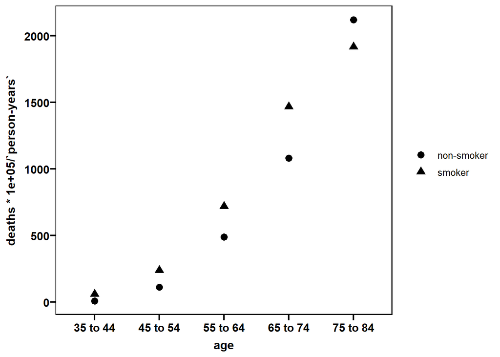

```r
library(tidyverse)
library(ggprism)
doctors |> ggplot(aes(x=age,
                      y=deaths*100000/`person-years`,
                      group=smoking))+geom_point(size=3, aes(shape=smoking)) +
  scale_colour_prism(palette = "colorblind_safe",
                     labels = c("No smoking", "smoking")) +
  theme_prism(border = TRUE,
              palette = "black_and_white",
              base_size = 12)
```

```r
doctors |> mutate(agecat = c(1:5,1:5),
              agesq = agecat^2,
              smoke = c(rep(1,5), rep(0,5)),
              smokage = c(1:5, rep(0,5)))
```

```
## # A tibble: 10 × 8
##    age      smoking    deaths `person-years` agecat agesq smoke smokage
##    <chr>    <chr>       <dbl>          <dbl>  <int> <dbl> <dbl>   <dbl>
##  1 35 to 44 smoker         32          52407      1     1     1       1
##  2 45 to 54 smoker        104          43248      2     4     1       2
##  3 55 to 64 smoker        206          28612      3     9     1       3
##  4 65 to 74 smoker        186          12663      4    16     1       4
##  5 75 to 84 smoker        102           5317      5    25     1       5
##  6 35 to 44 non-smoker      2          18790      1     1     0       0
##  7 45 to 54 non-smoker     12          10673      2     4     0       0
##  8 55 to 64 non-smoker     28           5710      3     9     0       0
##  9 65 to 74 non-smoker     28           2585      4    16     0       0
## 10 75 to 84 non-smoker     31           1462      5    25     0       0
```

```r
doctors2 <- doctors |> mutate(agecat = c(1:5,1:5),
              agesq = agecat^2,
              smoke = c(rep(1,5), rep(0,5)),
              smokage = c(1:5, rep(0,5)))
doctors2
```

```
## # A tibble: 10 × 8
##    age      smoking    deaths `person-years` agecat agesq smoke smokage
##    <chr>    <chr>       <dbl>          <dbl>  <int> <dbl> <dbl>   <dbl>
##  1 35 to 44 smoker         32          52407      1     1     1       1
##  2 45 to 54 smoker        104          43248      2     4     1       2
##  3 55 to 64 smoker        206          28612      3     9     1       3
##  4 65 to 74 smoker        186          12663      4    16     1       4
##  5 75 to 84 smoker        102           5317      5    25     1       5
##  6 35 to 44 non-smoker      2          18790      1     1     0       0
##  7 45 to 54 non-smoker     12          10673      2     4     0       0
##  8 55 to 64 non-smoker     28           5710      3     9     0       0
##  9 65 to 74 non-smoker     28           2585      4    16     0       0
## 10 75 to 84 non-smoker     31           1462      5    25     0       0
```

```r
res.doc<-glm(deaths~agecat + agesq + smoke + smoke:agecat + offset(log(`person-years`)),
             family=poisson(link="log"),data=doctors2)
summary(res.doc)
```

```
##
## Call:
## glm(formula = deaths ~ agecat + agesq + smoke + smoke:agecat +
##     offset(log(`person-years`)), family = poisson(link = "log"),
##     data = doctors2)
##
## Coefficients:
##               Estimate Std. Error z value Pr(>|z|)
## (Intercept)  -10.79176    0.45008 -23.978  < 2e-16 ***
## agecat         2.37648    0.20795  11.428  < 2e-16 ***
## agesq         -0.19768    0.02737  -7.223 5.08e-13 ***
## smoke          1.44097    0.37220   3.872 0.000108 ***
## agecat:smoke  -0.30755    0.09704  -3.169 0.001528 **
## ---
## Signif. codes:  0 '***' 0.001 '**' 0.01 '*' 0.05 '.' 0.1 ' ' 1
##
## (Dispersion parameter for poisson family taken to be 1)
##
##     Null deviance: 935.0673  on 9  degrees of freedom
## Residual deviance:   1.6354  on 5  degrees of freedom
## AIC: 66.703
##
## Number of Fisher Scoring iterations: 4
```

```r
summary(res.doc)$coefficients
```

```
##                 Estimate Std. Error    z value      Pr(>|z|)
## (Intercept)  -10.7917625 0.45007723 -23.977579 4.766017e-127
## agecat         2.3764783 0.20794860  11.428201  3.023077e-30
## agesq         -0.1976765 0.02736742  -7.223060  5.083068e-13
## smoke          1.4409719 0.37219886   3.871511  1.081629e-04
## agecat:smoke  -0.3075481 0.09704114  -3.169255  1.528305e-03
```

```r
#Table9.2
tibble(beta_hat=c(res.doc$coefficients[2:5]),
       se_beta_hat=c(summary(res.doc)$coefficients[2:5,2]),
       Wald_statistic=beta_hat/se_beta_hat,
       p_value=2*(1-pnorm(abs(Wald_statistic))),
       Rate_ratio=exp(beta_hat),
       `95%CI_low`=exp(beta_hat+qnorm(0.025)*summary(res.doc)$coefficients[2:5,2]),
       `95%CI_high`=exp(beta_hat+qnorm(0.975)*summary(res.doc)$coefficients[2:5,2])
       )
```

```
## # A tibble: 4 × 7
##   beta_hat se_beta_hat Wald_statistic  p_value Rate_ratio `95%CI_low`
##      <dbl>       <dbl>          <dbl>    <dbl>      <dbl>       <dbl>
## 1    2.38       0.208           11.4  0            10.8         7.16
## 2   -0.198      0.0274          -7.22 5.08e-13      0.821       0.778
## 3    1.44       0.372            3.87 1.08e- 4      4.22        2.04
## 4   -0.308      0.0970          -3.17 1.53e- 3      0.735       0.608
## # ℹ 1 more variable: `95%CI_high` <dbl>
```

```r
fit_p=c(fitted(res.doc))
fit_p
```

```
##          1          2          3          4          5          6          7
##  29.584734 106.811960 208.198646 182.827893 102.576767   3.414801  11.541629
##          8          9         10
##  24.743377  30.229155  31.071038
```

```r
pearsonresid<-(doctors$deaths-fit_p)/sqrt(fit_p)
pearsonresid
```

```
##           1           2           3           4           5           6
##  0.44404929 -0.27208163 -0.15237591  0.23459923 -0.05694769 -0.76561908
##           7           8           9          10
##  0.13492231  0.65469354 -0.40544060 -0.01274427
```

```r
chisq<-sum(pearsonresid*pearsonresid)
chisq
```

```
## [1] 1.550251
```

```r
devres<-sign(doctors2$deaths-fit_p)*(sqrt(2*(doctors2$deaths*log(doctors2$deaths/fit_p)-(doctors2$deaths-fit_p))))
devres
```

```
##           1           2           3           4           5           6
##  0.43820403 -0.27328873 -0.15264528  0.23392570 -0.05700118 -0.83049031
##           7           8           9          10
##  0.13404370  0.64106682 -0.41058325 -0.01274913
```

```r
deviance<-sum(devres*devres)
deviance
```

```
## [1] 1.63537
```

```r
#Table9.3
tibble(Age.cat=doctors2$agecat,
       smoking.cat=doctors2$smoke,
       Observed.death=doctors2$deaths,
       Expected.death=fit_p,
       Pearson.residual=pearsonresid,
       Deviance.residual=devres)
```

```
## # A tibble: 10 × 6
##    Age.cat smoking.cat Observed.death Expected.death Pearson.residual
##      <int>       <dbl>          <dbl>          <dbl>            <dbl>
##  1       1           1             32          29.6            0.444
##  2       2           1            104         107.            -0.272
##  3       3           1            206         208.            -0.152
##  4       4           1            186         183.             0.235
##  5       5           1            102         103.            -0.0569
##  6       1           0              2           3.41          -0.766
##  7       2           0             12          11.5            0.135
##  8       3           0             28          24.7            0.655
##  9       4           0             28          30.2           -0.405
## 10       5           0             31          31.1           -0.0127
## # ℹ 1 more variable: Deviance.residual <dbl>
```

```r
res.doc$deviance
```

```
## [1] 1.63537
```

```r
res.doc.mini<-glm(deaths~1 + offset(log(`person-years`)),
             family=poisson(link="log"),data=doctors2)
summary(res.doc.mini)
```

```
##
## Call:
## glm(formula = deaths ~ 1 + offset(log(`person-years`)), family = poisson(link = "log"),
##     data = doctors2)
##
## Coefficients:
##             Estimate Std. Error z value Pr(>|z|)
## (Intercept) -5.51442    0.03698  -149.1   <2e-16 ***
## ---
## Signif. codes:  0 '***' 0.001 '**' 0.01 '*' 0.05 '.' 0.1 ' ' 1
##
## (Dispersion parameter for poisson family taken to be 1)
##
##     Null deviance: 935.07  on 9  degrees of freedom
## Residual deviance: 935.07  on 9  degrees of freedom
## AIC: 992.14
##
## Number of Fisher Scoring iterations: 5
```

```r
logLik(res.doc.mini)
```

```
## 'log Lik.' -495.0676 (df=1)
```

```r
logLik(res.doc)
```

```
## 'log Lik.' -28.35166 (df=5)
```

```r
#C

2*(logLik(res.doc)-logLik(res.doc.mini))
```

```
## 'log Lik.' 933.432 (df=5)
```

```r
1-pchisq(933.432, df=4)
```

```
## [1] 0
```

```r
#pseudo R2
(logLik(res.doc.mini)-logLik(res.doc))/logLik(res.doc.mini)
```

```
## 'log Lik.' 0.9427318 (df=1)
```

```r
#Table9.4
melanoma <- structure(list(type = c("hutchinson's melanotic freckle", "hutchinson's melanotic freckle",
"hutchinson's melanotic freckle", "superficial spreading melanoma",
"superficial spreading melanoma", "superficial spreading melanoma",
"nodular", "nodular", "nodular", "indeterminate", "indeterminate",
"indeterminate"), site = c("head & neck", "trunk", "extremities",
"head & neck", "trunk", "extremities", "head & neck", "trunk",
"extremities", "head & neck", "trunk", "extremities"), frequency = c(22,
2, 10, 16, 54, 115, 19, 33, 73, 11, 17, 28)), class = c("tbl_df",
"tbl", "data.frame"), row.names = c(NA, -12L))
melanoma
```

```
## # A tibble: 12 × 3
##    type                           site        frequency
##    <chr>                          <chr>           <dbl>
##  1 hutchinson's melanotic freckle head & neck        22
##  2 hutchinson's melanotic freckle trunk               2
##  3 hutchinson's melanotic freckle extremities        10
##  4 superficial spreading melanoma head & neck        16
##  5 superficial spreading melanoma trunk              54
##  6 superficial spreading melanoma extremities       115
##  7 nodular                        head & neck        19
##  8 nodular                        trunk              33
##  9 nodular                        extremities        73
## 10 indeterminate                  head & neck        11
## 11 indeterminate                  trunk              17
## 12 indeterminate                  extremities        28
```

```r
library(tidyverse)
melanoma |> tidyr::pivot_wider(names_from = type, values_from = frequency) |>
  mutate(sum=`hutchinson's melanotic freckle`+ `superficial spreading melanoma` +nodular+ indeterminate)
```

```
## # A tibble: 3 × 6
##   site       hutchinson's melanot…¹ superficial spreadin…² nodular indeterminate
##   <chr>                       <dbl>                  <dbl>   <dbl>         <dbl>
## 1 head & ne…                     22                     16      19            11
## 2 trunk                           2                     54      33            17
## 3 extremiti…                     10                    115      73            28
## # ℹ abbreviated names: ¹`hutchinson's melanotic freckle`,
## #   ²`superficial spreading melanoma`
## # ℹ 1 more variable: sum <dbl>
```

```r
library(tidyverse)
library(gt)
melanoma |> pivot_wider(names_from = type, values_from = frequency) |>
  mutate(sum=`hutchinson's melanotic freckle`+ `superficial spreading melanoma` +nodular+ indeterminate) |>
  gt(rowname_col = "site") |>
  grand_summary_rows(fns = list(fn = "sum"))
```

|  | hutchinson's melanotic freckle | superficial spreading melanoma | nodular | indeterminate | sum |
| --- | --- | --- | --- | --- | --- |
| head & neck | 22 | 16 | 19 | 11 | 68 |
| trunk | 2 | 54 | 33 | 17 | 106 |
| extremities | 10 | 115 | 73 | 28 | 226 |
| sum | 34 | 185 | 125 | 56 | 400 |

```r
melanoma2 <- melanoma |> pivot_wider(names_from = type, values_from = frequency) |>
  mutate(sum=`hutchinson's melanotic freckle`+ `superficial spreading melanoma` +nodular+ indeterminate) |>
  gt(rowname_col = "site") |>
  grand_summary_rows(fns = list(fn = "sum"))
melanoma2
```

|  | hutchinson's melanotic freckle | superficial spreading melanoma | nodular | indeterminate | sum |
| --- | --- | --- | --- | --- | --- |
| head & neck | 22 | 16 | 19 | 11 | 68 |
| trunk | 2 | 54 | 33 | 17 | 106 |
| extremities | 10 | 115 | 73 | 28 | 226 |
| sum | 34 | 185 | 125 | 56 | 400 |

```r
melanoma3 <- melanoma |> pivot_wider(names_from = type, values_from = frequency) |>
  mutate(sum=`hutchinson's melanotic freckle`+ `superficial spreading melanoma` +nodular+ indeterminate)
melanoma3
```

```
## # A tibble: 3 × 6
##   site       hutchinson's melanot…¹ superficial spreadin…² nodular indeterminate
##   <chr>                       <dbl>                  <dbl>   <dbl>         <dbl>
## 1 head & ne…                     22                     16      19            11
## 2 trunk                           2                     54      33            17
## 3 extremiti…                     10                    115      73            28
## # ℹ abbreviated names: ¹`hutchinson's melanotic freckle`,
## #   ²`superficial spreading melanoma`
## # ℹ 1 more variable: sum <dbl>
```

```r
melanoma3[4,] <- list("sum", 34,    185,    125,    56, 400)
melanoma3
```

```
## # A tibble: 4 × 6
##   site       hutchinson's melanot…¹ superficial spreadin…² nodular indeterminate
##   <chr>                       <dbl>                  <dbl>   <dbl>         <dbl>
## 1 head & ne…                     22                     16      19            11
## 2 trunk                           2                     54      33            17
## 3 extremiti…                     10                    115      73            28
## 4 sum                            34                    185     125            56
## # ℹ abbreviated names: ¹`hutchinson's melanotic freckle`,
## #   ²`superficial spreading melanoma`
## # ℹ 1 more variable: sum <dbl>
```

```r
#row ratio
melanoma3[4, 2:5]/400
```

```
##   hutchinson's melanotic freckle superficial spreading melanoma nodular
## 1                          0.085                         0.4625  0.3125
##   indeterminate
## 1          0.14
```

```r
#column ratio
melanoma3[1:3, 6]/400
```

```
##     sum
## 1 0.170
## 2 0.265
## 3 0.565
```

```r
str(matrix(unlist(melanoma3[4, 2:5]/400)))
```

```
##  num [1:4, 1] 0.085 0.463 0.312 0.14
```

```r
m1 <- matrix(unlist(melanoma3[4, 2:5]/400), nrow=1)
m1
```

```
##       [,1]   [,2]   [,3] [,4]
## [1,] 0.085 0.4625 0.3125 0.14
```

```r
m2 <- matrix(t(melanoma3[1:3, 6]/400), ncol = 1)
m2
```

```
##       [,1]
## [1,] 0.170
## [2,] 0.265
## [3,] 0.565
```

```r
str(m1)
```

```
##  num [1, 1:4] 0.085 0.463 0.312 0.14
```

```r
str(m2)
```

```
##  num [1:3, 1] 0.17 0.265 0.565
```

```r
m2 %*% m1
```

```
##          [,1]      [,2]      [,3]   [,4]
## [1,] 0.014450 0.0786250 0.0531250 0.0238
## [2,] 0.022525 0.1225625 0.0828125 0.0371
## [3,] 0.048025 0.2613125 0.1765625 0.0791
```

```r
(m2 %*% m1) * 400
```

```
##       [,1]    [,2]   [,3]  [,4]
## [1,]  5.78  31.450 21.250  9.52
## [2,]  9.01  49.025 33.125 14.84
## [3,] 19.21 104.525 70.625 31.64
```

```r
estimated <- (m2 %*% m1) * 400
```

```r
unlist(t(melanoma3[1:3, 2:5]))
```

```
##                                [,1] [,2] [,3]
## hutchinson's melanotic freckle   22    2   10
## superficial spreading melanoma   16   54  115
## nodular                          19   33   73
## indeterminate                    11   17   28
```

```r
matrix(unlist(t(melanoma3[1:3, 2:5])), ncol=4, byrow = T)
```

```
##      [,1] [,2] [,3] [,4]
## [1,]   22   16   19   11
## [2,]    2   54   33   17
## [3,]   10  115   73   28
```

```r
observed <- matrix(unlist(t(melanoma3[1:3, 2:5])), ncol=4, byrow = T)
```

```r
#X^2
(observed-estimated)^2/estimated
```

```
##           [,1]      [,2]         [,3]      [,4]
## [1,] 45.517024 7.5899046 0.2382352941 0.2300840
## [2,]  5.453951 0.5048572 0.0004716981 0.3143935
## [3,]  4.415622 1.0497548 0.0798672566 0.4187611
```

```r
sum((observed-estimated)^2/estimated)
```

```
## [1] 65.81293
```

```r
1-pchisq(65.81293, df=6)
```

```
## [1] 2.943201e-12
```

```r
melanoma5 <- melanoma |> mutate(tumor = factor(type, levels = c("hutchinson's melanotic freckle",
                                                   "superficial spreading melanoma",
                                                   "nodular",
                                                   "indeterminate")),
                   site2 = factor(site, levels = c("head & neck",
                                                   "trunk",
                                                   "extremities"))
                   )
melanoma5
```

```
## # A tibble: 12 × 5
##    type                           site        frequency tumor              site2
##    <chr>                          <chr>           <dbl> <fct>              <fct>
##  1 hutchinson's melanotic freckle head & neck        22 hutchinson's mela… head…
##  2 hutchinson's melanotic freckle trunk               2 hutchinson's mela… trunk
##  3 hutchinson's melanotic freckle extremities        10 hutchinson's mela… extr…
##  4 superficial spreading melanoma head & neck        16 superficial sprea… head…
##  5 superficial spreading melanoma trunk              54 superficial sprea… trunk
##  6 superficial spreading melanoma extremities       115 superficial sprea… extr…
##  7 nodular                        head & neck        19 nodular            head…
##  8 nodular                        trunk              33 nodular            trunk
##  9 nodular                        extremities        73 nodular            extr…
## 10 indeterminate                  head & neck        11 indeterminate      head…
## 11 indeterminate                  trunk              17 indeterminate      trunk
## 12 indeterminate                  extremities        28 indeterminate      extr…
```

```r
ressat.melanoma<-glm(frequency~tumor*site2,family=poisson(),data=melanoma5)
ressat.melanoma
```

```
##
## Call:  glm(formula = frequency ~ tumor * site2, family = poisson(),
##     data = melanoma5)
##
## Coefficients:
##                                          (Intercept)
##                                               3.0910
##                  tumorsuperficial spreading melanoma
##                                              -0.3185
##                                         tumornodular
##                                              -0.1466
##                                   tumorindeterminate
##                                              -0.6931
##                                           site2trunk
##                                              -2.3979
##                                     site2extremities
##                                              -0.7885
##       tumorsuperficial spreading melanoma:site2trunk
##                                               3.6143
##                              tumornodular:site2trunk
##                                               2.9500
##                        tumorindeterminate:site2trunk
##                                               2.8332
## tumorsuperficial spreading melanoma:site2extremities
##                                               2.7608
##                        tumornodular:site2extremities
##                                               2.1345
##                  tumorindeterminate:site2extremities
##                                               1.7228
##
## Degrees of Freedom: 11 Total (i.e. Null);  0 Residual
## Null Deviance:       295.2
## Residual Deviance: -1.754e-14    AIC: 83.11
```

```r
summary(ressat.melanoma)
```

```
##
## Call:
## glm(formula = frequency ~ tumor * site2, family = poisson(),
##     data = melanoma5)
##
## Coefficients:
##                                                      Estimate Std. Error
## (Intercept)                                            3.0910     0.2132
## tumorsuperficial spreading melanoma                   -0.3185     0.3286
## tumornodular                                          -0.1466     0.3132
## tumorindeterminate                                    -0.6931     0.3693
## site2trunk                                            -2.3979     0.7385
## site2extremities                                      -0.7885     0.3814
## tumorsuperficial spreading melanoma:site2trunk         3.6143     0.7915
## tumornodular:site2trunk                                2.9500     0.7927
## tumorindeterminate:site2trunk                          2.8332     0.8338
## tumorsuperficial spreading melanoma:site2extremities   2.7608     0.4655
## tumornodular:site2extremities                          2.1345     0.4602
## tumorindeterminate:site2extremities                    1.7228     0.5216
##                                                      z value Pr(>|z|)
## (Intercept)                                           14.498  < 2e-16 ***
## tumorsuperficial spreading melanoma                   -0.969 0.332432
## tumornodular                                          -0.468 0.639712
## tumorindeterminate                                    -1.877 0.060511 .
## site2trunk                                            -3.247 0.001167 **
## site2extremities                                      -2.067 0.038701 *
## tumorsuperficial spreading melanoma:site2trunk         4.566 4.96e-06 ***
## tumornodular:site2trunk                                3.721 0.000198 ***
## tumorindeterminate:site2trunk                          3.398 0.000679 ***
## tumorsuperficial spreading melanoma:site2extremities   5.931 3.00e-09 ***
## tumornodular:site2extremities                          4.638 3.52e-06 ***
## tumorindeterminate:site2extremities                    3.303 0.000957 ***
## ---
## Signif. codes:  0 '***' 0.001 '**' 0.01 '*' 0.05 '.' 0.1 ' ' 1
##
## (Dispersion parameter for poisson family taken to be 1)
##
##     Null deviance:  2.9520e+02  on 11  degrees of freedom
## Residual deviance: -1.7542e-14  on  0  degrees of freedom
## AIC: 83.111
##
## Number of Fisher Scoring iterations: 3
```

```r
logLik(ressat.melanoma)
```

```
## 'log Lik.' -29.5557 (df=12)
```

```r
ressat.melanoma.add<-glm(frequency~tumor+site2,family=poisson(),data=melanoma5)
summary(ressat.melanoma.add)
```

```
##
## Call:
## glm(formula = frequency ~ tumor + site2, family = poisson(),
##     data = melanoma5)
##
## Coefficients:
##                                     Estimate Std. Error z value Pr(>|z|)
## (Intercept)                           1.7544     0.2040   8.600  < 2e-16 ***
## tumorsuperficial spreading melanoma   1.6940     0.1866   9.079  < 2e-16 ***
## tumornodular                          1.3020     0.1934   6.731 1.68e-11 ***
## tumorindeterminate                    0.4990     0.2174   2.295  0.02173 *
## site2trunk                            0.4439     0.1554   2.857  0.00427 **
## site2extremities                      1.2010     0.1383   8.683  < 2e-16 ***
## ---
## Signif. codes:  0 '***' 0.001 '**' 0.01 '*' 0.05 '.' 0.1 ' ' 1
##
## (Dispersion parameter for poisson family taken to be 1)
##
##     Null deviance: 295.203  on 11  degrees of freedom
## Residual deviance:  51.795  on  6  degrees of freedom
## AIC: 122.91
##
## Number of Fisher Scoring iterations: 5
```

```r
#D
logLik(ressat.melanoma.add)
```

```
## 'log Lik.' -55.45321 (df=6)
```

```r
2*(logLik(ressat.melanoma)-logLik(ressat.melanoma.add))
```

```
## 'log Lik.' 51.79501 (df=12)
```

```r
ressat.melanoma.add$fitted.values
```

```
##       1       2       3       4       5       6       7       8       9      10
##   5.780   9.010  19.210  31.450  49.025 104.525  21.250  33.125  70.625   9.520
##      11      12
##  14.840  31.640
```

```r
melanoma5$frequency
```

```
##  [1]  22   2  10  16  54 115  19  33  73  11  17  28
```

```r
#chi-square
sum((ressat.melanoma.add$fitted.values-melanoma5$frequency)^2/ressat.melanoma.add$fitted.values)
```

```
## [1] 65.81293
```

```r
ressat.melanoma.mini<-glm(frequency~1,family=poisson(),data=melanoma5)
summary(ressat.melanoma.mini)
```

```
##
## Call:
## glm(formula = frequency ~ 1, family = poisson(), data = melanoma5)
##
## Coefficients:
##             Estimate Std. Error z value Pr(>|z|)
## (Intercept)    3.507      0.050   70.13   <2e-16 ***
## ---
## Signif. codes:  0 '***' 0.001 '**' 0.01 '*' 0.05 '.' 0.1 ' ' 1
##
## (Dispersion parameter for poisson family taken to be 1)
##
##     Null deviance: 295.2  on 11  degrees of freedom
## Residual deviance: 295.2  on 11  degrees of freedom
## AIC: 356.31
##
## Number of Fisher Scoring iterations: 5
```

```r
#D
logLik(ressat.melanoma.mini)
```

```
## 'log Lik.' -177.1572 (df=1)
```

```r
2*(logLik(ressat.melanoma.add)-logLik(ressat.melanoma.mini))
```

```
## 'log Lik.' 243.408 (df=6)
```

```r
#pseudo R2
(logLik(ressat.melanoma.mini)-logLik(ressat.melanoma))/logLik(ressat.melanoma.mini)
```

```
## 'log Lik.' 0.8331668 (df=1)
```

```r
#Table 9.7
ulcer
```

```
## # A tibble: 8 × 4
##   ulcer    `case-control` aspirin  frequency
##   <chr>    <chr>          <chr>        <dbl>
## 1 gastric  control        non-user        62
## 2 gastric  control        user             6
## 3 gastric  case           non-user        39
## 4 gastric  case           user            25
## 5 duodenal control        non-user        53
## 6 duodenal control        user             8
## 7 duodenal case           non-user        49
## 8 duodenal case           user             8
```

```r
ulcer$ulcer
```

```
## [1] "gastric"  "gastric"  "gastric"  "gastric"  "duodenal" "duodenal" "duodenal"
## [8] "duodenal"
```

```r
#GD ulcer site
#CC case-control status
#AP aspirin
library(tidyverse)
ulcer2 <- ulcer |> mutate(GD = factor(ulcer, levels = c("gastric", "duodenal")),
                          CC = factor(`case-control`, levels = c("control", "case")),
                          AP = factor(aspirin, levels = c("non-user", "user"))
                   )
ulcer2
```

```
## # A tibble: 8 × 7
##   ulcer    `case-control` aspirin  frequency GD       CC      AP
##   <chr>    <chr>          <chr>        <dbl> <fct>    <fct>   <fct>
## 1 gastric  control        non-user        62 gastric  control non-user
## 2 gastric  control        user             6 gastric  control user
## 3 gastric  case           non-user        39 gastric  case    non-user
## 4 gastric  case           user            25 gastric  case    user
## 5 duodenal control        non-user        53 duodenal control non-user
## 6 duodenal control        user             8 duodenal control user
## 7 duodenal case           non-user        49 duodenal case    non-user
## 8 duodenal case           user             8 duodenal case    user
```

```r
res1.aspirin<-glm(frequency~GD + CC + GD*CC, family=poisson(), data=ulcer2)
summary(res1.aspirin)
```

```
##
## Call:
## glm(formula = frequency ~ GD + CC + GD * CC, family = poisson(),
##     data = ulcer2)
##
## Coefficients:
##                    Estimate Std. Error z value Pr(>|z|)
## (Intercept)        3.526361   0.121268  29.079   <2e-16 ***
## GDduodenal        -0.108634   0.176350  -0.616    0.538
## CCcase            -0.060625   0.174158  -0.348    0.728
## GDduodenal:CCcase -0.007198   0.253512  -0.028    0.977
## ---
## Signif. codes:  0 '***' 0.001 '**' 0.01 '*' 0.05 '.' 0.1 ' ' 1
##
## (Dispersion parameter for poisson family taken to be 1)
##
##     Null deviance: 127.75  on 7  degrees of freedom
## Residual deviance: 126.71  on 4  degrees of freedom
## AIC: 174.32
##
## Number of Fisher Scoring iterations: 5
```

```r
res2.aspirin<-glm(frequency~GD + CC + GD*CC + AP, family=poisson(), data=ulcer2)
summary(res2.aspirin)
```

```
##
## Call:
## glm(formula = frequency ~ GD + CC + GD * CC + AP, family = poisson(),
##     data = ulcer2)
##
## Coefficients:
##                    Estimate Std. Error z value Pr(>|z|)
## (Intercept)        4.011253   0.125028  32.083   <2e-16 ***
## GDduodenal        -0.108634   0.176350  -0.616    0.538
## CCcase            -0.060625   0.174158  -0.348    0.728
## APuser            -1.463058   0.161872  -9.038   <2e-16 ***
## GDduodenal:CCcase -0.007198   0.253512  -0.028    0.977
## ---
## Signif. codes:  0 '***' 0.001 '**' 0.01 '*' 0.05 '.' 0.1 ' ' 1
##
## (Dispersion parameter for poisson family taken to be 1)
##
##     Null deviance: 127.749  on 7  degrees of freedom
## Residual deviance:  21.789  on 3  degrees of freedom
## AIC: 71.404
##
## Number of Fisher Scoring iterations: 5
```

```r
res3.aspirin<-glm(frequency~GD + CC + GD*CC + AP + AP*CC,family=poisson(), data=ulcer2)
summary(res3.aspirin)
```

```
##
## Call:
## glm(formula = frequency ~ GD + CC + GD * CC + AP + AP * CC, family = poisson(),
##     data = ulcer2)
##
## Coefficients:
##                    Estimate Std. Error z value Pr(>|z|)
## (Intercept)        4.104627   0.125098  32.811  < 2e-16 ***
## GDduodenal        -0.108634   0.176350  -0.616  0.53789
## CCcase            -0.264198   0.185402  -1.425  0.15416
## APuser            -2.105875   0.283062  -7.440 1.01e-13 ***
## GDduodenal:CCcase -0.007198   0.253511  -0.028  0.97735
## CCcase:APuser      1.125046   0.348984   3.224  0.00127 **
## ---
## Signif. codes:  0 '***' 0.001 '**' 0.01 '*' 0.05 '.' 0.1 ' ' 1
##
## (Dispersion parameter for poisson family taken to be 1)
##
##     Null deviance: 127.749  on 7  degrees of freedom
## Residual deviance:  10.538  on 2  degrees of freedom
## AIC: 62.153
##
## Number of Fisher Scoring iterations: 4
```

```r
res4.aspirin<-glm(frequency~GD + CC + GD*CC + AP + AP*CC + AP*GD, family=poisson(), data=ulcer2)
summary(res4.aspirin)
```

```
##
## Call:
## glm(formula = frequency ~ GD + CC + GD * CC + AP + AP * CC +
##     AP * GD, family = poisson(), data = ulcer2)
##
## Coefficients:
##                   Estimate Std. Error z value Pr(>|z|)
## (Intercept)        4.06961    0.12862  31.640  < 2e-16 ***
## GDduodenal        -0.03598    0.18042  -0.199  0.84195
## CCcase            -0.32091    0.19384  -1.656  0.09782 .
## APuser            -1.82193    0.30796  -5.916  3.3e-09 ***
## GDduodenal:CCcase  0.10574    0.26147   0.404  0.68590
## CCcase:APuser      1.14288    0.35207   3.246  0.00117 **
## GDduodenal:APuser -0.70005    0.34603  -2.023  0.04306 *
## ---
## Signif. codes:  0 '***' 0.001 '**' 0.01 '*' 0.05 '.' 0.1 ' ' 1
##
## (Dispersion parameter for poisson family taken to be 1)
##
##     Null deviance: 127.749  on 7  degrees of freedom
## Residual deviance:   6.283  on 1  degrees of freedom
## AIC: 59.898
##
## Number of Fisher Scoring iterations: 4
```

```r
#Table 9.11
tibble(Models=c("GD+CC+GDXCC",
                "GD+CC+GDXCC+AP",
                "GD+CC+GDXCC+AP+APXCC",
                "GD+CC+GDXCC+AP+APXCC++APXGD"),
       D.F.=c(res1.aspirin$df.residual,
              res2.aspirin$df.residual,
              res3.aspirin$df.residual,
              res4.aspirin$df.residual),
       Deviance=c(res1.aspirin$deviance,
                  res2.aspirin$deviance,
                  res3.aspirin$deviance,
                  res4.aspirin$deviance)
       ) |> as.data.frame()
```

```
##                        Models D.F.   Deviance
## 1                 GD+CC+GDXCC    4 126.707890
## 2              GD+CC+GDXCC+AP    3  21.789257
## 3        GD+CC+GDXCC+AP+APXCC    2  10.538439
## 4 GD+CC+GDXCC+AP+APXCC++APXGD    1   6.282983
```

```r
#delta D comparison of aspirin use between cases and controls
res2.aspirin$deviance - res3.aspirin$deviance
```

```
## [1] 11.25082
```

```r
(1-pchisq(11.25082, df=1))
```

```
## [1] 0.0007958785
```

```r
#delta D, difference between ulcer sites
res3.aspirin$deviance - res4.aspirin$deviance
```

```
## [1] 4.255456
```

```r
(1-pchisq(4.255456, df=1))
```

```
## [1] 0.03912444
```

```r
#chi-square
sum((res4.aspirin$fitted.values-ulcer2$frequency)^2/res4.aspirin$fitted.values)
```

```
## [1] 6.48795
```

```r
(1-pchisq(6.48795, df=1))
```

```
## [1] 0.01086082
```

```r
res4.aspirin$fitted.values
```

```
##         1         2         3         4         5         6         7         8
## 58.534241  9.465759 42.465759 21.534241 56.465759  4.534241 45.534241 11.465759
```

```r
res4.aspirin$deviance
```

```
## [1] 6.282983
```

#### Exercises 9.1

The joint probability distribution:
$$f(\mathbf
y;\boldsymbol\mu)=\prod_{i=1}^{N}\mu_i^{y_i}e^{-\mu_i}/y_i!$$

$$l(\mathbf
y;\boldsymbol\mu)=\sum_{i=1}^{N}(y_i\log(\mu_i)-\mu_i-\log(y_i!))=\sum_{i=1}^{N}\left(y_i\left(\beta_1+\sum_{j=2}^{J}x_{ij}\beta_j\right)-\exp\left(\beta_1+\sum_{j=2}^{J}x_{ij}\beta_j\right)-\log(y_i!)\right)$$
The score statistic for $\beta_1$ is
$$\frac{\partial l(\mathbf
y;\boldsymbol\mu)}{\partial
\beta_1}=\sum_{i=1}^{N}\left(y_i-\mu_i\right)$$

```r
#Exercises 9.2
insurance
```

```
## # A tibble: 32 × 5
##      car   age district     y     n
##    <dbl> <dbl>    <dbl> <dbl> <dbl>
##  1     1     1        0    65   317
##  2     1     2        0    65   476
##  3     1     3        0    52   486
##  4     1     4        0   310  3259
##  5     2     1        0    98   486
##  6     2     2        0   159  1004
##  7     2     3        0   175  1355
##  8     2     4        0   877  7660
##  9     3     1        0    41   223
## 10     3     2        0   117   539
## 11     3     3        0   137   697
## 12     3     4        0   477  3442
## 13     4     1        0    11    40
## 14     4     2        0    35   148
## 15     4     3        0    39   214
## 16     4     4        0   167  1019
## 17     1     1        1     2    20
## 18     1     2        1     5    33
## 19     1     3        1     4    40
## 20     1     4        1    36   316
## 21     2     1        1     7    31
## 22     2     2        1    10    81
## 23     2     3        1    22   122
## 24     2     4        1   102   724
## 25     3     1        1     5    18
## # ℹ 7 more rows
```

```r
insurance$car2 <- factor(insurance$car)
insurance$age2 <- factor(insurance$age)
insurance$district2 <- factor(insurance$district)
```

```r
insurance |> group_by(c(car2)) |> mutate(rate=sum(y)/sum(n))
```

```
## # A tibble: 32 × 10
## # Groups:   c(car2) [4]
##      car   age district     y     n car2  age2  district2 `c(car2)`  rate
##    <dbl> <dbl>    <dbl> <dbl> <dbl> <fct> <fct> <fct>     <fct>     <dbl>
##  1     1     1        0    65   317 1     1     0         1         0.109
##  2     1     2        0    65   476 1     2     0         1         0.109
##  3     1     3        0    52   486 1     3     0         1         0.109
##  4     1     4        0   310  3259 1     4     0         1         0.109
##  5     2     1        0    98   486 2     1     0         2         0.126
##  6     2     2        0   159  1004 2     2     0         2         0.126
##  7     2     3        0   175  1355 2     3     0         2         0.126
##  8     2     4        0   877  7660 2     4     0         2         0.126
##  9     3     1        0    41   223 3     1     0         3         0.161
## 10     3     2        0   117   539 3     2     0         3         0.161
## 11     3     3        0   137   697 3     3     0         3         0.161
## 12     3     4        0   477  3442 3     4     0         3         0.161
## 13     4     1        0    11    40 4     1     0         4         0.189
## 14     4     2        0    35   148 4     2     0         4         0.189
## 15     4     3        0    39   214 4     3     0         4         0.189
## 16     4     4        0   167  1019 4     4     0         4         0.189
## 17     1     1        1     2    20 1     1     1         1         0.109
## 18     1     2        1     5    33 1     2     1         1         0.109
## 19     1     3        1     4    40 1     3     1         1         0.109
## 20     1     4        1    36   316 1     4     1         1         0.109
## 21     2     1        1     7    31 2     1     1         2         0.126
## 22     2     2        1    10    81 2     2     1         2         0.126
## 23     2     3        1    22   122 2     3     1         2         0.126
## 24     2     4        1   102   724 2     4     1         2         0.126
## 25     3     1        1     5    18 3     1     1         3         0.161
## # ℹ 7 more rows
```

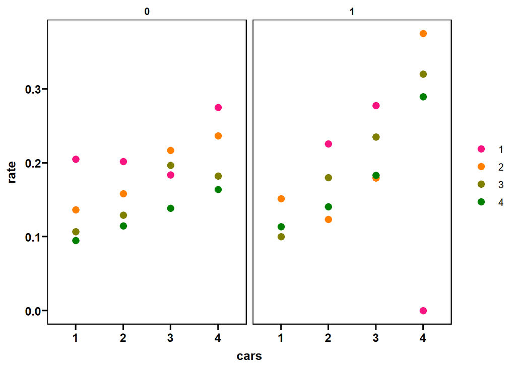

```r
insurance |> ggplot(aes(x=car2, y=y/n)) +
  geom_point(size=3, aes(color=age2)) +
  facet_grid(~district2) +
  scale_colour_prism(palette = "candy_bright") +
  theme_prism(border = TRUE,
              palette = "black_and_white",
              base_size = 12) +
  labs(x="cars", y="rate")
```

```r
res.insurance<-glm(y/n~car2+age2+district2+car2*age2+car2*district2+age2*district2, family=quasipoisson(), data=insurance)
summary(res.insurance)
```

```
##
## Call:
## glm(formula = y/n ~ car2 + age2 + district2 + car2 * age2 + car2 *
##     district2 + age2 * district2, family = quasipoisson(), data = insurance)
##
## Coefficients:
##                  Estimate Std. Error t value Pr(>|t|)
## (Intercept)      -1.63176    0.39059  -4.178  0.00238 **
## car22             0.22917    0.50283   0.456  0.65936
## car23             0.28810    0.49292   0.584  0.57325
## car24            -0.18154    0.54274  -0.334  0.74568
## age22            -0.25468    0.53999  -0.472  0.64840
## age23            -0.67888    0.59357  -1.144  0.28225
## age24            -0.69793    0.59799  -1.167  0.27315
## district21       -0.58042    0.47743  -1.216  0.25502
## car22:age22      -0.39160    0.69271  -0.565  0.58567
## car23:age22      -0.13194    0.65924  -0.200  0.84582
## car24:age22       0.83270    0.67478   1.234  0.24844
## car22:age23       0.01957    0.72284   0.027  0.97899
## car23:age23       0.26895    0.69355   0.388  0.70718
## car24:age23       0.95684    0.72306   1.323  0.21836
## car22:age24      -0.18616    0.74021  -0.251  0.80708
## car23:age24      -0.03957    0.71448  -0.055  0.95705
## car24:age24       0.84184    0.72819   1.156  0.27742
## car22:district21  0.27647    0.52431   0.527  0.61074
## car23:district21  0.31835    0.49950   0.637  0.53978
## car24:district21  0.20342    0.48888   0.416  0.68709
## age22:district21  0.47513    0.45559   1.043  0.32420
## age23:district21  0.66356    0.46475   1.428  0.18712
## age24:district21  0.71833    0.48559   1.479  0.17319
## ---
## Signif. codes:  0 '***' 0.001 '**' 0.01 '*' 0.05 '.' 0.1 ' ' 1
##
## (Dispersion parameter for quasipoisson family taken to be 0.03758626)
##
##     Null deviance: 1.10956  on 31  degrees of freedom
## Residual deviance: 0.43626  on  9  degrees of freedom
## AIC: NA
##
## Number of Fisher Scoring iterations: 5
```

```r
res.insurance2<-glm(y/n~car+age+district, family=quasipoisson(), data=insurance)
summary(res.insurance2)
```

```
##
## Call:
## glm(formula = y/n ~ car + age + district, family = quasipoisson(),
##     data = insurance)
##
## Coefficients:
##             Estimate Std. Error t value Pr(>|t|)
## (Intercept) -2.14870    0.20948 -10.257 5.48e-11 ***
## car          0.19999    0.05271   3.794 0.000727 ***
## age         -0.05696    0.05190  -1.098 0.281733
## district     0.08896    0.11600   0.767 0.449551
## ---
## Signif. codes:  0 '***' 0.001 '**' 0.01 '*' 0.05 '.' 0.1 ' ' 1
##
## (Dispersion parameter for quasipoisson family taken to be 0.01926316)
##
##     Null deviance: 1.10956  on 31  degrees of freedom
## Residual deviance: 0.79295  on 28  degrees of freedom
## AIC: NA
##
## Number of Fisher Scoring iterations: 4
```

```r
#Exercises 9.3
vaccine
```

```
## # A tibble: 6 × 3
##   treatment response frequency
##   <chr>     <chr>        <dbl>
## 1 placebo   small           25
## 2 placebo   moderate         8
## 3 placebo   large            5
## 4 vaccine   small            6
## 5 vaccine   moderate        18
## 6 vaccine   large           11
```

```r
vaccine.frequency <- matrix(c(vaccine$frequency), ncol = 2, byrow = FALSE)
vaccine.frequency
```

```
##      [,1] [,2]
## [1,]   25    6
## [2,]    8   18
## [3,]    5   11
```

```r
chisq.test(vaccine.frequency)
```

```
##
##  Pearson's Chi-squared test
##
## data:  vaccine.frequency
## X-squared = 17.648, df = 2, p-value = 0.0001472
```

```r
res.vaccine<-glm(frequency~treatment+response,family=poisson(),data=vaccine)
summary(res.vaccine)
```

```
##
## Call:
## glm(formula = frequency ~ treatment + response, family = poisson(),
##     data = vaccine)
##
## Coefficients:
##                  Estimate Std. Error z value Pr(>|z|)
## (Intercept)       2.11972    0.27408   7.734 1.04e-14 ***
## treatmentvaccine -0.08224    0.23428  -0.351   0.7256
## responsemoderate  0.48551    0.31774   1.528   0.1265
## responsesmall     0.66140    0.30783   2.149   0.0317 *
## ---
## Signif. codes:  0 '***' 0.001 '**' 0.01 '*' 0.05 '.' 0.1 ' ' 1
##
## (Dispersion parameter for poisson family taken to be 1)
##
##     Null deviance: 23.807  on 5  degrees of freedom
## Residual deviance: 18.643  on 2  degrees of freedom
## AIC: 51.771
##
## Number of Fisher Scoring iterations: 5
```

```r
res.vaccine$fitted.values
```

```
##         1         2         3         4         5         6
## 16.136986 13.534247  8.328767 14.863014 12.465753  7.671233
```

```r
vaccine$frequency
```

```
## [1] 25  8  5  6 18 11
```

```r
sum((vaccine$frequency-res.vaccine$fitted.values)^2/res.vaccine$fitted.values)
```

```
## [1] 17.64783
```

```r
chisq.stat <- sum((vaccine$frequency-res.vaccine$fitted.values)^2/res.vaccine$fitted.values)
1-pchisq(chisq.stat, df=res.vaccine$df.residual)
```

```
## [1] 0.0001471709
```

```r
res.vaccine$deviance
```

```
## [1] 18.64253
```

```r
res.vaccine$residuals
```

```
##          1          2          3          4          5          6
##  0.5492360 -0.4089069 -0.3996711 -0.5963134  0.4439560  0.4339286
```

```r
#For the placebo group the estimated probabilities for the ‘small’, ‘moderate’ and ‘large’ responses are
res.vaccine$coefficients
```

```
##      (Intercept) treatmentvaccine responsemoderate    responsesmall
##        2.1197154       -0.0822381        0.4855078        0.6613985
```

```r
small <- exp(res.vaccine$coefficients[4])
moderate <- exp(res.vaccine$coefficients[3])
total <- sum(small, moderate, 1)
#small
small/total
```

```
## responsesmall
##     0.4246575
```

```r
#moderate
moderate/total
```

```
## responsemoderate
##        0.3561644
```

```r
#large
1/total
```

```
## [1] 0.2191781
```

## Chapter10 Survival Analysis

```r
#Table10.1
remission
```

```
## # A tibble: 42 × 3
##     time group censored
##    <dbl> <chr>    <dbl>
##  1     1 C            0
##  2     1 C            0
##  3     2 C            0
##  4     2 C            0
##  5     3 C            0
##  6     4 C            0
##  7     4 C            0
##  8     5 C            0
##  9     5 C            0
## 10     8 C            0
## 11     8 C            0
## 12     8 C            0
## 13     8 C            0
## 14    11 C            0
## 15    11 C            0
## 16    12 C            0
## 17    12 C            0
## 18    15 C            0
## 19    17 C            0
## 20    22 C            0
## 21    23 C            0
## 22     6 T            0
## 23     6 T            0
## 24     6 T            0
## 25     6 T            1
## # ℹ 17 more rows
```

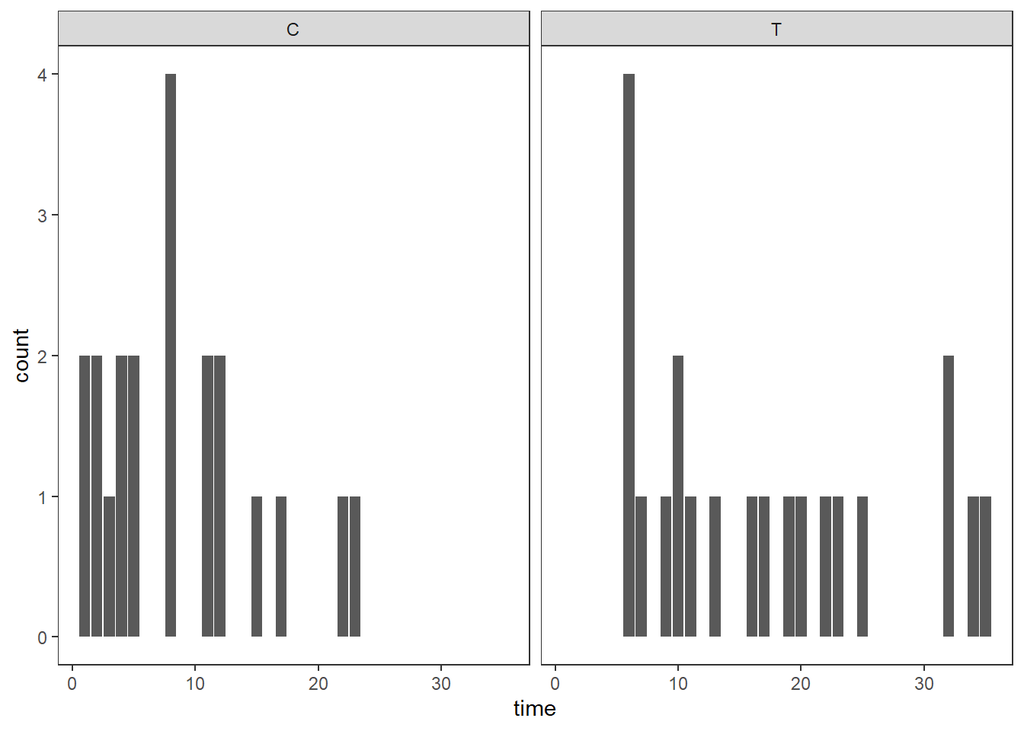

```r
remission |> ggplot(aes(x=time)) +
  geom_bar(stat = "count") +
  facet_wrap(vars(group)) + theme_bw() + theme(
  # Hide panel borders and remove grid lines
  #panel.border = element_line(colour = "black"),
  panel.grid.major = element_blank(),
  panel.grid.minor = element_blank(),
  # Change axis line
  #axis.line = element_line(colour = "black")
)
```

```r
#Table10.2
library(tidyverse)
data.frame(
  n=c(21,21,17,15,12,11,7,6),
  d=c(0,3,1,1,1,1,1,1)
) |> mutate(s=(n-d)/n,
            S=cumprod(s))
```

```
##    n d         s         S
## 1 21 0 1.0000000 1.0000000
## 2 21 3 0.8571429 0.8571429
## 3 17 1 0.9411765 0.8067227
## 4 15 1 0.9333333 0.7529412
## 5 12 1 0.9166667 0.6901961
## 6 11 1 0.9090909 0.6274510
## 7  7 1 0.8571429 0.5378151
## 8  6 1 0.8333333 0.4481793
```

```r
survival_treatment <- data.frame(
  n=c(21,21,17,15,12,11,7,6),
  d=c(0,3,1,1,1,1,1,1)
) |> mutate(time = c(0,6,7,10,13,16,22,23),
            treatment = rep("treatment", 8),
            s=(n-d)/n,
            S=cumprod(s))
survival_treatment
```

```
##    n d time treatment         s         S
## 1 21 0    0 treatment 1.0000000 1.0000000
## 2 21 3    6 treatment 0.8571429 0.8571429
## 3 17 1    7 treatment 0.9411765 0.8067227
## 4 15 1   10 treatment 0.9333333 0.7529412
## 5 12 1   13 treatment 0.9166667 0.6901961
## 6 11 1   16 treatment 0.9090909 0.6274510
## 7  7 1   22 treatment 0.8571429 0.5378151
## 8  6 1   23 treatment 0.8333333 0.4481793
```

```r
#
survival_control <- data.frame(
  n=c(21,21,19,17,16,14,12,8,6,4,3,2,1),
  d=c(0,2,2,1,2,2,4,2,2,1,1,1,1)
) |> mutate(time = c(0,1,2,3,4,5,8,11,12,15,17,22,23),
            treatment = rep("control", 13),
            s=(n-d)/n,
            S=cumprod(s))
survival_control
```

```
##     n d time treatment         s          S
## 1  21 0    0   control 1.0000000 1.00000000
## 2  21 2    1   control 0.9047619 0.90476190
## 3  19 2    2   control 0.8947368 0.80952381
## 4  17 1    3   control 0.9411765 0.76190476
## 5  16 2    4   control 0.8750000 0.66666667
## 6  14 2    5   control 0.8571429 0.57142857
## 7  12 4    8   control 0.6666667 0.38095238
## 8   8 2   11   control 0.7500000 0.28571429
## 9   6 2   12   control 0.6666667 0.19047619
## 10  4 1   15   control 0.7500000 0.14285714
## 11  3 1   17   control 0.6666667 0.09523810
## 12  2 1   22   control 0.5000000 0.04761905
## 13  1 1   23   control 0.0000000 0.00000000
```

```r
data <- rbind(survival_control, survival_treatment)
data
```

```
##     n d time treatment         s          S
## 1  21 0    0   control 1.0000000 1.00000000
## 2  21 2    1   control 0.9047619 0.90476190
## 3  19 2    2   control 0.8947368 0.80952381
## 4  17 1    3   control 0.9411765 0.76190476
## 5  16 2    4   control 0.8750000 0.66666667
## 6  14 2    5   control 0.8571429 0.57142857
## 7  12 4    8   control 0.6666667 0.38095238
## 8   8 2   11   control 0.7500000 0.28571429
## 9   6 2   12   control 0.6666667 0.19047619
## 10  4 1   15   control 0.7500000 0.14285714
## 11  3 1   17   control 0.6666667 0.09523810
## 12  2 1   22   control 0.5000000 0.04761905
## 13  1 1   23   control 0.0000000 0.00000000
## 14 21 0    0 treatment 1.0000000 1.00000000
## 15 21 3    6 treatment 0.8571429 0.85714286
## 16 17 1    7 treatment 0.9411765 0.80672269
## 17 15 1   10 treatment 0.9333333 0.75294118
## 18 12 1   13 treatment 0.9166667 0.69019608
## 19 11 1   16 treatment 0.9090909 0.62745098
## 20  7 1   22 treatment 0.8571429 0.53781513
## 21  6 1   23 treatment 0.8333333 0.44817927
```

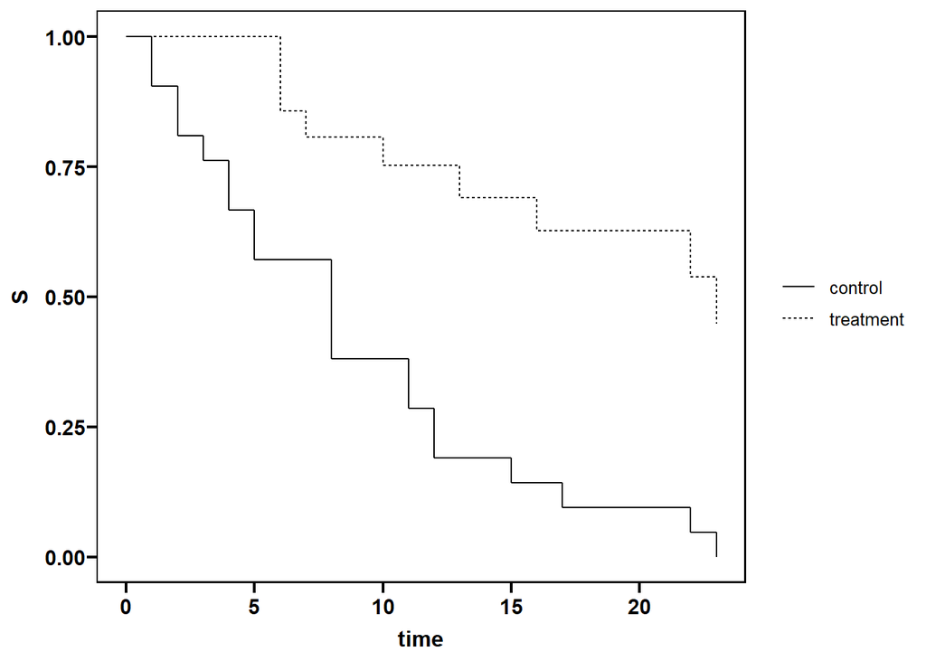

```r
data |> ggplot(aes(x=time, y=S)) + geom_step(aes(linetype = treatment)) + theme_bw() + theme(
  # Hide panel borders and remove grid lines
  #panel.border = element_line(colour = "black"),
  panel.grid.major = element_blank(),
  panel.grid.minor = element_blank(),
  # Change axis line
  #axis.line = element_line(colour = "black")
) + theme_prism(border = TRUE,
              palette = "black_and_white",
              base_size = 12)
```